# The paper’s figures: Study 1, both studies, and Study 2

Study 1 (The Dark Side of Punishment, N = 496) and Study 2 (Retribution, N = 948)

David G. Kamper

27 September 2026

# What this document does

The paper reports two studies. Study 1 is the Dark Side study; Study 2 is the Retribution study. Each has its own analysis documents, and neither is changed here. This document sets the two studies’ results side by side, computed the same way in both, and draws the paper’s figures for Study 1 and for Parts 1 to 3 of Study 2’s Results.

**Reads.** Study 1’s cleaned data, exactly as its own analysis wrote it; Study 2’s scored data and exported tables, exactly as `01_main_analysis.Rmd` wrote them.

**The paper’s scorings (settled by the co-authors on 27 September 2026; none is registered).** The paper scores several measures differently from the two studies’ registrations, and this document uses the paper’s scorings throughout:

- **Punitiveness, in both studies, is the six components weighted equally.** The five attitude components (support for more punishment, two items; rejection of parsimony, two; three-strikes laws, two; life without parole, one; the death penalty, one; each the mean of its items after reverse coding) and the first sentence, standardized within its vignette, are each standardized across the sample, and punitiveness is their mean. Study 1’s published score (`punitiveness_agg`) and Study 2’s registered full index (`punitiveness_full`) instead averaged two halves, the eight attitude items and the sentence, so the single sentence counted for half.
- **Where the sentence, or anything built from it, is on the other side** of an analysis, punitiveness is the five attitude components, each standardized, then averaged; the sentence cannot be both the outcome and part of the score it is set against.
- **Desert theory** is the mean of Study 2’s five retribution items (Retribution_1 to _5), and the paper’s **just deserts** is the mean of desert theory and the proportionality principle. The registered scores keep their names with “(registered)”.

For Study 2 the two punitiveness scores come from section 7.4 of `01_main_analysis.Rmd` (exported per participant in `PAPER_person_scores.csv`) and are rebuilt here from the items as a check. For Study 1 they are built here from its cleaned data. Every Study 1 computation below is first run on Study 1’s published index and checked against that study’s own exports, and only then run on the six components, so the code that produces a new number is code that has just reproduced an old one.

**Computes.** Study 1 quantities that its own documents never exported, and a small number of cross-study quantities. Section 3c computes every Study 1 number the paper’s main text and Supplement Section S1 report on the six components (Table 1’s punitiveness column, H2 and its bootstrap interval, Tables S1 to S3, and the statements of Section S1) and writes them to `output/tables/` with the prefix `S1P_`. Every quantity is tied to the analysis of record by a guard: a Study 1 number is checked against that study’s exported tables or its submitted manuscript (on the published index), or against the independently verified values of the six-component rescoring; a Study 2 number rebuilt here is checked against the value `01_main_analysis.Rmd` exported. The knit stops if any guard fails. Where a guard can only check part of a quantity (for example, a value the manuscript prints to two decimals), the comment beside it says so.

**Run order.** Knit `01_main_analysis.Rmd` first. This document reads its exports and stops if they are missing.

# 1. Paths, packages, and a check that the inputs are the right files

```r
# === PATHS AND INPUT CHECKS ===
# WHAT THIS CHUNK DOES: names every input and output, loads the packages, and
# confirms that the Study 1 data file is the one its analysis produced.
#
# PATHS ARE RELATIVE to this document's folder, so the project runs from any
# machine that keeps the two study folders side by side as they are now.
# Study 1 sits three levels up and across: Retribution/Analysis/Retribution R
# -> Punishment/ -> Punishment 2.1/Analysis/Punishment 2.1.
S1_ROOT     <- file.path("..", "..", "..", "Punishment 2.1", "Analysis",
                         "Punishment 2.1")
S1_DATA     <- file.path(S1_ROOT, "data", "cleaned",
                         "punishment_212_cleaned_data.csv")
S1_H1_TABLE <- file.path(S1_ROOT, "output", "tables", "supplementary",
                         "h1_construct_level_fdr.csv")
S1_H2_EXT   <- file.path(S1_ROOT, "output", "tables", "h2_extended_steiger.csv")
S2_TABLES   <- file.path("output", "tables")
S2_DATA     <- file.path("data", "cleaned", "retribution_scored.rds")
OUT_FIGURES <- file.path("output", "figures", "two_study")
OUT_TABLES  <- file.path("output", "tables")
# The manuscript's own figure folder. Knitting this document refreshes the
# figures the Word draft embeds, so the draft can never carry a figure that
# this analysis did not produce.
DOCS_FIG    <- file.path("..", "..", "Docs", "Writing", "figures", "study2")
dir.create(OUT_FIGURES, recursive = TRUE, showWarnings = FALSE)
dir.create(DOCS_FIG, recursive = TRUE, showWarnings = FALSE)

# The MD5 hash is a fingerprint of the file's exact contents. This is the hash
# of the cleaned file Study 1's analysis wrote, the file every Study 1 number in
# the submitted manuscript comes from. If the file has changed in any way, the
# hash changes and the knit stops, because every Study 1 value below would
# otherwise come from a different file than the published numbers did.
S1_MD5 <- "ce8752c030aaba37089bddef18f93171"
stopifnot(file.exists(S1_DATA), file.exists(S1_H1_TABLE),
          file.exists(S1_H2_EXT), file.exists(S2_DATA))
stopifnot(unname(tools::md5sum(S1_DATA)) == S1_MD5)

# Study 2's exports must exist before anything is read from them. A missing file
# means 01_main_analysis.Rmd has not been knitted since the section that writes
# it was added; knit it first.
# PAPER_H1 (section 9.19B) carries the eleven registered correlates on the
# six-component score, and PAPER_person_scores (9.19A) the paper's scores for
# every participant; both replace what this document used to read from the
# registered run on the full index (H1_correlations_full_index), which is no
# longer read here. H1_correlations (the eight-item scale) is still read, for the
# comparison of the two studies on the attitude items alone.
S2_NEEDED <- c("H1_correlations", "PAPER_H1", "PAPER_person_scores",
               "DS_personality_correlates", "DS_revenge_darkside",
               "DS_cluster_correlations", "DS_tautology_ladder",
               "DS_H2_by_part", "H2_steiger", "E2_solidarity_steiger",
               "descriptives", "sentence_ceiling_share", "sentence_modal_share")
S2_MISSING <- S2_NEEDED[!file.exists(file.path(S2_TABLES,
                                               paste0(S2_NEEDED, ".csv")))]
if (length(S2_MISSING)) stop("Knit 01_main_analysis.Rmd first. Missing: ",
                             paste(S2_MISSING, collapse = ", "))

library(ggplot2)
library(patchwork)   # stacks two panels into one figure
# Section 3c also uses boot (the bootstrap), car (type 3 tests), lme4 (the
# mixed model) and psych (Cronbach's alpha). Each is called with its package
# name (boot::boot(), car::Anova() and so on) rather than attached, so none of
# them can mask a function this document uses under the same name.
stopifnot(requireNamespace("boot", quietly = TRUE),
          requireNamespace("car", quietly = TRUE),
          requireNamespace("lme4", quietly = TRUE),
          requireNamespace("psych", quietly = TRUE))

s1 <- read.csv(S1_DATA, stringsAsFactors = FALSE)
s2 <- as.data.frame(readRDS(S2_DATA))
read_s2 <- function(name) read.csv(file.path(S2_TABLES, paste0(name, ".csv")),
                                   stringsAsFactors = FALSE)
stopifnot(nrow(s1) == 496, nrow(s2) == 948)
cat(sprintf("Study 1: %d participants. Study 2: %d participants.\n",
            nrow(s1), nrow(s2)))
```

```
## Study 1: 496 participants. Study 2: 948 participants.
```

# 2. One comparison function, checked against the analysis of record

```r
# === THE DEPENDENT-CORRELATION COMPARISON ===
# WHAT THIS CHUNK DOES: defines the one function every comparison between two
# correlations goes through below, then proves it computes exactly what the main
# analysis computes before it is used for anything.
#
# THE TEST. Two correlations measured on the same people share those people, so
# their difference cannot be tested as if they came from two samples. Steiger's
# (1980) test handles that dependence; Zou's (2007) interval gives the range of
# differences the data leave standing. Both come from cocor, the package
# 01_main_analysis.Rmd uses, called the same way. j is the variable the two
# correlations share (punitiveness); k and h are the two rivals.
# THE p IS ONE-SIDED ("greater": k correlates more strongly than h), as in the
# registered tests. Study 1's manuscript reports two-sided p values, so the
# column is named p_one_sided and a two-sided p is added beside it.
two_steiger <- function(data, j, k, h) {
  ok <- stats::complete.cases(data[[j]], data[[k]], data[[h]])
  x  <- data[ok, ]
  r_jk <- cor(x[[j]], x[[k]]); r_jh <- cor(x[[j]], x[[h]])
  r_kh <- cor(x[[k]], x[[h]]); n <- nrow(x)
  res <- cocor::cocor.dep.groups.overlap(
    r.jk = r_jk, r.jh = r_jh, r.kh = r_kh, n = n,
    alternative = "greater", test = c("steiger1980", "zou2007"),
    return.htest = TRUE)
  z <- unname(res$steiger1980$statistic)
  data.frame(r_jk = r_jk, r_jh = r_jh, r_kh = r_kh, n = n, diff = r_jk - r_jh,
             diff_lower = res$zou2007$conf.int[1],
             diff_upper = res$zou2007$conf.int[2],
             z = z, p_one_sided = res$steiger1980$p.value,
             p_two_sided = 2 * pnorm(-abs(z)))
}

# GUARD 1. The registered H2 exactly as 01_main_analysis.Rmd exported it: both
# correlations, the difference, both ends of its interval, and z. (Its p
# underflows to zero, so the p is checked on the next guard instead.)
g2 <- two_steiger(s2, "punitiveness", "hostile_agg", "crime_concerns")
h2_rec <- read_s2("H2_steiger")
for (f in c("r_jk", "r_jh", "diff", "diff_lower", "diff_upper", "z"))
  stopifnot(isTRUE(all.equal(g2[[f]], h2_rec[[f]], tolerance = 1e-8)))
# GUARD 2. The E2 comparison, whose p is small but not zero, so the p the
# function returns is checked as well.
ge2 <- two_steiger(s2, "punitiveness", "solidarity_hostile", "solidarity_durk")
e2_rec <- read_s2("E2_solidarity_steiger")
for (f in c("diff", "diff_lower", "diff_upper", "z"))
  stopifnot(isTRUE(all.equal(ge2[[f]], e2_rec[[f]], tolerance = 1e-8)))
stopifnot(isTRUE(all.equal(ge2$p_one_sided, e2_rec$p, tolerance = 1e-8)))
cat("The comparison function reproduces Study 2's H2 and E2 exactly.\n")
```

```
## The comparison function reproduces Study 2's H2 and E2 exactly.
```

# 3. Study 1, computed from its cleaned data and checked against its record

```r
# === 3.0 STUDY 1'S PUNITIVENESS: THE PUBLISHED INDEX AND THE PAPER'S TWO SCORES ===
# WHAT THIS CHUNK DOES: adds the paper's two punitiveness scores to s1, built
# exactly as Study 2's section 7.4 builds them, after checking that Study 1's
# published score is what this document takes it to be.
#   s1$punit_six     SIX COMPONENTS WEIGHTED EQUALLY, the paper's punitiveness
#                    in the main text: the five attitude components and the
#                    first sentence (Sentence_z, standardized within vignette),
#                    each standardized across the sample, then averaged.
#   s1$punit_five_z  THE FIVE ATTITUDE COMPONENTS, EACH STANDARDIZED, averaged:
#                    the paper's punitiveness wherever the sentence is on the
#                    other side of an analysis. In Study 1 that is only Table
#                    S3, whose outcome is the sentence.
# PREREG: NOT REGISTERED. Study 1's registered and published primary measure is
#         punitiveness_agg, the eight-item scale and the sentence each
#         standardized and averaged, so that the one sentencing decision counts
#         for half of the score. The co-authors decided on 27 September 2026
#         that the sentence is one component of six, not half. punitiveness_agg
#         is kept in s1, unchanged: every Study 1 guard below reproduces the
#         published numbers on it before the same code is run on punit_six.
# CONSUMES: s1 (section 1).
# DANGER: never overwrite s1$punitiveness_agg with a new score. The guards in
#         sections 3, 3b and 3c check this document's code against Study 1's
#         exports through that column; if it changed, those guards would check
#         the new score against the old exports and stop the knit, or worse,
#         be edited to pass.

# zmean(): standardize each argument across the sample, then average them for
# each participant. It is a copy of the helper in 01_main_analysis.Rmd (section
# 0.3), which builds Study 2's six-component score with it, so both studies'
# scores come from the same rule. Standardizing first is what makes the parts
# count equally: the attitude components are 1-to-7 means with different
# spreads and the sentence is already a z-score, so a plain mean would let the
# widest-spread part count for most.
zmean <- function(...) {
  m <- scale(cbind(...))
  out <- rowMeans(m, na.rm = TRUE)
  out[is.nan(out)] <- NA_real_
  as.numeric(out)
}

# --- The components, as Study 1's cleaned file stores them -------------------
# Study 1's cleaning built each two-item component as the mean of its items
# after reverse coding (the _R columns), and the one-item components are the
# items themselves. GUARD: every component is exactly that mean, so the six
# components here are the ones the published scale was built from, and no
# participant is missing any of them (Study 1 required every answer).
S1_ITEMS8 <- c("punishmore_1_R", "punishmore_2", "parsimony_1_R", "parsimony_2_R",
               "threestrikes_1", "threestrikes_2", "LWOP", "deathpenalty")
S1_PARTS  <- c("punishmore_comp", "parsimony_comp", "threestrikes_comp",
               "LWOP", "deathpenalty")
stopifnot(!anyNA(s1[, c(S1_ITEMS8, S1_PARTS, "Sentence_z", "Sentence_1")]),
          max(abs(s1$punishmore_comp -
                    rowMeans(s1[, c("punishmore_1_R", "punishmore_2")]))) < 1e-12,
          max(abs(s1$parsimony_comp -
                    rowMeans(s1[, c("parsimony_1_R", "parsimony_2_R")]))) < 1e-12,
          max(abs(s1$threestrikes_comp -
                    rowMeans(s1[, c("threestrikes_1", "threestrikes_2")]))) < 1e-12)

# --- The published index, rebuilt ------------------------------------------
# GUARD: Study 1's sentence z-score is the first sentence standardized within
# each vignette, and its published index is the mean of the standardized
# eight-item scale and that z-score. Rebuilt from the items, both agree with
# the stored columns to rounding error. This pins down what "the published
# index" means in every comparison below.
s1_sz <- ave(s1$Sentence_1, s1$vignette, FUN = function(x) as.numeric(scale(x)))
s1_old_rebuilt <- rowMeans(cbind(as.numeric(scale(rowMeans(s1[, S1_ITEMS8]))),
                                 s1$Sentence_z))
stopifnot(max(abs(s1_sz - s1$Sentence_z)) < 1e-10,
          max(abs(s1_old_rebuilt - s1$punitiveness_agg)) < 1e-10,
          max(abs(rowMeans(s1[, S1_ITEMS8]) - s1$punitiveness_8item)) < 1e-10)

# --- The paper's two scores --------------------------------------------------
s1$punit_six <- zmean(s1$punishmore_comp, s1$parsimony_comp, s1$threestrikes_comp,
                      s1$LWOP, s1$deathpenalty, s1$Sentence_z)
s1$punit_five_z <- zmean(s1$punishmore_comp, s1$parsimony_comp,
                         s1$threestrikes_comp, s1$LWOP, s1$deathpenalty)
# GUARDS, against the independently verified rescoring of Study 1 (scratch
# report "study1-six", 27 Sep 2026): the six-component score correlates .928
# with the published index and .967 with the eight-item scale, and the
# standardized five-component score correlates .99 with the eight-item scale
# (it is the eight attitude items reweighted so each component counts a fifth;
# a component turned upside down would pull this far lower).
stopifnot(!anyNA(s1$punit_six), !anyNA(s1$punit_five_z),
          round(cor(s1$punit_six, s1$punitiveness_agg), 3) == 0.928,
          round(cor(s1$punit_six, s1$punitiveness_8item), 3) == 0.967,
          round(cor(s1$punit_five_z, s1$punitiveness_8item), 2) == 0.99)
cat(sprintf(paste("Study 1: six components vs the published index r = %.3f;",
                  "vs the eight-item scale r = %.3f;",
                  "five components vs the eight-item scale r = %.3f.\n"),
            cor(s1$punit_six, s1$punitiveness_agg),
            cor(s1$punit_six, s1$punitiveness_8item),
            cor(s1$punit_five_z, s1$punitiveness_8item)))
```

```
## Study 1: six components vs the published index r = 0.928; vs the eight-item scale r = 0.967; five components vs the eight-item scale r = 0.995.
```

```r
# === STUDY 1 QUANTITIES ===
# WHAT THIS CHUNK DOES: computes, from Study 1's cleaned data, every Study 1
# number the two-study comparisons need, on the paper's punitiveness score.
# PUNITIVENESS is the six components weighted equally (s1$punit_six, section
# 3.0), in both studies (Study 2's matching score is 01's punit_parts6, read in
# section 4). NOT REGISTERED: see section 3.0.
# HOW EACH NUMBER IS CHECKED: each computation is first run on Study 1's
# published index (punitiveness_agg) and checked against Study 1's exported
# tables or its submitted manuscript; the identical code is then run on
# punit_six, and those are the numbers this document uses. The published-index
# versions carry the suffix _old and are used for nothing but the guards.
# CONSUMES: s1 with punit_six (3.0), two_steiger() (section 2).

# --- A. The sixteen constructs both studies fielded -------------------------
# Construct columns as Study 1 named them, paired with the one label each
# carries in every table and figure of the paper, in Study 1's order. Revenge is
# Study 1's three-item scale; Study 2's matching column is its three-item scoring
# of the same items, not its registered four.
s1_constructs <- c(
  harsh_comp       = "Harsh prison conditions",
  exclusion_comp   = "Social exclusion",
  hatred_comp      = "Hatred",
  suffering_comp   = "Infliction of suffering",
  rwa_comp         = "Right-wing authoritarianism",
  raceresent_comp  = "Racial resentment",
  anger_comp       = "Anger",
  degradation_comp = "Degradation",
  dueprocess_comp  = "Due-process permissiveness",
  revenge_comp     = "Revenge (three shared items)",
  vprone_comp      = "Violence proneness",
  crime_rates_comp = "Perceived crime rates",
  uncertain_comp   = "Convicting on uncertain evidence",
  prisonvi_comp    = "Tolerance of prison violence",
  sdo_comp         = "Social dominance orientation",
  fear_comp        = "Fear of crime")
# Fisher-z 95% interval, the same interval cor.test() and the main analysis use.
cor_ci <- function(x, y) {
  tt <- cor.test(x, y)
  data.frame(r = unname(tt$estimate), ci_lower = tt$conf.int[1],
             ci_upper = tt$conf.int[2], n = sum(complete.cases(x, y)))
}
con_table <- function(score) do.call(rbind, lapply(names(s1_constructs), function(v)
  cbind(construct = unname(s1_constructs[v]), cor_ci(s1[[score]], s1[[v]]))))
# GUARD: on the published index, every correlation against Study 1's own
# exported H1 table, to the three decimals that table prints.
s1_con_old <- con_table("punitiveness_agg")
s1_h1 <- read.csv(S1_H1_TABLE, stringsAsFactors = FALSE)
s1_h1_r <- setNames(s1_h1$r, s1_h1$Construct)[names(s1_constructs)]
stopifnot(!anyNA(s1_h1_r), all(abs(round(s1_con_old$r, 3) - s1_h1_r) < 1e-9))
# The paper's numbers: the same sixteen correlations on the six components.
s1_con <- con_table("punit_six")

# --- B. The four clusters ---------------------------------------------------
s1_clusters <- c(hostile_agg        = "Hostile aggression",
                 emotions_agg       = "Emotions",
                 personality_agg    = "Personality and ideology",
                 crime_concerns_agg = "Crime concerns")
clu_table <- function(score) do.call(rbind, lapply(names(s1_clusters), function(v)
  cbind(cluster = unname(s1_clusters[v]), cor_ci(s1[[score]], s1[[v]]))))
# GUARD: on the published index, against Study 1's exported cluster table, to
# its three decimals.
s1_clu_old <- clu_table("punitiveness_agg")
s1_h2x <- read.csv(S1_H2_EXT, stringsAsFactors = FALSE)
stopifnot(all(abs(round(s1_clu_old$r[1:3], 3) - s1_h2x$r_Cluster[1:3]) < 1e-9),
          abs(round(s1_clu_old$r[4], 3) - s1_h2x$r_Crime[1]) < 1e-9)
# The paper's numbers. GUARD: the verified six-component values (hostile
# aggression .690, emotions .622, personality .597, crime concerns .360).
s1_clu <- clu_table("punit_six")
stopifnot(all(abs(round(s1_clu$r, 3) - c(.690, .622, .597, .360)) < 1e-9))
# Study 1's personality cluster pools thirty items, including trait
# vengefulness and blood sports viewership, which Study 2 did not field. For a
# like-for-like comparison, the cluster is also rebuilt here from the twenty-one
# items of the four measures both studies share. The figure shows the published
# thirty-item value; this one is reported beside it.
shared_personality_items <- c("rwa_1", "rwa_2", "rwa_3_R", "rwa_4", "rwa_5",
                              "sdo_1", "sdo_2", "sdo_3_R", "sdo_4_R", "sdo_5",
                              "sdo_6", "sdo_7_R", "sdo_8_R",
                              paste0("vprone_", 1:4),
                              "Raceresent_1_R", "Raceresent_2", "Raceresent_3",
                              "Raceresent_4_R")
stopifnot(all(shared_personality_items %in% names(s1)))
s1$personality_shared <- rowMeans(s1[, shared_personality_items], na.rm = TRUE)
s1_pers_shared <- cor_ci(s1$punit_six, s1$personality_shared)
# GUARD: the verified six-component value, .629 (the published index gave .513).
stopifnot(round(s1_pers_shared$r, 3) == 0.629,
          round(cor(s1$punitiveness_agg, s1$personality_shared), 3) == 0.513)

# --- C. The three-level sensitivity analysis -------------------------------
# Study 1's own levels (03_supplementary_analyses.Rmd): all six hostility
# constructs; four, with suffering and harsh conditions dropped; exclusion and
# revenge alone. The two narrower levels average composites, as that study
# built them.
s1$hostile_cons   <- rowMeans(s1[, c("exclusion_comp", "degradation_comp",
                                     "prisonvi_comp", "revenge_comp")],
                              na.rm = TRUE)
s1$hostile_strict <- rowMeans(s1[, c("exclusion_comp", "revenge_comp")],
                              na.rm = TRUE)
LEVELS <- c("All six constructs", "Four constructs", "Exclusion and revenge only")
ladder_table <- function(score) {
  out <- do.call(rbind, list(
    two_steiger(s1, score, "hostile_agg",    "crime_concerns_agg"),
    two_steiger(s1, score, "hostile_cons",   "crime_concerns_agg"),
    two_steiger(s1, score, "hostile_strict", "crime_concerns_agg")))
  out$row <- LEVELS
  out
}
# GUARD: on the published index, the manuscript prints these three differences
# to three decimals and their Steiger Zs to two.
s1_ladder_old <- ladder_table("punitiveness_agg")
stopifnot(all(abs(s1_ladder_old$diff - c(.264, .226, .221)) < .0005),
          all(abs(s1_ladder_old$z - c(6.26, 5.07, 5.05)) < .005))
# The paper's numbers. GUARD: the verified six-component differences (.331,
# .286, .263) and Zs (8.54, 6.90, 6.38).
s1_ladder <- ladder_table("punit_six")
stopifnot(all(abs(round(s1_ladder$diff, 3) - c(.331, .286, .263)) < 1e-9),
          all(abs(round(s1_ladder$z, 2) - c(8.54, 6.90, 6.38)) < 1e-9))

# --- D. Each component of punitiveness separately --------------------------
# In the order the manuscript reports them, which is also the order of the
# figure panel and of the text. Each part is tested on its own, so how the
# parts are weighted into one score does not enter here: these rows are the
# same under the published index and the six components.
PARTS <- c(punishmore_comp   = "Punish more",
           parsimony_comp    = "Rejection of parsimony",
           deathpenalty      = "Death penalty",
           threestrikes_comp = "Three strikes",
           LWOP              = "Life without parole",
           Sentence_z        = "The sentencing decision")
s1_bypart <- do.call(rbind, lapply(names(PARTS), function(v)
  two_steiger(s1, v, "hostile_agg", "crime_concerns_agg")))
s1_bypart$row <- unname(PARTS)
# GUARD: the manuscript prints these differences to TWO decimals (.34, .31,
# .32, .22, .15, .08) and the Zs to two. The differences are therefore checked
# at the precision the manuscript prints; the Zs pin the computation down more
# tightly. The sentence is Sentence_z, the within-vignette z-score, which gives
# Z = 1.60 (the raw years would give 1.59).
stopifnot(all(abs(round(s1_bypart$diff, 2) - c(.34, .31, .32, .22, .15, .08)) < 1e-9),
          all(abs(s1_bypart$z - c(8.23, 6.70, 7.23, 5.06, 3.27, 1.60)) < .005))

# --- E. The twelve shared constructs on the eight-item scale ---------------
# Study 1's eight attitude items, without the sentence, against the same twelve
# constructs Study 2 registered (revenge on the three shared items). Set beside
# Study 2's eight-item correlations, this shows whether the two studies differ on
# the attitude items themselves or only once the sentence is folded in.
s1_eight <- do.call(rbind, lapply(setdiff(names(s1_constructs),
                                          c("rwa_comp", "raceresent_comp",
                                            "vprone_comp", "sdo_comp")),
  function(v) cbind(construct = unname(s1_constructs[v]),
                    cor_ci(s1$punitiveness_8item, s1[[v]]))))
cat("Study 1: on the published index, all sixteen constructs, the four clusters,\n")
```

```
## Study 1: on the published index, all sixteen constructs, the four clusters,
```

```r
cat("the three levels of the sensitivity analysis and all six parts reproduce\n")
```

```
## the three levels of the sensitivity analysis and all six parts reproduce
```

```r
cat("Study 1's record; the same code on the six components gives the paper's values.\n")
```

```
## Study 1's record; the same code on the six components gives the paper's values.
```

# 3b. Study 1 descriptives that the Method and the Supplement report

```r
# === STUDY 1 NUMBERS REPORTED IN THE METHOD AND THE SUPPLEMENT ===
# WHAT THIS CHUNK DOES: computes four Study 1 descriptives that the paper
# reports but that no Study 1 output prints, and writes them, one row each,
# to output/tables/two_study_s1_descriptives.csv. Each is checked against the
# Study 1 export it can be checked against. None involves a punitiveness score.
#   1. The shares of liberals, moderates and conservatives (the Method).
#   2. The median completion time and its interquartile range (the Method).
#   3. The first and last day a response was started (the Method).
#   4. Sentences compared across the three political groups by a one-way
#      analysis of variance (Supplement, Section S1). Not preregistered.
# MOVED: the median range of each correlate's correlation with punitiveness
# across the three vignettes used to be a fifth row here, on the published
# index. It now depends on the punitiveness score, so it is computed in section
# 3c on the six components (with the published-index value reproduced as a
# guard) and written to S1P_vignette_summary.csv; this file no longer has it.
# CONSUMES: s1 and S1_ROOT (section 1).
# NOTHING HERE CHANGES s1 OR ANY NUMBER ABOVE.

s1_out <- list()
add_s1 <- function(quantity, value, detail) {
  s1_out[[length(s1_out) + 1]] <<- data.frame(quantity = quantity, value = value,
                                                detail = detail,
                                                stringsAsFactors = FALSE)
}

# --- 1. Political groups ------------------------------------------------------
# Study 1 groups the 1-7 liberal-conservative item as 1 to 3 = liberal, 4 =
# moderate, 5 to 7 = conservative (its 01_main_analysis.Rmd, "Recode political
# orientation"). GUARD: the column in the cleaned file follows that rule for
# every participant, and the group sizes match Study 1's exported table of
# sentences by political group.
s1_pol <- read.csv(file.path(S1_ROOT, "output", "tables", "supplementary",
                             "sentence_anchor_by_political_group.csv"),
                   stringsAsFactors = FALSE)
rule <- ifelse(s1$politid <= 3, "Liberal", ifelse(s1$politid == 4, "Moderate",
                                                  "Conservative"))
stopifnot(identical(rule, s1$political_group), !anyNA(s1$political_group))
pol_n <- table(factor(s1$political_group,
                      levels = c("Liberal", "Moderate", "Conservative")))
stopifnot(all(pol_n[s1_pol$political_group] == s1_pol$n))
for (g in names(pol_n))
  add_s1(paste("percent", tolower(g)), 100 * unname(pol_n[g]) / nrow(s1),
         sprintf("%d of %d", unname(pol_n[g]), nrow(s1)))

# --- 2. Completion time -------------------------------------------------------
# Qualtrics records the time from opening the survey to submitting it, in
# seconds. Quartiles use R's default quantile rule (type 7).
mins <- s1$Duration..in.seconds. / 60
stopifnot(!anyNA(mins), length(mins) == 496)
q <- stats::quantile(mins, c(.25, .50, .75))
add_s1("completion minutes, median", unname(q[2]), "")
add_s1("completion minutes, 25th percentile", unname(q[1]), "")
add_s1("completion minutes, 75th percentile", unname(q[3]), "")

# --- 3. Dates of collection ---------------------------------------------------
# The cleaned file has no start date, so the dates come from the last raw
# Qualtrics export, matched on ResponseId. A Qualtrics export has two further
# header rows (question text and import ids) under the column names, which are
# dropped. Only two columns are kept; the file's IP address and location
# columns are never read into anything that is written out.
S1_RAW <- file.path("..", "..", "..", "Punishment 2.1", "Data",
                    "PUNISHMENT 2.1 -  Pro-Social_January 7, 2026_20.47.csv")
raw <- read.csv(S1_RAW, stringsAsFactors = FALSE, check.names = FALSE)
raw <- raw[-(1:2), c("ResponseId", "StartDate")]
# GUARD: every analyzed participant is in this export, once.
stopifnot(all(s1$ResponseId %in% raw$ResponseId), !anyDuplicated(raw$ResponseId))
started <- as.Date(substr(raw$StartDate[match(s1$ResponseId, raw$ResponseId)], 1, 10))
stopifnot(!anyNA(started))
add_s1("first start date", NA_real_, format(min(started)))
add_s1("last start date", NA_real_, format(max(started)))

# --- 4. Sentences across the three political groups ---------------------------
# GUARD: the group means match Study 1's exported table before the test is run.
pol_means <- tapply(s1$Sentence_1, s1$political_group, mean)
stopifnot(all(abs(round(pol_means[s1_pol$political_group], 2) - s1_pol$mean_sent) < 1e-9))
pol_aov <- stats::anova(stats::lm(Sentence_1 ~ political_group, data = s1))
add_s1("sentence by political group, F", pol_aov[1, "F value"],
       sprintf("df = %d, %d; p = %.4f", pol_aov[1, "Df"], pol_aov[2, "Df"],
               pol_aov[1, "Pr(>F)"]))

# (The former item 5, the stability of the correlations across vignettes, is
# in section 3c; see MOVED in the header of this chunk.)

s1_reported <- do.call(rbind, s1_out)
write.csv(s1_reported, file.path(OUT_TABLES, "two_study_s1_descriptives.csv"),
          row.names = FALSE)
print(s1_reported, row.names = FALSE, digits = 4)
```

```
##                             quantity  value                  detail
##                      percent liberal 38.306              190 of 496
##                     percent moderate 23.387              116 of 496
##                 percent conservative 38.306              190 of 496
##           completion minutes, median 15.725
##  completion minutes, 25th percentile 11.579
##  completion minutes, 75th percentile 21.892
##                     first start date     NA              2025-12-02
##                      last start date     NA              2026-01-07
##       sentence by political group, F  4.842 df = 2, 493; p = 0.0083
```

# 3c. Study 1 on the paper’s scoring: Table 1, H2, and Supplement Section S1

The paper reports Study 1 with punitiveness scored as six components weighted equally (section 3.0). Study 1’s own documents computed every number on its published index, so this section recomputes, from Study 1’s cleaned data, each Study 1 number the paper’s main text and Supplement Section S1 report that involves a punitiveness score:

- Table 1’s last column (the eighteen correlates and five clusters) and its punitiveness row (number of parts, reliability, mean, SD);
- H2 (hostile aggression against crime concerns) with its bootstrap interval, the other clusters against crime concerns, the three levels of strictness (Table S1), and the check without the parsimony items;
- the demographic moderation tests (Tables S2 and S3);
- Section S1’s statements about punitiveness by political group, gender, race, age and education, and about the stability of the correlations across the three vignettes.

**How each number is checked.** Every computation is run twice with the same code: first on the published index, where the result must reproduce Study 1’s own export (the knit stops if it does not), then on the six components. The six-component results are checked against the independently verified values of the rescoring (scratch reports “study1-six”, 27 September 2026). Only the six-component results are written, to `output/tables/S1P_*.csv`. None of this is registered: Study 1’s registration and its published analyses used the index.

```r
# === 3c.0 SHARED PIECES FOR THE STUDY 1 RESCORING ===
# WHAT THIS CHUNK DOES: checks that the Study 1 exports the guards below compare
# against exist, and defines the two helpers every chunk in 3c uses.
# PREREG: NOT REGISTERED (the paper's scoring; see section 3.0).
# CONSUMES: S1_ROOT, OUT_TABLES (section 1); s1 with punit_six and punit_five_z
#           (section 3.0).

# Study 1's own exports, each written by its 01_main_analysis.Rmd or
# 03_supplementary_analyses.Rmd. They are read only to check that the code here
# reproduces the published numbers before it computes new ones.
S1_SUPP <- file.path(S1_ROOT, "output", "tables", "supplementary")
S1P_REFERENCE <- c(
  file.path(S1_ROOT, "output", "tables", "reliability_alphas.csv"),
  file.path(S1_ROOT, "output", "tables", "h2_extended_steiger.csv"),
  file.path(S1_ROOT, "output", "tables", "vignette_correlation_stability.csv"),
  file.path(S1_SUPP, "h1_construct_level_fdr.csv"),
  file.path(S1_SUPP, "tautology_steiger_by_level.csv"),
  file.path(S1_SUPP, "tautology_bootstrap_cis.csv"),
  file.path(S1_SUPP, "parsimony_sensitivity.csv"),
  file.path(S1_SUPP, "interactions_punitiveness_agg.csv"),
  file.path(S1_SUPP, "interactions_sentence_z.csv"),
  file.path(S1_SUPP, "punitiveness_levels_by_demographic.csv"),
  file.path(S1_SUPP, "punitiveness_means_political.csv"))
stopifnot(all(file.exists(S1P_REFERENCE)))
read_s1 <- function(path) read.csv(path, stringsAsFactors = FALSE)

# s1p_write(): writes one S1P_ table to output/tables and remembers its name, so
# the chunk at the end of 3c can list everything this section wrote.
S1P_WRITTEN <- character(0)
s1p_write <- function(df, name) {
  write.csv(df, file.path(OUT_TABLES, paste0("S1P_", name, ".csv")), row.names = FALSE)
  S1P_WRITTEN <<- c(S1P_WRITTEN, paste0("S1P_", name))
  invisible(df)
}

# s1p_steiger(): Steiger's (1980) test of two correlations that share one
# variable (j, the punitiveness score), TWO-SIDED, exactly as Study 1's
# run_steiger() calls cocor (its default alternative), plus Zou's (2007) 95%
# interval for the difference. Section 2's two_steiger() runs the registered
# one-sided test for Study 2; Study 1's manuscript reports two-sided p values,
# so this section uses its own call rather than converting.
s1p_steiger <- function(data, j, k, h) {
  r_jk <- cor(data[[j]], data[[k]]); r_jh <- cor(data[[j]], data[[h]])
  r_kh <- cor(data[[k]], data[[h]]); n <- nrow(data)
  res <- cocor::cocor.dep.groups.overlap(
    r.jk = r_jk, r.jh = r_jh, r.kh = r_kh, n = n,
    test = c("steiger1980", "zou2007"), return.htest = TRUE)
  data.frame(r_jk = r_jk, r_jh = r_jh, r_kh = r_kh, n = n, diff = r_jk - r_jh,
             diff_lower = res$zou2007$conf.int[1],
             diff_upper = res$zou2007$conf.int[2],
             z = unname(res$steiger1980$statistic),
             p_two = res$steiger1980$p.value)
}
# GUARD: s1 has no missing value on any column 3c uses, so every analysis below
# rests on all 496 participants (except the gender tests, which, as in Study 1,
# leave out the three participants who gave neither male nor female).
S1P_COLS <- c("punitiveness_agg", "punit_six", "punit_five_z", "punitiveness_8item",
              "Sentence_z", "hostile_agg", "emotions_agg", "personality_agg",
              "process_agg", "crime_concerns_agg", "politid", "political_group",
              "gender", "race", "age_1", "education", "vignette")
stopifnot(all(S1P_COLS %in% names(s1)), !anyNA(s1[, S1P_COLS]), nrow(s1) == 496)
```

```r
# === 3c.1 TABLE 1: PUNITIVENESS WITH THE EIGHTEEN CORRELATES AND FIVE CLUSTERS ===
# WHAT THIS CHUNK DOES: computes Table 1's last column on the six components:
# each of the eighteen correlates' and five clusters' correlation with
# punitiveness, its 95% interval, and, for the eighteen, the Benjamini-Hochberg
# corrected p (the correction H1 registered, over the eighteen tests). It also
# computes Table 1's punitiveness row: the number of parts, Cronbach's alpha,
# the mean and the SD.
# PREREG: NOT REGISTERED. Study 1's H1 is registered on its published index;
#         this is the same test on the paper's score.
# CONSUMES: s1 with punit_six (3.0); cor_ci() (section 3).
# WRITES: S1P_table1_correlations.csv (23 rows), S1P_punitiveness_scores.csv
#         (4 rows).

# The eighteen correlates and five clusters, in Table 1's order (by concept, as
# Study 1's 01_main_analysis.Rmd orders them), with the paper's labels.
S1P_CORRELATES <- c(
  crime_rates_comp = "Perceived crime rates", fear_comp = "Fear of crime",
  dueprocess_comp  = "Due-process permissiveness",
  uncertain_comp   = "Convicting on uncertain evidence",
  hatred_comp      = "Hatred", anger_comp = "Anger",
  exclusion_comp   = "Social exclusion", degradation_comp = "Degradation",
  suffering_comp   = "Infliction of suffering",
  prisonvi_comp    = "Tolerance of prison violence",
  harsh_comp       = "Harsh prison conditions", revenge_comp = "Revenge",
  rwa_comp         = "Right-wing authoritarianism",
  sdo_comp         = "Social dominance orientation",
  venge_comp       = "Trait vengefulness", vprone_comp = "Violence proneness",
  raceresent_comp  = "Racial resentment", bloodsports_comp = "Blood sports viewership")
S1P_CLUSTERS <- c(crime_concerns_agg = "Crime concerns",
                  process_agg        = "Process violations",
                  emotions_agg       = "Emotions",
                  hostile_agg        = "Hostile aggression",
                  personality_agg    = "Personality and ideology")
stopifnot(all(c(names(S1P_CORRELATES), names(S1P_CLUSTERS)) %in% names(s1)),
          !anyNA(s1[, c(names(S1P_CORRELATES), names(S1P_CLUSTERS))]))

# One row per measure: r, its Fisher-z 95% interval (cor.test(), as Study 1),
# and the two-sided p. BH is applied over the eighteen correlates only, the
# family H1 registered; the clusters are not in that family and carry no
# corrected p.
table1_col <- function(score) {
  one <- function(v, lab, kind) {
    tt <- cor.test(s1[[score]], s1[[v]])
    data.frame(measure = lab, variable = v, kind = kind, n = nrow(s1),
               r = unname(tt$estimate), ci_lower = tt$conf.int[1],
               ci_upper = tt$conf.int[2], p_two = tt$p.value)
  }
  cor18 <- do.call(rbind, lapply(names(S1P_CORRELATES), function(v)
    one(v, S1P_CORRELATES[[v]], "Correlate")))
  cor18$p_BH <- p.adjust(cor18$p_two, method = "BH")
  clu5 <- do.call(rbind, lapply(names(S1P_CLUSTERS), function(v)
    one(v, S1P_CLUSTERS[[v]], "Cluster")))
  clu5$p_BH <- NA_real_
  rbind(cor18, clu5)
}

# GUARD, published index: the eighteen r, their intervals and the BH-corrected
# p against Study 1's h1_construct_level_fdr.csv (r and interval to the three
# decimals it prints, the corrected p exactly), and the clusters against
# h2_extended_steiger.csv.
t1_old <- table1_col("punitiveness_agg")
h1fdr <- read_s1(file.path(S1_SUPP, "h1_construct_level_fdr.csv"))
h1fdr <- h1fdr[match(names(S1P_CORRELATES), h1fdr$Construct), ]
stopifnot(!anyNA(h1fdr$r),
          all(abs(round(t1_old$r[1:18], 3) - h1fdr$r) < 1e-9),
          all(abs(round(t1_old$ci_lower[1:18], 3) - h1fdr$CI_lo) < 1e-9),
          all(abs(round(t1_old$ci_upper[1:18], 3) - h1fdr$CI_hi) < 1e-9),
          isTRUE(all.equal(t1_old$p_BH[1:18], h1fdr$p_FDR, tolerance = 1e-8)))
# h2_extended_steiger.csv lists hostile aggression, emotions, personality and
# process violations in that order (checked by name), each with crime concerns'
# r beside it; section 3c.2 reads it again for the Steiger tests.
h2x_old <- read_s1(file.path(S1_ROOT, "output", "tables", "h2_extended_steiger.csv"))
stopifnot(identical(h2x_old$Cluster, c("Hostile Aggression", "Emotions",
                                       "Personality", "Process Violations")))
t1_old_clu <- setNames(t1_old$r, t1_old$variable)[c("hostile_agg", "emotions_agg",
                                                    "personality_agg", "process_agg")]
stopifnot(all(abs(round(t1_old_clu, 3) - h2x_old$r_Cluster) < 1e-9),
          abs(round(t1_old$r[t1_old$variable == "crime_concerns_agg"], 3) -
                h2x_old$r_Crime[1]) < 1e-9)

# The paper's numbers, on the six components.
t1 <- table1_col("punit_six")
# GUARDS, the verified six-component values: the eighteen correlations run from
# .166 (blood sports) to .667 (harsh prison conditions), all eighteen are
# significant after the BH correction (the largest corrected p is below .001),
# and the clusters are hostile aggression .690 [.641, .734], emotions .622,
# personality and ideology .597, process violations .558 and crime concerns
# .360.
t1_c <- t1[t1$kind == "Correlate", ]; t1_k <- t1[t1$kind == "Cluster", ]
stopifnot(round(min(t1_c$r), 3) == 0.166, round(max(t1_c$r), 3) == 0.667,
          t1_c$measure[which.min(t1_c$r)] == "Blood sports viewership",
          t1_c$measure[which.max(t1_c$r)] == "Harsh prison conditions",
          all(t1_c$p_BH < .05), max(t1_c$p_BH) < .001,
          all(abs(round(setNames(t1_k$r, t1_k$variable)[c("hostile_agg", "emotions_agg",
                    "personality_agg", "process_agg", "crime_concerns_agg")], 3) -
                  c(.690, .622, .597, .558, .360)) < 1e-9),
          round(t1_k$ci_lower[t1_k$variable == "hostile_agg"], 3) == 0.641,
          round(t1_k$ci_upper[t1_k$variable == "hostile_agg"], 3) == 0.734)
s1p_write(t1, "table1_correlations")

# --- Table 1's punitiveness row, and the scores set side by side ------------
# Cronbach's alpha of each score is the alpha of the parts exactly as that
# score averages them. For the six components: the five components and the
# sentence z-score, each standardized across the sample (the within-vignette
# z-score standardized once more, as zmean() does when it builds the score);
# the same rule as Study 2's PAPER_reliability. For the published index,
# Study 1's own construction: the eight items standardized, beside the sentence
# z-score (nine parts). check.keys = FALSE, so no part is silently reversed.
s1_alpha <- function(df) suppressWarnings(suppressMessages(
  psych::alpha(as.data.frame(df), check.keys = FALSE, warnings = FALSE)$total$raw_alpha))
s1_parts_z <- as.data.frame(scale(s1[, S1_PARTS]))
# GUARD: the five standardized components and the standardized sentence
# average exactly to the six-component score, so the alpha below describes it.
stopifnot(isTRUE(all.equal(as.numeric(rowMeans(data.frame(s1_parts_z,
                                   s = as.numeric(scale(s1$Sentence_z))))),
                           as.numeric(s1$punit_six))))
s1p_scores <- data.frame(
  score = c("Punitiveness (six components)",
            "Punitiveness (five attitude components)",
            "Published index (eight items standardized, plus the sentence)",
            "Eight-item scale"),
  column = c("punit_six", "punit_five_z", "punitiveness_agg", "punitiveness_8item"),
  k = c(6, 5, 9, 8),
  alpha = c(s1_alpha(data.frame(s1_parts_z, s = as.numeric(scale(s1$Sentence_z)))),
            s1_alpha(s1_parts_z),
            s1_alpha(data.frame(scale(s1[, S1_ITEMS8]), s = s1$Sentence_z)),
            s1_alpha(s1[, S1_ITEMS8])),
  stringsAsFactors = FALSE)
s1p_scores$M  <- vapply(s1p_scores$column, function(v) mean(s1[[v]]), numeric(1))
s1p_scores$SD <- vapply(s1p_scores$column, function(v) sd(s1[[v]]), numeric(1))
s1p_scores$r_with_six <- vapply(s1p_scores$column, function(v)
  cor(s1[[v]], s1$punit_six), numeric(1))
s1p_scores$r_with_published_index <- vapply(s1p_scores$column, function(v)
  cor(s1[[v]], s1$punitiveness_agg), numeric(1))
s1p_scores$r_with_eight_item <- vapply(s1p_scores$column, function(v)
  cor(s1[[v]], s1$punitiveness_8item), numeric(1))
# GUARDS. The published alphas against Study 1's reliability_alphas.csv (.836
# for the nine-part index, .842 for the eight items). The verified six-component
# values: alpha .802, SD 0.71, and .928 with the published index. A standardized
# score has mean 0, so the mean is checked to rounding error.
rel_s1 <- read_s1(file.path(S1_ROOT, "output", "tables", "reliability_alphas.csv"))
stopifnot(abs(round(s1p_scores$alpha[3], 3) -
                rel_s1$Alpha[rel_s1$Construct == "Punitiveness (9 items, w/ sentence)"]) < 1e-9,
          abs(round(s1p_scores$alpha[4], 3) -
                rel_s1$Alpha[rel_s1$Construct == "Punitiveness (8 items)"]) < 1e-9,
          round(s1p_scores$alpha[1], 3) == 0.802, round(s1p_scores$SD[1], 2) == 0.71,
          abs(s1p_scores$M[1]) < 1e-12,
          round(s1p_scores$r_with_published_index[1], 3) == 0.928)
s1p_write(s1p_scores, "punitiveness_scores")
knitr::kable(t1, digits = 3, caption = "Study 1, Table 1's last column on the six components")
```

Study 1, Table 1’s last column on the six components

| measure | variable | kind | n | r | ci_lower | ci_upper | p_two | p_BH |
| --- | --- | --- | --- | --- | --- | --- | --- | --- |
| Perceived crime rates | crime_rates_comp | Correlate | 496 | 0.443 | 0.369 | 0.511 | 0 | 0 |
| Fear of crime | fear_comp | Correlate | 496 | 0.202 | 0.116 | 0.285 | 0 | 0 |
| Due-process permissiveness | dueprocess_comp | Correlate | 496 | 0.534 | 0.468 | 0.594 | 0 | 0 |
| Convicting on uncertain evidence | uncertain_comp | Correlate | 496 | 0.461 | 0.388 | 0.527 | 0 | 0 |
| Hatred | hatred_comp | Correlate | 496 | 0.620 | 0.563 | 0.671 | 0 | 0 |
| Anger | anger_comp | Correlate | 496 | 0.518 | 0.450 | 0.580 | 0 | 0 |
| Social exclusion | exclusion_comp | Correlate | 496 | 0.610 | 0.552 | 0.663 | 0 | 0 |
| Degradation | degradation_comp | Correlate | 496 | 0.530 | 0.463 | 0.590 | 0 | 0 |
| Infliction of suffering | suffering_comp | Correlate | 496 | 0.601 | 0.542 | 0.655 | 0 | 0 |
| Tolerance of prison violence | prisonvi_comp | Correlate | 496 | 0.438 | 0.364 | 0.507 | 0 | 0 |
| Harsh prison conditions | harsh_comp | Correlate | 496 | 0.667 | 0.615 | 0.713 | 0 | 0 |
| Revenge | revenge_comp | Correlate | 496 | 0.504 | 0.435 | 0.567 | 0 | 0 |
| Right-wing authoritarianism | rwa_comp | Correlate | 496 | 0.602 | 0.543 | 0.655 | 0 | 0 |
| Social dominance orientation | sdo_comp | Correlate | 496 | 0.416 | 0.340 | 0.486 | 0 | 0 |
| Trait vengefulness | venge_comp | Correlate | 496 | 0.190 | 0.104 | 0.274 | 0 | 0 |
| Violence proneness | vprone_comp | Correlate | 496 | 0.507 | 0.438 | 0.570 | 0 | 0 |
| Racial resentment | raceresent_comp | Correlate | 496 | 0.544 | 0.479 | 0.603 | 0 | 0 |
| Blood sports viewership | bloodsports_comp | Correlate | 496 | 0.166 | 0.079 | 0.251 | 0 | 0 |
| Crime concerns | crime_concerns_agg | Cluster | 496 | 0.360 | 0.280 | 0.434 | 0 | NA |
| Process violations | process_agg | Cluster | 496 | 0.558 | 0.495 | 0.616 | 0 | NA |
| Emotions | emotions_agg | Cluster | 496 | 0.622 | 0.565 | 0.673 | 0 | NA |
| Hostile aggression | hostile_agg | Cluster | 496 | 0.690 | 0.641 | 0.734 | 0 | NA |
| Personality and ideology | personality_agg | Cluster | 496 | 0.597 | 0.538 | 0.651 | 0 | NA |

```r
knitr::kable(s1p_scores, digits = 3, caption = "Study 1's punitiveness scores")
```

Study 1’s punitiveness scores

| score | column | k | alpha | M | SD | r_with_six | r_with_published_index | r_with_eight_item |
| --- | --- | --- | --- | --- | --- | --- | --- | --- |
| Punitiveness (six components) | punit_six | 6 | 0.802 | 0.000 | 0.709 | 1.000 | 0.928 | 0.967 |
| Punitiveness (five attitude components) | punit_five_z | 5 | 0.817 | 0.000 | 0.760 | 0.975 | 0.824 | 0.995 |
| Published index (eight items standardized, plus the sentence) | punitiveness_agg | 9 | 0.836 | 0.000 | 0.816 | 0.928 | 1.000 | 0.818 |
| Eight-item scale | punitiveness_8item | 8 | 0.842 | 4.044 | 1.261 | 0.967 | 0.818 | 1.000 |

```r
# === 3c.2 H2, THE OTHER CLUSTERS, TABLE S1 AND THE CHECK WITHOUT PARSIMONY ===
# WHAT THIS CHUNK DOES, on the six components:
#   A. Each cluster's correlation with punitiveness against crime concerns'
#      (Steiger's Z, two-sided, as Study 1's manuscript reports it): hostile
#      aggression (H2), emotions, personality and ideology, process violations.
#   B. Table S1: the same test at three levels of strictness (all six hostility
#      constructs; four, without suffering and harsh conditions; exclusion and
#      revenge only), each with the 95% BCa bootstrap interval of the
#      difference from 10,000 resamples. The first level's interval is H2's.
#   C. H2 with the two parsimony items left out of punitiveness.
# PREREG: NOT REGISTERED on this score. H2 is registered on the published
#         index; A to C repeat Study 1's own tests (its 01 section 6.2 and its
#         03 Phases 2 to 4) on the paper's score.
# CONSUMES: s1 with punit_six, hostile_cons and hostile_strict (sections 3.0
#           and 3); s1p_steiger(), s1p_write(), read_s1(), S1_SUPP (3c.0);
#           h2x_old, Study 1's h2_extended_steiger.csv (3c.1); zmean() (3.0);
#           LEVELS (section 3).
# WRITES: S1P_H2_steiger.csv (4 rows), S1P_tableS1_strictness.csv (3 rows),
#         S1P_parsimony_check.csv (1 row).

# --- A. Each cluster against crime concerns ---------------------------------
H2_CLUSTERS <- c(hostile_agg = "Hostile aggression", emotions_agg = "Emotions",
                 personality_agg = "Personality and ideology",
                 process_agg = "Process violations")
h2_table <- function(score) do.call(rbind, lapply(names(H2_CLUSTERS), function(v)
  cbind(comparison = paste(H2_CLUSTERS[[v]], "vs crime concerns"),
        s1p_steiger(s1, score, v, "crime_concerns_agg"))))
# GUARD, published index: the differences against Study 1's
# h2_extended_steiger.csv (three decimals), its two-sided p for personality
# (.0012) and process violations (.0091) to the four decimals it prints, and
# H2's Z of 6.26 from the manuscript.
h2_old <- h2_table("punitiveness_agg")
stopifnot(all(abs(round(h2_old$diff, 3) - h2x_old$Difference) < 1e-9),
          all(abs(round(h2_old$p_two[3:4], 4) - h2x_old$Steiger_p[3:4]) < 1e-9),
          round(h2_old$z[1], 2) == 6.26)
h2 <- h2_table("punit_six")
# GUARD, the verified six-component values: H2 .690 against .360, a difference
# of .331 with Z = 8.54; emotions Z = 6.71; personality and ideology Z = 5.42.
stopifnot(round(h2$r_jk[1], 3) == 0.690, round(h2$r_jh[1], 3) == 0.360,
          round(h2$diff[1], 3) == 0.331, round(h2$z[1], 2) == 8.54,
          round(h2$z[2], 2) == 6.71, round(h2$z[3], 2) == 5.42,
          all(h2$p_two < .05))
names(h2)[names(h2) == "r_jk"] <- "r_cluster"
names(h2)[names(h2) == "r_jh"] <- "r_crime"
names(h2)[names(h2) == "r_kh"] <- "r_cluster_with_crime"
s1p_write(h2, "H2_steiger")

# --- B. Table S1: three levels of strictness, with BCa intervals -------------
# THE BOOTSTRAP, exactly as Study 1's 03_supplementary_analyses.Rmd (Phase 3)
# runs it: the seed is set to 42 once, then boot::boot() draws 10,000 resamples
# of participants for each level in turn (all six constructs, then four, then
# two), and boot::boot.ci() gives the bias-corrected and accelerated (BCa)
# interval. Because the three levels draw from one random stream in that order,
# the ORDER OF THE RUNS matters: the same seed and order reproduce Study 1's
# published intervals exactly. The published index is run first, from seed 42,
# and checked against Study 1's export; the six components are then run from
# seed 42 again, so both scorings are judged on the same resamples.
# The statistic is Study 1's make_h2_boot_fn(): in each resample, the
# correlation of punitiveness with the hostility composite minus its
# correlation with crime concerns (use = "p" as there; no value is missing).
S1P_BOOT_R    <- 10000
S1P_BOOT_SEED <- 42
S1P_TARGETS   <- c("hostile_agg", "hostile_cons", "hostile_strict")
boot_levels <- function(score) {
  bd <- s1[, c(score, S1P_TARGETS, "crime_concerns_agg")]
  set.seed(S1P_BOOT_SEED)
  do.call(rbind, lapply(seq_along(S1P_TARGETS), function(i) {
    tg <- S1P_TARGETS[i]
    fn <- function(data, idx) {
      x <- data[idx, ]
      cor(x[[score]], x[[tg]], use = "p") - cor(x[[score]], x$crime_concerns_agg, use = "p")
    }
    br <- boot::boot(data = bd, statistic = fn, R = S1P_BOOT_R)
    ci <- boot::boot.ci(br, type = "bca")
    st <- s1p_steiger(s1, score, tg, "crime_concerns_agg")
    rc <- cor.test(s1[[score]], s1[[tg]])
    data.frame(level = LEVELS[i], n = nrow(bd), r_hostile = st$r_jk,
               r_hostile_lower = rc$conf.int[1], r_hostile_upper = rc$conf.int[2],
               r_crime = st$r_jh, diff = st$diff, z = st$z, p_two = st$p_two,
               bca_lower = ci$bca[4], bca_upper = ci$bca[5],
               boot_se = sd(br$t), resamples = S1P_BOOT_R)
  }))
}
# GUARD, published index: every observed difference, BCa limit and bootstrap SE
# against Study 1's tautology_bootstrap_cis.csv (to the three decimals it
# prints: [.174, .367], [.134, .331], [.125, .323]), and r and Z against its
# tautology_steiger_by_level.csv.
lev_old <- boot_levels("punitiveness_agg")
tb <- read_s1(file.path(S1_SUPP, "tautology_bootstrap_cis.csv"))
ts <- read_s1(file.path(S1_SUPP, "tautology_steiger_by_level.csv"))
stopifnot(all(abs(round(lev_old$diff, 3) - tb$Observed_Diff) < 1e-9),
          all(abs(round(lev_old$bca_lower, 3) - tb$BCa_Lower) < 1e-9),
          all(abs(round(lev_old$bca_upper, 3) - tb$BCa_Upper) < 1e-9),
          all(abs(round(lev_old$boot_se, 3) - tb$Boot_SE) < 1e-9),
          all(abs(round(lev_old$r_hostile, 3) - ts$r_Hostile) < 1e-9),
          all(abs(round(lev_old$z, 2) - ts$Z) < 1e-9),
          isTRUE(all.equal(lev_old$p_two, ts$p, tolerance = 1e-6)))
lev <- boot_levels("punit_six")
# GUARD, the verified six-component values: all six constructs .331 [.240,
# .431]; four .286 [.193, .391], Z = 6.90; two .263 [.166, .366], Z = 6.38;
# every interval above zero.
stopifnot(all(abs(round(lev$diff, 3) - c(.331, .286, .263)) < 1e-9),
          all(abs(round(lev$bca_lower, 3) - c(.240, .193, .166)) < 1e-9),
          all(abs(round(lev$bca_upper, 3) - c(.431, .391, .366)) < 1e-9),
          all(abs(round(lev$z, 2) - c(8.54, 6.90, 6.38)) < 1e-9),
          all(lev$bca_lower > 0),
          isTRUE(all.equal(lev$diff[1], h2$diff[1])))
s1p_write(lev, "tableS1_strictness")

# --- C. H2 without the parsimony items ----------------------------------------
# Study 1's check (03, Phase 4) rebuilt its published index without the two
# parsimony items: the four remaining components standardized and averaged,
# that average and the sentence z-score standardized and averaged. The
# six-component analogue drops the parsimony component and weights the five
# remaining parts (four attitude components and the sentence) equally.
np_old <- rowMeans(scale(cbind(
  rowMeans(scale(s1[, c("punishmore_comp", "threestrikes_comp", "LWOP", "deathpenalty")])),
  s1$Sentence_z)))
np_six <- zmean(s1$punishmore_comp, s1$threestrikes_comp, s1$LWOP, s1$deathpenalty,
                s1$Sentence_z)
s1_np <- data.frame(np_old = np_old, np_six = np_six, hostile_agg = s1$hostile_agg,
                    crime_concerns_agg = s1$crime_concerns_agg)
# GUARD, published index: r .581 and .334 and Z = 5.87, Study 1's
# parsimony_sensitivity.csv (second row).
ps_old <- s1p_steiger(s1_np, "np_old", "hostile_agg", "crime_concerns_agg")
psx <- read_s1(file.path(S1_SUPP, "parsimony_sensitivity.csv"))
stopifnot(abs(round(ps_old$r_jk, 3) - psx$r_Hostile[2]) < 1e-9,
          abs(round(ps_old$r_jh, 3) - psx$r_Crime[2]) < 1e-9,
          abs(round(ps_old$z, 2) - psx$Z[2]) < 1e-9)
ps_six <- s1p_steiger(s1_np, "np_six", "hostile_agg", "crime_concerns_agg")
# GUARD, the verified six-component values: .681 against .374, Z = 7.90.
stopifnot(round(ps_six$r_jk, 3) == 0.681, round(ps_six$r_jh, 3) == 0.374,
          round(ps_six$z, 2) == 7.90)
s1p_write(cbind(check = "Punitiveness without the parsimony component (five parts)",
                ps_six), "parsimony_check")

cat("Published index, reproduced:\n")
```

```
## Published index, reproduced:
```

```r
print(lev_old[, c("level", "diff", "bca_lower", "bca_upper", "z")], digits = 3, row.names = FALSE)
```

```
##                       level  diff bca_lower bca_upper    z
##          All six constructs 0.264     0.174     0.367 6.26
##             Four constructs 0.226     0.134     0.331 5.07
##  Exclusion and revenge only 0.221     0.125     0.323 5.05
```

```r
knitr::kable(h2, digits = 4, caption = "Study 1, each cluster against crime concerns (six components)")
```

Study 1, each cluster against crime concerns (six components)

| comparison | r_cluster | r_crime | r_cluster_with_crime | n | diff | diff_lower | diff_upper | z | p_two |
| --- | --- | --- | --- | --- | --- | --- | --- | --- | --- |
| Hostile aggression vs crime concerns | 0.6903 | 0.3596 | 0.3805 | 496 | 0.3308 | 0.2532 | 0.4105 | 8.5359 | 0 |
| Emotions vs crime concerns | 0.6222 | 0.3596 | 0.4327 | 496 | 0.2627 | 0.1853 | 0.3415 | 6.7062 | 0 |
| Personality and ideology vs crime concerns | 0.5975 | 0.3596 | 0.2927 | 496 | 0.2379 | 0.1517 | 0.3249 | 5.4202 | 0 |
| Process violations vs crime concerns | 0.5584 | 0.3596 | 0.3795 | 496 | 0.1988 | 0.1158 | 0.2825 | 4.6977 | 0 |

```r
knitr::kable(lev, digits = 3, caption = "Study 1, Table S1 on the six components")
```

Study 1, Table S1 on the six components

| level | n | r_hostile | r_hostile_lower | r_hostile_upper | r_crime | diff | z | p_two | bca_lower | bca_upper | boot_se | resamples |
| --- | --- | --- | --- | --- | --- | --- | --- | --- | --- | --- | --- | --- |
| All six constructs | 496 | 0.690 | 0.641 | 0.734 | 0.36 | 0.331 | 8.536 | 0 | 0.240 | 0.431 | 0.049 | 10000 |
| Four constructs | 496 | 0.645 | 0.591 | 0.694 | 0.36 | 0.286 | 6.902 | 0 | 0.193 | 0.391 | 0.050 | 10000 |
| Exclusion and revenge only | 496 | 0.623 | 0.566 | 0.674 | 0.36 | 0.263 | 6.375 | 0 | 0.166 | 0.366 | 0.051 | 10000 |

```r
# === 3c.3 TABLES S2 AND S3: DO DEMOGRAPHICS MODERATE THE CORRELATES? ===
# WHAT THIS CHUNK DOES: reruns Study 1's demographic moderation tests (its
# 03_supplementary_analyses.Rmd, Phase 7) with the paper's scores. Four
# correlates (hostile aggression, crime concerns, right-wing authoritarianism,
# racial resentment), each standardized, are crossed with six moderators (age,
# gender, race White or not, race in seven categories, education, political
# orientation): 24 models per table.
#   Table S2: the outcome is punitiveness (the six components).
#   Table S3: the outcome is the sentence (Sentence_z) and punitiveness enters as
#             a standardized covariate. The sentence is the outcome, so the
#             covariate must leave it out: the five attitude components, each
#             standardized (D2; Study 1's own run used the eight-item scale).
# Each row is the interaction's coefficient b (in units of the outcome) and its
# p, or, for the seven-category race factor, which has six interaction terms,
# the joint F test from car::Anova(type = 3), as Study 1 did. The BH correction
# runs over the 24 tests of each table.
# PREREG: NOT REGISTERED (exploratory in Study 1 as well).
# CONSUMES: s1 with punit_six and punit_five_z (3.0); s1p_write() (3c.0).
# WRITES: S1P_tableS2_moderation.csv, S1P_tableS3_moderation.csv (24 rows each).

# The moderators, coded exactly as Study 1's Phase 7 codes them: race White (1)
# against everyone else; race in its seven categories; gender as male (1) or
# female (2), with the three who gave another answer set to missing (so those
# models have 493 participants); age, education and political orientation
# (1 to 7) standardized. s1m is a copy, so s1 itself is unchanged.
s1m <- s1
s1m$race_dichot <- factor(ifelse(s1m$race == 1, "White", "NonWhite"),
                          levels = c("White", "NonWhite"))
s1m$race_factor <- factor(s1m$race, levels = 1:7,
                          labels = c("White", "Black", "Asian", "Hispanic",
                                     "NativeAm", "PacIslander", "Other"))
s1m$gender_binary <- factor(ifelse(s1m$gender == 1, "Male",
                                   ifelse(s1m$gender == 2, "Female", NA)),
                            levels = c("Male", "Female"))
s1m$education_z <- as.numeric(scale(s1m$education))
s1m$age_z       <- as.numeric(scale(s1m$age_1))
s1m$politid_z   <- as.numeric(scale(s1m$politid))
stopifnot(sum(is.na(s1m$gender_binary)) == 3, !anyNA(s1m$race_factor))

MOD_TARGETS <- c(hostile_agg = "Hostile aggression", crime_concerns_agg = "Crime concerns",
                 rwa_comp = "Right-wing authoritarianism", raceresent_comp = "Racial resentment")
MOD_MODS <- c(age_z = "Age", gender_binary = "Gender (women vs men)",
              race_dichot = "Race (non-White vs White)",
              race_factor = "Race (seven categories)", education_z = "Education",
              politid_z = "Political orientation")
# One model, exactly as Study 1's run_moderation() and
# run_moderation_with_control() fit it: outcome ~ [control_z +] target_z * mod.
run_mod <- function(outcome, target, mod, control = NULL) {
  dd <- s1m
  dd$target_z <- as.numeric(scale(dd[[target]]))
  if (!is.null(control)) dd$control_z <- as.numeric(scale(dd[[control]]))
  fml <- as.formula(sprintf("%s ~ %starget_z * %s", outcome,
                            if (is.null(control)) "" else "control_z + ", mod))
  fit <- lm(fml, data = dd)
  cf <- summary(fit)$coefficients
  inter <- grep(":", rownames(cf), value = TRUE)
  out <- data.frame(target = MOD_TARGETS[[target]], moderator = MOD_MODS[[mod]],
                    n = nobs(fit), b_target = cf["target_z", "Estimate"],
                    test = NA_character_, b_interaction = NA_real_, F = NA_real_,
                    df_num = NA_real_, df_den = fit$df.residual, p = NA_real_,
                    stringsAsFactors = FALSE)
  if (length(inter) > 1) {
    # Several interaction terms (the seven race categories): one joint F test.
    a <- car::Anova(fit, type = 3)
    lab <- paste("target_z", mod, sep = ":")
    out$test <- "joint F (type 3)"; out$F <- a[lab, "F value"]
    out$df_num <- a[lab, "Df"]; out$p <- a[lab, "Pr(>F)"]
  } else {
    out$test <- "t on the interaction"; out$b_interaction <- cf[inter, "Estimate"]
    out$df_num <- 1; out$p <- cf[inter, "Pr(>|t|)"]
  }
  out
}
mod_table <- function(outcome, control = NULL) {
  o <- do.call(rbind, lapply(names(MOD_TARGETS), function(t)
    do.call(rbind, lapply(names(MOD_MODS), function(m) run_mod(outcome, t, m, control)))))
  o$p_BH <- p.adjust(o$p, method = "BH")
  o$outcome <- outcome
  o$covariate <- if (is.null(control)) "" else control
  o
}
# GUARD, published index: all 24 rows of each table against Study 1's exports
# (interactions_punitiveness_agg.csv, interactions_sentence_z.csv), in the same
# order: n, b to the three decimals the export prints, p and corrected p to
# rounding error, and F to its two decimals.
same_as_export <- function(mine, theirs) {
  stopifnot(nrow(mine) == 24, nrow(theirs) == 24,
            all(mine$n == theirs$n),
            all(is.na(mine$b_interaction) == is.na(theirs$b_inter)),
            all(abs(round(mine$b_interaction, 3) - theirs$b_inter) < 1e-9, na.rm = TRUE),
            isTRUE(all.equal(mine$p, theirs$p_inter, tolerance = 1e-8)),
            isTRUE(all.equal(mine$p_BH, theirs$p_inter_FDR, tolerance = 1e-8)),
            all(abs(round(mine$F, 2) - theirs$F_omnibus) < 1e-9, na.rm = TRUE))
}
same_as_export(mod_table("punitiveness_agg"),
               read_s1(file.path(S1_SUPP, "interactions_punitiveness_agg.csv")))
same_as_export(mod_table("Sentence_z", control = "punitiveness_8item"),
               read_s1(file.path(S1_SUPP, "interactions_sentence_z.csv")))

# The paper's tables.
tS2 <- mod_table("punit_six")
tS3 <- mod_table("Sentence_z", control = "punit_five_z")
# GUARDS, the verified six-component values. Table S2: exactly two interactions
# survive the correction, crime concerns x age (b = .159) and hostile
# aggression x political orientation (b = -.072, p = .00058, corrected p =
# .0069). Table S3: none of the 24.
s2_sig <- tS2[tS2$p_BH < .05, ]
row_ca <- tS2[tS2$target == "Crime concerns" & tS2$moderator == "Age", ]
row_hp <- tS2[tS2$target == "Hostile aggression" & tS2$moderator == "Political orientation", ]
stopifnot(nrow(s2_sig) == 2,
          setequal(paste(s2_sig$target, s2_sig$moderator),
                   c("Crime concerns Age", "Hostile aggression Political orientation")),
          round(row_ca$b_interaction, 3) == 0.159,
          round(row_hp$b_interaction, 3) == -0.072,
          round(row_hp$p, 5) == 0.00058, round(row_hp$p_BH, 4) == 0.0069,
          sum(tS3$p_BH < .05) == 0)
s1p_write(tS2, "tableS2_moderation")
s1p_write(tS3, "tableS3_moderation")
knitr::kable(tS2, digits = 4, caption = "Study 1, Table S2 on the six components")
```

Study 1, Table S2 on the six components

| target | moderator | n | b_target | test | b_interaction | F | df_num | df_den | p | p_BH | outcome | covariate |
| --- | --- | --- | --- | --- | --- | --- | --- | --- | --- | --- | --- | --- |
| Hostile aggression | Age | 496 | 0.4965 | t on the interaction | 0.0180 | NA | 1 | 492 | 0.4538 | 0.5972 | punit_six |  |
| Hostile aggression | Gender (women vs men) | 493 | 0.5274 | t on the interaction | -0.0662 | NA | 1 | 489 | 0.1492 | 0.3553 | punit_six |  |
| Hostile aggression | Race (non-White vs White) | 496 | 0.5239 | t on the interaction | -0.0900 | NA | 1 | 492 | 0.0599 | 0.2396 | punit_six |  |
| Hostile aggression | Race (seven categories) | 496 | 0.5239 | joint F (type 3) | NA | 1.4767 | 6 | 482 | 0.1842 | 0.3553 | punit_six |  |
| Hostile aggression | Education | 496 | 0.4920 | t on the interaction | -0.0342 | NA | 1 | 492 | 0.1310 | 0.3494 | punit_six |  |
| Hostile aggression | Political orientation | 496 | 0.4450 | t on the interaction | -0.0720 | NA | 1 | 492 | 0.0006 | 0.0069 | punit_six |  |
| Crime concerns | Age | 496 | 0.2624 | t on the interaction | 0.1593 | NA | 1 | 492 | 0.0000 | 0.0000 | punit_six |  |
| Crime concerns | Gender (women vs men) | 493 | 0.2889 | t on the interaction | -0.0806 | NA | 1 | 489 | 0.1925 | 0.3553 | punit_six |  |
| Crime concerns | Race (non-White vs White) | 496 | 0.2841 | t on the interaction | -0.0870 | NA | 1 | 492 | 0.1685 | 0.3553 | punit_six |  |
| Crime concerns | Race (seven categories) | 496 | 0.2841 | joint F (type 3) | NA | 1.8616 | 6 | 482 | 0.0857 | 0.2571 | punit_six |  |
| Crime concerns | Education | 496 | 0.2529 | t on the interaction | 0.0745 | NA | 1 | 492 | 0.0099 | 0.0793 | punit_six |  |
| Crime concerns | Political orientation | 496 | 0.2026 | t on the interaction | -0.0535 | NA | 1 | 492 | 0.0507 | 0.2396 | punit_six |  |
| Right-wing authoritarianism | Age | 496 | 0.4284 | t on the interaction | 0.0203 | NA | 1 | 492 | 0.4399 | 0.5972 | punit_six |  |
| Right-wing authoritarianism | Gender (women vs men) | 493 | 0.4546 | t on the interaction | -0.0600 | NA | 1 | 489 | 0.2435 | 0.4173 | punit_six |  |
| Right-wing authoritarianism | Race (non-White vs White) | 496 | 0.4166 | t on the interaction | 0.0370 | NA | 1 | 492 | 0.4977 | 0.5972 | punit_six |  |
| Right-wing authoritarianism | Race (seven categories) | 496 | 0.4166 | joint F (type 3) | NA | 0.9594 | 6 | 482 | 0.4522 | 0.5972 | punit_six |  |
| Right-wing authoritarianism | Education | 496 | 0.4402 | t on the interaction | -0.0466 | NA | 1 | 492 | 0.0722 | 0.2474 | punit_six |  |
| Right-wing authoritarianism | Political orientation | 496 | 0.3708 | t on the interaction | -0.0534 | NA | 1 | 492 | 0.0398 | 0.2386 | punit_six |  |
| Racial resentment | Age | 496 | 0.3886 | t on the interaction | 0.0244 | NA | 1 | 492 | 0.3705 | 0.5929 | punit_six |  |
| Racial resentment | Gender (women vs men) | 493 | 0.3961 | t on the interaction | -0.0208 | NA | 1 | 489 | 0.6995 | 0.7631 | punit_six |  |
| Racial resentment | Race (non-White vs White) | 496 | 0.3911 | t on the interaction | -0.0021 | NA | 1 | 492 | 0.9707 | 0.9707 | punit_six |  |
| Racial resentment | Race (seven categories) | 496 | 0.3911 | joint F (type 3) | NA | 0.7286 | 6 | 482 | 0.6268 | 0.7163 | punit_six |  |
| Racial resentment | Education | 496 | 0.3843 | t on the interaction | -0.0189 | NA | 1 | 492 | 0.4733 | 0.5972 | punit_six |  |
| Racial resentment | Political orientation | 496 | 0.3120 | t on the interaction | 0.0073 | NA | 1 | 492 | 0.7915 | 0.8260 | punit_six |  |

```r
knitr::kable(tS3, digits = 4, caption = "Study 1, Table S3 with the five components as covariate")
```

Study 1, Table S3 with the five components as covariate

| target | moderator | n | b_target | test | b_interaction | F | df_num | df_den | p | p_BH | outcome | covariate |
| --- | --- | --- | --- | --- | --- | --- | --- | --- | --- | --- | --- | --- |
| Hostile aggression | Age | 496 | -0.0124 | t on the interaction | 0.0291 | NA | 1 | 491 | 0.5067 | 0.9304 | Sentence_z | punit_five_z |
| Hostile aggression | Gender (women vs men) | 493 | -0.0526 | t on the interaction | 0.1270 | NA | 1 | 488 | 0.1345 | 0.9304 | Sentence_z | punit_five_z |
| Hostile aggression | Race (non-White vs White) | 496 | 0.0110 | t on the interaction | -0.0380 | NA | 1 | 491 | 0.6647 | 0.9304 | Sentence_z | punit_five_z |
| Hostile aggression | Race (seven categories) | 496 | 0.0121 | joint F (type 3) | NA | 0.8487 | 6 | 481 | 0.5328 | 0.9304 | Sentence_z | punit_five_z |
| Hostile aggression | Education | 496 | -0.0065 | t on the interaction | -0.0195 | NA | 1 | 491 | 0.6366 | 0.9304 | Sentence_z | punit_five_z |
| Hostile aggression | Political orientation | 496 | -0.0114 | t on the interaction | 0.0400 | NA | 1 | 491 | 0.3274 | 0.9304 | Sentence_z | punit_five_z |
| Crime concerns | Age | 496 | 0.0523 | t on the interaction | 0.0382 | NA | 1 | 491 | 0.3803 | 0.9304 | Sentence_z | punit_five_z |
| Crime concerns | Gender (women vs men) | 493 | 0.0101 | t on the interaction | 0.0264 | NA | 1 | 488 | 0.7616 | 0.9304 | Sentence_z | punit_five_z |
| Crime concerns | Race (non-White vs White) | 496 | 0.0592 | t on the interaction | -0.0312 | NA | 1 | 491 | 0.7267 | 0.9304 | Sentence_z | punit_five_z |
| Crime concerns | Race (seven categories) | 496 | 0.0630 | joint F (type 3) | NA | 0.5142 | 6 | 481 | 0.7977 | 0.9304 | Sentence_z | punit_five_z |
| Crime concerns | Education | 496 | 0.0448 | t on the interaction | 0.0600 | NA | 1 | 491 | 0.1438 | 0.9304 | Sentence_z | punit_five_z |
| Crime concerns | Political orientation | 496 | 0.0519 | t on the interaction | 0.0034 | NA | 1 | 491 | 0.9369 | 0.9530 | Sentence_z | punit_five_z |
| Right-wing authoritarianism | Age | 496 | -0.0788 | t on the interaction | 0.0178 | NA | 1 | 491 | 0.6839 | 0.9304 | Sentence_z | punit_five_z |
| Right-wing authoritarianism | Gender (women vs men) | 493 | -0.1276 | t on the interaction | 0.0702 | NA | 1 | 488 | 0.4073 | 0.9304 | Sentence_z | punit_five_z |
| Right-wing authoritarianism | Race (non-White vs White) | 496 | -0.0801 | t on the interaction | -0.0300 | NA | 1 | 491 | 0.7392 | 0.9304 | Sentence_z | punit_five_z |
| Right-wing authoritarianism | Race (seven categories) | 496 | -0.0729 | joint F (type 3) | NA | 0.4388 | 6 | 481 | 0.8529 | 0.9304 | Sentence_z | punit_five_z |
| Right-wing authoritarianism | Education | 496 | -0.0577 | t on the interaction | -0.0576 | NA | 1 | 491 | 0.1794 | 0.9304 | Sentence_z | punit_five_z |
| Right-wing authoritarianism | Political orientation | 496 | -0.0886 | t on the interaction | 0.0109 | NA | 1 | 491 | 0.8020 | 0.9304 | Sentence_z | punit_five_z |
| Racial resentment | Age | 496 | 0.0040 | t on the interaction | 0.0335 | NA | 1 | 491 | 0.4375 | 0.9304 | Sentence_z | punit_five_z |
| Racial resentment | Gender (women vs men) | 493 | -0.0042 | t on the interaction | 0.0171 | NA | 1 | 488 | 0.8397 | 0.9304 | Sentence_z | punit_five_z |
| Racial resentment | Race (non-White vs White) | 496 | 0.0183 | t on the interaction | -0.0363 | NA | 1 | 491 | 0.6851 | 0.9304 | Sentence_z | punit_five_z |
| Racial resentment | Race (seven categories) | 496 | 0.0185 | joint F (type 3) | NA | 0.9802 | 6 | 481 | 0.4379 | 0.9304 | Sentence_z | punit_five_z |
| Racial resentment | Education | 496 | -0.0141 | t on the interaction | -0.0706 | NA | 1 | 491 | 0.0873 | 0.9304 | Sentence_z | punit_five_z |
| Racial resentment | Political orientation | 496 | 0.0102 | t on the interaction | 0.0026 | NA | 1 | 491 | 0.9530 | 0.9530 | Sentence_z | punit_five_z |

```r
# === 3c.4 SECTION S1: PUNITIVENESS BY POLITICAL GROUP, GENDER, RACE, AGE AND
# EDUCATION ===
# WHAT THIS CHUNK DOES: reruns Study 1's comparisons of the LEVEL of
# punitiveness across demographic groups (its 03, Phase 7 descriptives) on the
# six components: the mean in each political group, a one-way analysis of
# variance across the three groups, Cohen's d for conservatives against
# liberals and the correlation with the 1-to-7 political item; women against men
# and non-White against White participants by Welch's t test with Cohen's d;
# and the correlations with age and education.
# PREREG: NOT REGISTERED (descriptive context in Study 1 as well).
# CONSUMES: s1m (3c.3); s1p_write() (3c.0).
# WRITES: S1P_levels.csv (one row per statistic).

# Cohen's d with the pooled SD, Study 1's helper.
cohen_d <- function(x1, x2) {
  x1 <- x1[!is.na(x1)]; x2 <- x2[!is.na(x2)]
  n1 <- length(x1); n2 <- length(x2)
  (mean(x1) - mean(x2)) / sqrt(((n1 - 1) * var(x1) + (n2 - 1) * var(x2)) / (n1 + n2 - 2))
}
levels_run <- function(score) {
  y <- s1m[[score]]
  pol_aov <- summary(aov(y ~ s1m$political_group))[[1]]
  pol_r   <- cor.test(s1m$politid, y)
  g_m <- y[s1m$gender_binary == "Male"]; g_f <- y[s1m$gender_binary == "Female"]
  gen_t <- t.test(g_f, g_m)                         # women minus men, Welch
  r_w <- y[s1m$race_dichot == "White"]; r_nw <- y[s1m$race_dichot == "NonWhite"]
  race_t <- t.test(r_nw, r_w)                       # non-White minus White, Welch
  age_r <- cor.test(s1m$age_1, y); edu_r <- cor.test(s1m$education, y)
  pm <- tapply(y, s1m$political_group, mean)
  list(
    table = data.frame(
      demographic = c(rep("Political orientation", 9), rep("Gender", 6),
                      rep("Race", 6), rep("Age", 2), rep("Education", 2)),
      statistic = c("M, liberals", "M, moderates", "M, conservatives",
                    "F (one-way ANOVA, three groups)", "df1", "df2", "p (ANOVA)",
                    "d, conservatives minus liberals", "r with the 1-to-7 item",
                    "M, men", "M, women", "t (Welch, women minus men)", "df", "p",
                    "d, women minus men",
                    "M, White", "M, non-White", "t (Welch, non-White minus White)", "df",
                    "p", "d, non-White minus White",
                    "r", "p", "r", "p"),
      value = c(pm[["Liberal"]], pm[["Moderate"]], pm[["Conservative"]],
                pol_aov$`F value`[1], pol_aov$Df[1], pol_aov$Df[2], pol_aov$`Pr(>F)`[1],
                cohen_d(y[s1m$political_group == "Conservative"],
                        y[s1m$political_group == "Liberal"]),
                unname(pol_r$estimate),
                mean(g_m, na.rm = TRUE), mean(g_f, na.rm = TRUE),
                unname(gen_t$statistic), unname(gen_t$parameter), gen_t$p.value,
                cohen_d(g_f, g_m),
                mean(r_w), mean(r_nw), unname(race_t$statistic),
                unname(race_t$parameter), race_t$p.value, cohen_d(r_nw, r_w),
                unname(age_r$estimate), age_r$p.value,
                unname(edu_r$estimate), edu_r$p.value),
      stringsAsFactors = FALSE),
    # The same results as Study 1's export formats them, for the guard.
    stat = c(sprintf("F(%d,%d)=%.2f", pol_aov$Df[1], pol_aov$Df[2], pol_aov$`F value`[1]),
             sprintf("t(%.0f)=%.2f", gen_t$parameter, gen_t$statistic),
             sprintf("t(%.0f)=%.2f", race_t$parameter, race_t$statistic),
             sprintf("r=%.3f", age_r$estimate), sprintf("r=%.3f", edu_r$estimate)),
    p = round(c(pol_aov$`Pr(>F)`[1], gen_t$p.value, race_t$p.value,
                age_r$p.value, edu_r$p.value), 4),
    means = pm)
}
# GUARD, published index: every test statistic, its degrees of freedom and its
# p against Study 1's punitiveness_levels_by_demographic.csv (formatted and
# rounded exactly as that file prints them), and the three political means
# against punitiveness_means_political.csv.
lv_old <- levels_run("punitiveness_agg")
lvx <- read_s1(file.path(S1_SUPP, "punitiveness_levels_by_demographic.csv"))
pmx <- read_s1(file.path(S1_SUPP, "punitiveness_means_political.csv"))
stopifnot(identical(lv_old$stat, lvx$Stat),
          all(abs(lv_old$p - lvx$p) < 1e-9),
          isTRUE(all.equal(as.numeric(lv_old$means[pmx$political_group]), pmx$M,
                           tolerance = 1e-10)))
lv <- levels_run("punit_six")
lvt <- lv$table
getv <- function(dem, st) lvt$value[lvt$demographic == dem & lvt$statistic == st]
# GUARDS, the verified six-component values: politics F(2, 493) = 39.13,
# d = 0.90, r = .43; gender t(490) = 1.97, p = .049, d = 0.18.
stopifnot(round(getv("Political orientation", "F (one-way ANOVA, three groups)"), 2) == 39.13,
          getv("Political orientation", "df1") == 2,
          getv("Political orientation", "df2") == 493,
          round(getv("Political orientation", "d, conservatives minus liberals"), 2) == 0.90,
          round(getv("Political orientation", "r with the 1-to-7 item"), 2) == 0.43,
          round(getv("Gender", "t (Welch, women minus men)"), 2) == 1.97,
          round(getv("Gender", "df")) == 490,
          round(getv("Gender", "p"), 3) == 0.049,
          round(getv("Gender", "d, women minus men"), 2) == 0.18)
s1p_write(lvt, "levels")
knitr::kable(lvt, digits = 4, caption = "Study 1, punitiveness (six components) by demographic group")
```

Study 1, punitiveness (six components) by demographic group

| demographic | statistic | value |
| --- | --- | --- |
| Political orientation | M, liberals | -0.3122 |
| Political orientation | M, moderates | 0.0460 |
| Political orientation | M, conservatives | 0.2841 |
| Political orientation | F (one-way ANOVA, three groups) | 39.1301 |
| Political orientation | df1 | 2.0000 |
| Political orientation | df2 | 493.0000 |
| Political orientation | p (ANOVA) | 0.0000 |
| Political orientation | d, conservatives minus liberals | 0.9034 |
| Political orientation | r with the 1-to-7 item | 0.4278 |
| Gender | M, men | -0.0671 |
| Gender | M, women | 0.0584 |
| Gender | t (Welch, women minus men) | 1.9738 |
| Gender | df | 489.9765 |
| Gender | p | 0.0490 |
| Gender | d, women minus men | 0.1778 |
| Race | M, White | -0.0188 |
| Race | M, non-White | 0.0354 |
| Race | t (Welch, non-White minus White) | 0.8108 |
| Race | df | 351.0406 |
| Race | p | 0.4180 |
| Race | d, non-White minus White | 0.0763 |
| Age | r | -0.0606 |
| Age | p | 0.1775 |
| Education | r | 0.0425 |
| Education | p | 0.3449 |

```r
# === 3c.5 SECTION S1: THE CORRELATIONS ACROSS THE THREE VIGNETTES ===
# WHAT THIS CHUNK DOES: on the six components, each of the eighteen correlates'
# correlation with punitiveness within each of Study 1's three vignettes; the
# range of each correlate's three correlations; the median of the eighteen
# ranges; the smallest within-vignette correlation; and the variance between
# vignettes in a mixed model with a random intercept for vignette.
# COMPUTED AS STUDY 1 DID (its 01_main_analysis.Rmd, sections 8.2 and 8.3): each
# within-vignette correlation is rounded to two decimals BEFORE the range is
# taken, and the median is the median of those ranges; the mixed model is
# punitiveness ~ hostile_agg + (1 | vignette), fitted by lme4::lmer() with its
# default (REML). Because rounding first can move a median that falls between
# two rounding points, the unrounded median and smallest r are reported beside
# them.
# PREREG: NOT REGISTERED (a robustness check in Study 1 as well).
# CONSUMES: s1 with punit_six (3.0); S1P_CORRELATES (3c.1); s1p_write() (3c.0).
# WRITES: S1P_vignette_stability.csv (18 rows), S1P_vignette_summary.csv.
vig_table <- function(score) {
  v <- t(sapply(names(S1P_CORRELATES), function(x)
    sapply(1:3, function(k) with(s1[s1$vignette == k, ], cor(get(score), get(x))))))
  colnames(v) <- c("r_vignette_A", "r_vignette_B", "r_vignette_C")
  v_round <- round(v, 2)
  data.frame(measure = unname(S1P_CORRELATES), variable = names(S1P_CORRELATES),
             v, range_study1_method = apply(v_round, 1, function(z) max(z) - min(z)),
             range_unrounded = apply(v, 1, function(z) max(z) - min(z)),
             row.names = NULL, stringsAsFactors = FALSE)
}
mixed_var <- function(score) {
  m <- suppressMessages(suppressWarnings(lme4::lmer(
    as.formula(paste(score, "~ hostile_agg + (1 | vignette)")), data = s1)))
  vc <- as.data.frame(lme4::VarCorr(m))
  c(between = vc$vcov[vc$grp == "vignette"], residual = vc$vcov[vc$grp == "Residual"],
    singular = as.numeric(lme4::isSingular(m)))
}
# GUARD, published index: every within-vignette correlation, rounded to two
# decimals, against Study 1's vignette_correlation_stability.csv; the median
# range of .135 (the draft prints .13); and a between-vignette variance of zero
# (a singular fit), as Study 1 found.
S1_STAB_NAMES <- c("Crime Rates" = "crime_rates_comp", "Fear" = "fear_comp",
                   "Due Process" = "dueprocess_comp", "Uncertain Evidence" = "uncertain_comp",
                   "Hatred" = "hatred_comp", "Anger" = "anger_comp",
                   "Exclusion" = "exclusion_comp", "Degradation" = "degradation_comp",
                   "Suffering" = "suffering_comp", "Prison Violence" = "prisonvi_comp",
                   "Harsh Conditions" = "harsh_comp", "Revenge" = "revenge_comp",
                   "RWA" = "rwa_comp", "SDO" = "sdo_comp", "Vengefulness" = "venge_comp",
                   "Violence Proneness" = "vprone_comp",
                   "Racial Resentment" = "raceresent_comp", "Blood Sports" = "bloodsports_comp")
vs_x <- read_s1(file.path(S1_ROOT, "output", "tables", "vignette_correlation_stability.csv"))
stopifnot(setequal(vs_x$Construct, names(S1_STAB_NAMES)),
          setequal(unname(S1_STAB_NAMES), names(S1P_CORRELATES)))
vig_old <- vig_table("punitiveness_agg")
vs_x <- vs_x[match(names(S1P_CORRELATES), S1_STAB_NAMES[vs_x$Construct]), ]
stopifnot(all(abs(round(as.matrix(vig_old[, c("r_vignette_A", "r_vignette_B", "r_vignette_C")]), 2) -
                  as.matrix(vs_x[, c("Vignette_1", "Vignette_2", "Vignette_3")])) < 1e-9),
          round(median(vig_old$range_study1_method), 3) == 0.135)
mm_old <- mixed_var("punitiveness_agg")
stopifnot(mm_old[["between"]] < 1e-10, mm_old[["singular"]] == 1)

vig <- vig_table("punit_six")
mm  <- mixed_var("punit_six")
vr  <- as.matrix(vig[, c("r_vignette_A", "r_vignette_B", "r_vignette_C")])
# GUARDS, the verified six-component values: median range .090 by Study 1's
# method (.088 unrounded); smallest within-vignette correlation .076 (fear of
# crime; .08 rounded); no correlate negative in any vignette; no variance
# between vignettes.
stopifnot(round(median(vig$range_study1_method), 3) == 0.090,
          round(median(vig$range_unrounded), 3) == 0.088,
          round(min(vr), 3) == 0.076,
          vig$measure[which.min(apply(vr, 1, min))] == "Fear of crime",
          all(vr > 0), mm[["between"]] < 1e-10)
vig_summary <- data.frame(
  quantity = c("Median range across the three vignettes (Study 1's method: rounded r)",
               "Median range across the three vignettes (unrounded r)",
               "Largest range (Study 1's method)",
               "Smallest within-vignette r (rounded to two decimals)",
               "Smallest within-vignette r (unrounded)",
               "Within-vignette correlations below zero (of 54)",
               "Mixed model: variance between vignettes",
               "Mixed model: residual variance",
               "Mixed model: singular fit (1 = yes)"),
  value = c(median(vig$range_study1_method), median(vig$range_unrounded),
            max(vig$range_study1_method), min(round(vr, 2)), min(vr), sum(vr < 0),
            mm[["between"]], mm[["residual"]], mm[["singular"]]),
  detail = c("", "", vig$measure[which.max(vig$range_study1_method)],
             vig$measure[which.min(apply(vr, 1, min))],
             vig$measure[which.min(apply(vr, 1, min))], "",
             "punit_six ~ hostile_agg + (1 | vignette), REML", "", ""),
  stringsAsFactors = FALSE)
s1p_write(vig, "vignette_stability")
s1p_write(vig_summary, "vignette_summary")
knitr::kable(vig_summary, digits = 4, caption = "Study 1, the correlations across vignettes (six components)")
```

Study 1, the correlations across vignettes (six components)

| quantity | value | detail |
| --- | --- | --- |
| Median range across the three vignettes (Study 1’s method: rounded r) | 0.0900 |  |
| Median range across the three vignettes (unrounded r) | 0.0878 |  |
| Largest range (Study 1’s method) | 0.2400 | Fear of crime |
| Smallest within-vignette r (rounded to two decimals) | 0.0800 | Fear of crime |
| Smallest within-vignette r (unrounded) | 0.0765 | Fear of crime |
| Within-vignette correlations below zero (of 54) | 0.0000 |  |
| Mixed model: variance between vignettes | 0.0000 | punit_six ~ hostile_agg + (1 \| vignette), REML |
| Mixed model: residual variance | 0.2637 |  |
| Mixed model: singular fit (1 = yes) | 1.0000 |  |

```r
# === 3c.6 WHAT SECTION 3c WROTE ===
# A listing, so the knitted report records every S1P_ table this knit wrote.
# GUARD: the section wrote exactly the ten tables it promises, once each.
S1P_EXPECTED <- paste0("S1P_", c("table1_correlations", "punitiveness_scores", "H2_steiger",
                                 "tableS1_strictness", "parsimony_check",
                                 "tableS2_moderation", "tableS3_moderation", "levels",
                                 "vignette_stability", "vignette_summary"))
stopifnot(setequal(S1P_WRITTEN, S1P_EXPECTED), !anyDuplicated(S1P_WRITTEN),
          all(file.exists(file.path(OUT_TABLES, paste0(S1P_WRITTEN, ".csv")))))
print(S1P_WRITTEN)
```

```
##  [1] "S1P_table1_correlations" "S1P_punitiveness_scores"
##  [3] "S1P_H2_steiger"          "S1P_tableS1_strictness"
##  [5] "S1P_parsimony_check"     "S1P_tableS2_moderation"
##  [7] "S1P_tableS3_moderation"  "S1P_levels"
##  [9] "S1P_vignette_stability"  "S1P_vignette_summary"
```

# 4. Study 2, read from its own exports

```r
# === 4.0 STUDY 2'S PUNITIVENESS: THE PAPER'S TWO SCORES ===
# WHAT THIS CHUNK DOES: adds the paper's two punitiveness scores to s2 for every
# participant, from 01_main_analysis.Rmd's export PAPER_person_scores (section
# 9.19A), and rebuilds both from the items here as an independent check.
#   s2$punit_six     the six components weighted equally (01's punit_parts6,
#                    section 7.4): the paper's punitiveness in the main text.
#   s2$punit_five_z  the five attitude components, each standardized, averaged
#                    (01's punit_parts5z): the paper's punitiveness where the
#                    sentence or the sentencing ratio is on the other side.
# PREREG: NOT REGISTERED. The registered scores (punitiveness, the eight-item
#         scale; punitiveness_full, the full index) stay in s2 unchanged, and
#         section 2's guards and every registered number read them.
# CONSUMES: s2, read_s2() (section 1); zmean() (section 3.0).
ps2 <- read_s2("PAPER_person_scores")
# GUARD: the export has one row per analyzed participant, no duplicate and no
# missing score, and its participants are s2's, in s2's order.
stopifnot(nrow(ps2) == 948, !anyDuplicated(ps2$ResponseId),
          !anyNA(ps2[, c("punit_six", "punit_five_z", "desert_theory", "just_deserts")]),
          identical(ps2$ResponseId, s2$ResponseId))
s2$punit_six    <- ps2$punit_six
s2$punit_five_z <- ps2$punit_five_z

# GUARD: the same two scores rebuilt here from the items, exactly as 01's
# section 7.4 builds them (each two-item component the mean of its items after
# reverse coding; the one-item components as answered; the sentence as its
# within-vignette z-score; zmean() over the parts). They must agree with the
# export to rounding error. Every item was required, so no part is missing.
S2_ITEMS8 <- c("punishmore_1_R", "punishmore_2", "parsimony_1_R", "parsimony_2_R",
               "threestrikes_1", "threestrikes_2", "LWOP", "deathpenalty")
stopifnot(!anyNA(s2[, c(S2_ITEMS8, "Sentence1_z")]))
s2_parts <- data.frame(
  punish_more        = rowMeans(s2[, c("punishmore_1_R", "punishmore_2")]),
  parsimony_rejected = rowMeans(s2[, c("parsimony_1_R", "parsimony_2_R")]),
  three_strikes      = rowMeans(s2[, c("threestrikes_1", "threestrikes_2")]),
  life_without_parole = as.numeric(s2$LWOP),
  death_penalty      = as.numeric(s2$deathpenalty))
stopifnot(max(abs(zmean(s2_parts, s2$Sentence1_z) - s2$punit_six)) < 1e-10,
          max(abs(zmean(s2_parts) - s2$punit_five_z)) < 1e-10)
# GUARD: the agreement 01 guards (section 9.19A): six components .945 with the
# registered full index and .972 with the eight-item scale; five components .99
# with the eight-item scale.
stopifnot(round(cor(s2$punit_six, s2$punitiveness_full), 3) == 0.945,
          round(cor(s2$punit_six, s2$punitiveness), 3) == 0.972,
          round(cor(s2$punit_five_z, s2$punitiveness), 2) == 0.99)
cat(sprintf(paste("Study 2: six components vs the registered full index r = %.3f;",
                  "vs the eight-item scale r = %.3f;",
                  "five components vs the eight-item scale r = %.3f.\n"),
            cor(s2$punit_six, s2$punitiveness_full), cor(s2$punit_six, s2$punitiveness),
            cor(s2$punit_five_z, s2$punitiveness)))
```

```
## Study 2: six components vs the registered full index r = 0.945; vs the eight-item scale r = 0.972; five components vs the eight-item scale r = 0.995.
```

```r
# === STUDY 2 QUANTITIES ===
# WHAT THIS CHUNK DOES: reads every Study 2 number from the tables
# 01_main_analysis.Rmd wrote. Where a number needed here was never exported (the
# comparisons between clusters), the clusters are rebuilt from the raw items and
# checked against the exported correlations before any comparison is run.
# PUNITIVENESS is the six components (s2$punit_six), matching Study 1's side
# (section 3): 01's DS_ exports (sections 7.5 and 7.6) label that score FULL
# below. EIGHT is the eight-item scale, used only for the comparison of the two
# studies on the attitude items alone (part B).
# PREREG: NOT REGISTERED (the paper's scoring; see sections 3.0 and 4.0).
# CONSUMES: read_s2(), s2 with punit_six (4.0); s1_con, s1_eight, s1_clusters,
#           LEVELS, PARTS, shared_personality_items (section 3).
FULL  <- "Punitiveness (six components)"
EIGHT <- "Punitiveness (8 items)"
s2_label <- c("Harsh prison conditions", "Hatred", "Social exclusion",
              "Infliction of suffering", "Due-process permissiveness",
              "Degradation", "Anger", "Perceived crime rates",
              "Tolerance of prison violence", "Convicting on uncertain evidence",
              "Fear of crime")
pers_label <- c("Right-Wing Authoritarianism" = "Right-wing authoritarianism",
                "Social Dominance Orientation" = "Social dominance orientation",
                "Racial resentment" = "Racial resentment",
                "Violence proneness" = "Violence proneness")
keep <- c("construct", "r", "ci_lower", "ci_upper", "n")

# --- A. The sixteen constructs, six components -------------------------------
# Eleven come from the registered correlate family on the six components
# (PAPER_H1, section 9.19B). The four-item revenge row is DROPPED and replaced
# by the three-item row, which is the one that matches Study 1's scale.
h1f <- read_s2("PAPER_H1")
h1f <- h1f[h1f$y != "Revenge", ]
stopifnot(nrow(h1f) == 11, setequal(h1f$y, s2_label))
h1f$construct <- h1f$y
# GUARD: PAPER_H1 is on the six components: its harsh-conditions row equals the
# correlation recomputed here from s2$punit_six.
same_r <- function(a, b) isTRUE(all.equal(a, b, tolerance = 1e-10))
stopifnot(same_r(h1f$r[h1f$y == "Harsh prison conditions"], cor(s2$punit_six, s2$harsh)))
pers <- read_s2("DS_personality_correlates")
pers_f <- pers[pers$x == FULL, ]
stopifnot(nrow(pers_f) == 4, all(pers_f$y %in% names(pers_label)))
pers_f$construct <- unname(pers_label[pers_f$y])
rev3 <- read_s2("DS_revenge_darkside")
rev3_f <- rev3[rev3$x == FULL & grepl("Dark Side scoring", rev3$y), ]
stopifnot(nrow(rev3_f) == 1)
rev3_f$construct <- "Revenge (three shared items)"
s2_con <- rbind(h1f[, keep], pers_f[, keep], rev3_f[, keep])
# GUARD: the same sixteen constructs in both studies, no more and no fewer.
stopifnot(nrow(s2_con) == 16, setequal(s2_con$construct, s1_con$construct))

# --- B. The same twelve on the eight-item scale -----------------------------
h1e <- read_s2("H1_correlations")
h1e <- h1e[h1e$y != "Revenge", ]
h1e$construct <- h1e$y
rev3_e <- rev3[rev3$x == EIGHT & grepl("Dark Side scoring", rev3$y), ]
stopifnot(nrow(h1e) == 11, nrow(rev3_e) == 1)
rev3_e$construct <- "Revenge (three shared items)"
s2_eight <- rbind(h1e[, keep], rev3_e[, keep])
stopifnot(setequal(s2_eight$construct, s1_eight$construct))

# --- C. The clusters, the levels, the parts ----------------------------------
clu <- read_s2("DS_cluster_correlations")
s2_clu <- clu[clu$x == FULL, c("y", "r", "ci_lower", "ci_upper", "n")]
names(s2_clu)[1] <- "cluster"
stopifnot(setequal(s2_clu$cluster, unname(s1_clusters)))
s2_ladder <- read_s2("DS_tautology_ladder")
# The levels are relabelled only after checking that each row is the level the
# label names, so a reordering in 01_main_analysis.Rmd cannot mislabel them.
stopifnot(nrow(s2_ladder) == 3, grepl("^All six", s2_ladder$rung[1]),
          grepl("^Four", s2_ladder$rung[2]),
          grepl("exclusion and revenge", s2_ladder$rung[3]))
s2_ladder$row <- LEVELS
# GUARD: the ladder is on the six components: its top rung's correlation with
# punitiveness is the hostile aggression cluster's in DS_cluster_correlations
# (six-component row), and every rung shares crime concerns' r with it.
stopifnot(same_r(s2_ladder$r_jk[1], s2_clu$r[s2_clu$cluster == "Hostile aggression"]),
          all(vapply(s2_ladder$r_jh, same_r, logical(1),
                     b = s2_clu$r[s2_clu$cluster == "Crime concerns"])))
s2_bypart <- read_s2("DS_H2_by_part")
s2_bypart$outcome[s2_bypart$outcome == "Parsimony rejected"] <- "Rejection of parsimony"
stopifnot(nrow(s2_bypart) == 6, setequal(s2_bypart$outcome, unname(PARTS)))
s2_bypart <- s2_bypart[match(unname(PARTS), s2_bypart$outcome), ]
s2_bypart$row <- s2_bypart$outcome

# --- D. Clusters rebuilt from raw items, for comparisons between clusters ---
# Study 2's clusters, built as Study 1 built them (raw items, plain means),
# exactly as section 7.6 of 01_main_analysis.Rmd builds them. GUARD: each must
# reproduce the correlation 01 exported before it is used.
s2_items <- list(
  hostile = c(paste0("exclusion_", 1:3), "degrad_1_R", "degrad_2", "degrad_3",
              "suffer_1", "suffer_2", "prisonvi_1_R", "prisonvi_2_R",
              "harsh_1", "harsh_2_R", "harsh_3", "revenge_1", "revenge_2",
              "revenge_3"),
  emotions = c("hate_1", "hate_2_R", "hate_3", "anger_1", "anger_2"),
  personality = shared_personality_items,
  crime = c("rates_1", "rates_2", "fear_1_R", "fear_2", "fear_3"))
stopifnot(all(unlist(s2_items) %in% names(s2)))
for (k in names(s2_items))
  s2[[paste0("cl_", k)]] <- rowMeans(s2[, s2_items[[k]]], na.rm = TRUE)
s2_rebuilt <- sapply(paste0("cl_", names(s2_items)),
                     function(v) cor(s2$punit_six, s2[[v]]))
stopifnot(all(abs(s2_rebuilt - s2_clu$r[match(unname(s1_clusters),
                                              s2_clu$cluster)]) < 1e-10))
```

# 5. The two studies compared

```r
# === CROSS-STUDY QUANTITIES ===
# WHAT THIS CHUNK DOES: computes the handful of cross-study numbers the text
# reports, and writes every table the figures and the text draw on.
# PUNITIVENESS is the six components in both studies (Supplement S3 and
# Figures S1 to S3); the eight-item scale appears only in part A's second pair
# of rows, the comparison on the attitude items alone.
# PREREG: NOT REGISTERED (cross-study comparisons were never registered).
# CONSUMES: sections 3 and 4.
S1_NAME <- "Study 1 (N = 496)"
S2_NAME <- "Study 2 (N = 948)"

# --- A. How closely the two orderings agree ---------------------------------
# Spearman's rank correlation between the two studies' sixteen correlations on
# the six components: 1 would mean the same ordering exactly.
m16 <- merge(s1_con[, c("construct", "r")], s2_con[, c("construct", "r")],
             by = "construct", suffixes = c("_s1", "_s2"))
rho16 <- cor(m16$r_s1, m16$r_s2, method = "spearman")
# On the eight-item scale, which contains no sentencing data, how far apart are
# the two studies' correlations for the same twelve constructs?
m12 <- merge(s1_eight[, c("construct", "r")], s2_eight[, c("construct", "r")],
             by = "construct", suffixes = c("_s1", "_s2"))
agreement <- data.frame(
  quantity = c("Spearman rho, 16 constructs, six components",
               "Constructs larger in Study 2, six components (of 16)",
               "Largest absolute difference, 12 shared constructs, eight-item scale",
               "Constructs larger in Study 2, eight-item scale (of 12)"),
  value = c(rho16, sum(m16$r_s2 >= m16$r_s1),
            max(abs(m12$r_s2 - m12$r_s1)), sum(m12$r_s2 >= m12$r_s1)))
write.csv(agreement, file.path(OUT_TABLES, "two_study_agreement.csv"),
          row.names = FALSE)
knitr::kable(agreement, digits = 3, caption = "How closely the two studies agree")
```

How closely the two studies agree

| quantity | value |
| --- | --- |
| Spearman rho, 16 constructs, six components | 0.932 |
| Constructs larger in Study 2, six components (of 16) | 13.000 |
| Largest absolute difference, 12 shared constructs, eight-item scale | 0.061 |
| Constructs larger in Study 2, eight-item scale (of 12) | 9.000 |

```r
# --- B. Is crime concerns the lowest cluster, by test? ---------------------
# Each cluster against crime concerns, as Study 1 tested it, plus the top pair
# (hostile aggression against emotions). One-sided and two-sided p are both
# reported; Study 1's manuscript used two-sided.
gap_rows <- function(data, punit, host, emo, pers, crime, study) {
  rbind(
    cbind(study = study, comparison = "Hostile aggression vs crime concerns",
          two_steiger(data, punit, host, crime)),
    cbind(study = study, comparison = "Emotions vs crime concerns",
          two_steiger(data, punit, emo, crime)),
    cbind(study = study, comparison = "Personality and ideology vs crime concerns",
          two_steiger(data, punit, pers, crime)),
    cbind(study = study, comparison = "Hostile aggression vs emotions",
          two_steiger(data, punit, host, emo)))
}
cluster_gaps <- rbind(
  gap_rows(s1, "punit_six", "hostile_agg", "emotions_agg",
           "personality_agg", "crime_concerns_agg", S1_NAME),
  gap_rows(s2, "punit_six", "cl_hostile", "cl_emotions",
           "cl_personality", "cl_crime", S2_NAME))
# GUARDS. Study 1's three rows against crime concerns are the ones section 3c.2
# computed with its own two-sided call (h2: difference, Zou interval and Z), so
# the two routes agree. (Study 1's published-index rows were checked against
# its export in sections 3 and 3c.) Study 1's hostile-versus-emotions row is the
# verified six-component value, .068 [.019, .118], two-sided p = .006. Study
# 2's hostile-versus-crime row equals the top rung of 01's ladder
# (DS_tautology_ladder), which is on the six components.
for (f in c("diff", "diff_lower", "diff_upper", "z"))
  stopifnot(isTRUE(all.equal(cluster_gaps[[f]][1:3], h2[[f]][1:3], tolerance = 1e-10)))
stopifnot(round(cluster_gaps$diff[4], 3) == 0.068,
          round(cluster_gaps$diff_lower[4], 3) == 0.019,
          round(cluster_gaps$diff_upper[4], 3) == 0.118,
          round(cluster_gaps$p_two_sided[4], 3) == 0.006,
          isTRUE(all.equal(cluster_gaps$diff[5], s2_ladder$diff[1], tolerance = 1e-10)),
          isTRUE(all.equal(cluster_gaps$z[5], s2_ladder$z[1], tolerance = 1e-10)))
write.csv(cluster_gaps, file.path(OUT_TABLES, "two_study_cluster_tests.csv"),
          row.names = FALSE)
knitr::kable(cluster_gaps[, c("study", "comparison", "diff", "diff_lower",
                              "diff_upper", "z", "p_two_sided")], digits = 4,
             caption = "Comparisons between clusters, both studies")
```

Comparisons between clusters, both studies

| study | comparison | diff | diff_lower | diff_upper | z | p_two_sided |
| --- | --- | --- | --- | --- | --- | --- |
| Study 1 (N = 496) | Hostile aggression vs crime concerns | 0.3308 | 0.2532 | 0.4105 | 8.5359 | 0.0000 |
| Study 1 (N = 496) | Emotions vs crime concerns | 0.2627 | 0.1853 | 0.3415 | 6.7062 | 0.0000 |
| Study 1 (N = 496) | Personality and ideology vs crime concerns | 0.2379 | 0.1517 | 0.3249 | 5.4202 | 0.0000 |
| Study 1 (N = 496) | Hostile aggression vs emotions | 0.0681 | 0.0193 | 0.1185 | 2.7328 | 0.0063 |
| Study 2 (N = 948) | Hostile aggression vs crime concerns | 0.3575 | 0.3030 | 0.4136 | 13.5151 | 0.0000 |
| Study 2 (N = 948) | Emotions vs crime concerns | 0.2570 | 0.2050 | 0.3101 | 9.8498 | 0.0000 |
| Study 2 (N = 948) | Personality and ideology vs crime concerns | 0.2380 | 0.1776 | 0.2991 | 7.7742 | 0.0000 |
| Study 2 (N = 948) | Hostile aggression vs emotions | 0.1005 | 0.0686 | 0.1338 | 6.2361 | 0.0000 |

```r
# --- C. The long tables the figures draw ----------------------------------
stack <- function(a, b, key) {
  a$study <- S1_NAME; b$study <- S2_NAME
  cols <- c("study", key, "r", "ci_lower", "ci_upper")
  rbind(a[, cols], b[, cols])
}
two_con <- stack(s1_con, s2_con, "construct")
two_clu <- stack(s1_clu, s2_clu, "cluster")
adv_cols <- c("diff", "diff_lower", "diff_upper", "z")
two_adv <- rbind(
  data.frame(study = S1_NAME, panel = "levels", row = s1_ladder$row, s1_ladder[, adv_cols]),
  data.frame(study = S2_NAME, panel = "levels", row = s2_ladder$row, s2_ladder[, adv_cols]),
  data.frame(study = S1_NAME, panel = "parts",  row = s1_bypart$row, s1_bypart[, adv_cols]),
  data.frame(study = S2_NAME, panel = "parts",  row = s2_bypart$row, s2_bypart[, adv_cols]))
clusters_out <- rbind(two_clu, data.frame(
  study = S1_NAME, cluster = "Personality and ideology (21 shared items)",
  r = s1_pers_shared$r, ci_lower = s1_pers_shared$ci_lower,
  ci_upper = s1_pers_shared$ci_upper))
write.csv(two_con, file.path(OUT_TABLES, "two_study_constructs.csv"), row.names = FALSE)
write.csv(clusters_out, file.path(OUT_TABLES, "two_study_clusters.csv"), row.names = FALSE)
write.csv(two_adv, file.path(OUT_TABLES, "two_study_hostility_advantage.csv"),
          row.names = FALSE)
knitr::kable(clusters_out, digits = 3, caption = "The clusters, both studies")
```

The clusters, both studies

|  | study | cluster | r | ci_lower | ci_upper |
| --- | --- | --- | --- | --- | --- |
| 1 | Study 1 (N = 496) | Hostile aggression | 0.690 | 0.641 | 0.734 |
| 2 | Study 1 (N = 496) | Emotions | 0.622 | 0.565 | 0.673 |
| 3 | Study 1 (N = 496) | Personality and ideology | 0.597 | 0.538 | 0.651 |
| 4 | Study 1 (N = 496) | Crime concerns | 0.360 | 0.280 | 0.434 |
| 11 | Study 2 (N = 948) | Hostile aggression | 0.754 | 0.725 | 0.780 |
| 31 | Study 2 (N = 948) | Emotions | 0.654 | 0.615 | 0.689 |
| 5 | Study 2 (N = 948) | Personality and ideology | 0.635 | 0.595 | 0.671 |
| 7 | Study 2 (N = 948) | Crime concerns | 0.397 | 0.341 | 0.449 |
| 12 | Study 1 (N = 496) | Personality and ideology (21 shared items) | 0.629 | 0.572 | 0.679 |

```r
knitr::kable(two_adv, digits = 3, caption = "The hostility advantage, both studies")
```

The hostility advantage, both studies

|  | study | panel | row | diff | diff_lower | diff_upper | z |
| --- | --- | --- | --- | --- | --- | --- | --- |
| 1 | Study 1 (N = 496) | levels | All six constructs | 0.331 | 0.253 | 0.411 | 8.536 |
| 2 | Study 1 (N = 496) | levels | Four constructs | 0.286 | 0.204 | 0.369 | 6.902 |
| 3 | Study 1 (N = 496) | levels | Exclusion and revenge only | 0.263 | 0.182 | 0.346 | 6.375 |
| 4 | Study 2 (N = 948) | levels | All six constructs | 0.357 | 0.303 | 0.414 | 13.515 |
| 5 | Study 2 (N = 948) | levels | Four constructs | 0.320 | 0.263 | 0.379 | 11.250 |
| 6 | Study 2 (N = 948) | levels | Exclusion and revenge only | 0.288 | 0.230 | 0.347 | 9.927 |
| 7 | Study 1 (N = 496) | parts | Punish more | 0.344 | 0.262 | 0.428 | 8.233 |
| 8 | Study 1 (N = 496) | parts | Rejection of parsimony | 0.306 | 0.217 | 0.394 | 6.704 |
| 9 | Study 1 (N = 496) | parts | Death penalty | 0.317 | 0.231 | 0.403 | 7.226 |
| 10 | Study 1 (N = 496) | parts | Three strikes | 0.218 | 0.133 | 0.302 | 5.064 |
| 11 | Study 1 (N = 496) | parts | Life without parole | 0.145 | 0.058 | 0.232 | 3.268 |
| 12 | Study 1 (N = 496) | parts | The sentencing decision | 0.078 | -0.018 | 0.172 | 1.595 |
| 13 | Study 2 (N = 948) | parts | Punish more | 0.355 | 0.299 | 0.412 | 12.840 |
| 21 | Study 2 (N = 948) | parts | Rejection of parsimony | 0.250 | 0.186 | 0.314 | 7.643 |
| 51 | Study 2 (N = 948) | parts | Death penalty | 0.293 | 0.230 | 0.355 | 9.238 |
| 31 | Study 2 (N = 948) | parts | Three strikes | 0.291 | 0.230 | 0.353 | 9.311 |
| 41 | Study 2 (N = 948) | parts | Life without parole | 0.233 | 0.168 | 0.297 | 7.095 |
| 61 | Study 2 (N = 948) | parts | The sentencing decision | 0.146 | 0.078 | 0.214 | 4.202 |

# 6. The sentencing decision in both studies

```r
# === THE SENTENCE, BOTH STUDIES ===
# WHAT THIS CHUNK DOES: describes each study's sentencing decisions on the same
# terms. Both studies gave the same instruction: "Most sentences given by judges
# for similar charges range from 20 to 30 years." Sentences are compared with
# the midpoint of that range, 25 years, as Study 1's manuscript did.
sent <- rbind(
  data.frame(study = S1_NAME, years = s1$Sentence_1),
  data.frame(study = S2_NAME, years = s2$Sentence1))
sent <- sent[!is.na(sent$years), ]
describe_sentences <- function(x) {
  top6 <- sort(table(x), decreasing = TRUE)[1:6]
  m <- mean(x); s <- sd(x)
  tt <- t.test(x, mu = 25)
  # Skew defined exactly as section 6.2 of 01_main_analysis.Rmd defines it: the
  # third central moment over the cube of the sample SD. (A population-moment
  # definition would differ in the fourth decimal, and the guard below would
  # rightly refuse it.)
  g1 <- mean((x - m)^3) / s^3
  data.frame(n = length(x), mean = m, sd = s, median = median(x),
             t_vs_25 = unname(tt$statistic), df = unname(tt$parameter),
             p_two_sided = tt$p.value, d_vs_25 = (m - 25) / s,
             share_below_20 = mean(x < 20),
             share_20_to_30 = mean(x >= 20 & x <= 30),
             share_above_30 = mean(x > 30),
             share_at_50 = mean(x == 50),
             six_modal_values = paste(names(top6), collapse = ", "),
             share_on_six = mean(x %in% as.numeric(names(top6))),
             skew = g1)
}
sent_summary <- do.call(rbind, lapply(split(sent$years, sent$study),
                                      describe_sentences))
sent_summary <- cbind(study = rownames(sent_summary), sent_summary)
rownames(sent_summary) <- NULL

# GUARDS, Study 1, against its manuscript: t(495) = 18.14, d = 0.81, 32.3% at 50,
# 86% on six values. The skew is not printed in the manuscript (which calls the
# distribution right-skewed; it is left-skewed), so it is not guarded here.
s1r <- sent_summary[sent_summary$study == S1_NAME, ]
stopifnot(abs(s1r$t_vs_25 - 18.14) < .005, abs(round(s1r$d_vs_25, 2) - .81) < 1e-9,
          abs(round(100 * s1r$share_at_50, 1) - 32.3) < 1e-9,
          abs(round(100 * s1r$share_on_six) - 86) < 1e-9)
# GUARDS, Study 2, against 01_main_analysis.Rmd's exports.
s2r <- sent_summary[sent_summary$study == S2_NAME, ]
s2desc <- read_s2("descriptives"); s2desc <- s2desc[s2desc$variable == "Sentence1", ]
stopifnot(isTRUE(all.equal(s2r$mean, s2desc$mean, tolerance = 1e-10)),
          isTRUE(all.equal(s2r$sd, s2desc$sd, tolerance = 1e-10)),
          isTRUE(all.equal(s2r$skew, s2desc$skew, tolerance = 1e-8)),
          isTRUE(all.equal(s2r$share_at_50, read_s2("sentence_ceiling_share")$prop,
                           tolerance = 1e-10)),
          isTRUE(all.equal(s2r$share_on_six, read_s2("sentence_modal_share")$prop,
                           tolerance = 1e-10)))

# Is the ceiling more crowded in Study 2? A two-sample test of proportions with
# the 95% interval for the difference (Study 2 minus Study 1).
k  <- c(sum(s2$Sentence1 == 50, na.rm = TRUE), sum(s1$Sentence_1 == 50, na.rm = TRUE))
nn <- c(sum(!is.na(s2$Sentence1)), sum(!is.na(s1$Sentence_1)))
pt <- prop.test(k, nn, correct = FALSE)
sent_summary$ceiling_diff_s2_minus_s1 <- unname(pt$estimate[1] - pt$estimate[2])
sent_summary$ceiling_diff_lower <- pt$conf.int[1]
sent_summary$ceiling_diff_upper <- pt$conf.int[2]
sent_summary$ceiling_diff_p <- pt$p.value
write.csv(sent_summary, file.path(OUT_TABLES, "two_study_sentences.csv"),
          row.names = FALSE)
knitr::kable(t(sent_summary[, -1]), digits = 3, col.names = sent_summary$study,
             caption = "The sentencing decision, both studies")
```

The sentencing decision, both studies

|  | Study 1 (N = 496) | Study 2 (N = 948) |
| --- | --- | --- |
| n | 496 | 948 |
| mean | 35.18548 | 36.18776 |
| sd | 12.50801 | 12.76109 |
| median | 35 | 35 |
| t_vs_25 | 18.13569 | 26.99353 |
| df | 495 | 947 |
| p_two_sided | 9.725609e-57 | 1.756736e-119 |
| d_vs_25 | 0.8143167 | 0.8767092 |
| share_below_20 | 0.07258065 | 0.06223629 |
| share_20_to_30 | 0.4072581 | 0.3902954 |
| share_above_30 | 0.5201613 | 0.5474684 |
| share_at_50 | 0.3225806 | 0.3797468 |
| six_modal_values | 50, 30, 25, 40, 20, 35 | 50, 25, 30, 20, 40, 35 |
| share_on_six | 0.8568548 | 0.8428270 |
| skew | -0.2432938 | -0.2806392 |
| ceiling_diff_s2_minus_s1 | 0.05716619 | 0.05716619 |
| ceiling_diff_lower | 0.005718411 | 0.005718411 |
| ceiling_diff_upper | 0.108614 | 0.108614 |
| ceiling_diff_p | 0.03163684 | 0.03163684 |

# 7. The figures

```r
# === ONE STYLE FOR ALL OF THE PAPER'S FIGURES ===
# WHAT THIS CHUNK DOES: sets the look every figure shares and names the files.
#
# GRAYSCALE. The figures print in grays only, so they read the same in a printed
# journal, on screen, and to a reader who cannot tell colours apart. Where two
# studies sit side by side, Study 1 is the lighter gray and Study 2 the darker,
# and a legend names both. Study 1's two correlation matrices (fig2 and fig4)
# are drawn here too, on the six components, in the same grays (they replace
# Study 1's own colour versions).
# THE SHADES were checked with the data-visualization palette validator: each is
# visibly darker than the one before, and the lightest still stands apart from
# the white page.
S1_FILL <- "#b0b0b0"   # Study 1, and any lighter series
S2_FILL <- "#404040"   # Study 2, and any darker series
VIOLIN  <- "#d9d9d9"   # violin bodies, light so the points and means show
POINTS  <- "#595959"   # individual participants (jittered)
INK  <- "#000000"; INK2 <- "#404040"; GRID <- "#e6e6e6"; BAND <- "#efefef"
STUDY_FILL <- setNames(c(S1_FILL, S2_FILL), c(S1_NAME, S2_NAME))
# Figures are drawn at the width they will print (5.8 inches), so the type sizes
# set here are the sizes a reader sees. Journal figures carry no title inside
# the image; the caption in the manuscript is the title.
FIG_W <- 5.8
theme_paper <- function() {
  theme_minimal(base_size = 9.5, base_family = "sans") +
    theme(text = element_text(colour = INK),
          axis.text = element_text(colour = INK2),
          axis.title = element_text(colour = INK2),
          panel.grid.minor = element_blank(),
          legend.position = "top", legend.title = element_blank(),
          legend.justification = "center",
          legend.key.size = unit(0.8, "lines"),
          plot.title = element_text(face = "bold", size = 10, hjust = 0),
          plot.title.position = "plot")
}
theme_hbar <- function() theme_paper() +
  theme(panel.grid.major.y = element_blank(),
        panel.grid.major.x = element_line(colour = GRID, linewidth = 0.3),
        axis.text.y = element_text(colour = INK))
theme_vbar <- function() theme_paper() +
  theme(panel.grid.major.x = element_blank(),
        panel.grid.major.y = element_line(colour = GRID, linewidth = 0.3),
        axis.text.x = element_text(colour = INK))
# Correlations and differences print without the leading zero, with a true minus.
axis_r <- function(x) sub("^-", "−", sub("^(-?)0\\.", "\\1.", sprintf("%.1f", x)))
lab_r  <- expression(paste("Correlation with punitiveness (", italic(r), ") and 95% CI"))
lab_dr <- expression(paste("Hostility minus crime concerns (difference in ",
                           italic(r), ") and 95% CI"))

# WHERE THE FIGURES GO. Every figure is written to this document's output folder
# as PNG and PDF, and the PNG is copied to the manuscript's figure folder for
# the paper's figures, which the Word draft embeds.
DOCS_PAPER <- file.path("..", "..", "Docs", "Writing", "figures", "paper")
dir.create(DOCS_PAPER, recursive = TRUE, showWarnings = FALSE)
# THE OVERLEAF VERSION of the manuscript uses the PDF of each figure (vector
# graphics, sharp at any size). Each PDF is copied into that project's figures
# folder, so the Overleaf project always carries the figures this knit drew.
OVERLEAF_FIG <- file.path("..", "..", "Docs", "Writing", "overleaf",
                          "retribution-results", "figures")
dir.create(OVERLEAF_FIG, recursive = TRUE, showWarnings = FALSE)
# The Supplement has its own Overleaf project, whose figures folder must carry
# the same PDFs: every paper figure's PDF is copied there too, so the two
# projects can never show different versions of a figure (the Supplement uses
# fig5, fig6, fig7, fig9, fig12 and fig14; a copy of the others is harmless).
OVERLEAF_SUPP_FIG <- file.path("..", "..", "Docs", "Writing", "overleaf",
                               "retribution-supplement", "figures")
dir.create(OVERLEAF_SUPP_FIG, recursive = TRUE, showWarnings = FALSE)
# Earlier versions of this document wrote three colour figures under other
# names. They are this document's own outputs; removing them from its output
# folder keeps only the current set there. (Copies in the manuscript's
# figures/study2 folder are left alone.)
unlink(file.path(OUT_FIGURES, paste0(c("fig_sentences_both_studies",
                                       "fig_correlates_both_studies",
                                       "fig_hostility_advantage_both_studies"),
                                     rep(c(".png", ".pdf"), each = 3))))
# THE PDF DEVICE. R's default pdf() device cannot encode a Greek letter such as
# the kappa in Figure 14 (it prints a period instead), draws every hyphen as a
# long minus sign, and does not embed its fonts, which journal PDF checks flag.
# On a Mac the figures are drawn with the system's own quartz PDF device, which
# has none of these faults and spaces letters evenly. Elsewhere cairo_pdf() is
# used: it too prints the kappa and real hyphens and embeds its fonts, though it
# rounds each letter's width, so letter spacing is slightly uneven.
PDF_DEVICE <- if (capabilities("aqua")) {
  function(filename, width, height, bg = "white", ...)
    grDevices::quartz(type = "pdf", file = filename, width = width, height = height, bg = bg,
                      title = tools::file_path_sans_ext(basename(filename)))
} else {
  grDevices::cairo_pdf
}
# save_fig(): writes the figure as PNG and PDF to this document's output folder
# and, for a figure in the paper (paper = TRUE, the default), copies the PNG to
# the manuscript's figure folder and the PDF to the Overleaf figure folder. A
# figure that is no longer in the paper (fig3) is written with paper = FALSE,
# so a knit never puts it back in the manuscript's folders. (A copy left there
# by an earlier knit is not deleted here: the drafts decide which figures they
# embed, and removing a file a draft still names would break its build.)
save_fig <- function(p, name, h, paper = TRUE) {
  png_path <- file.path(OUT_FIGURES, paste0(name, ".png"))
  ggsave(png_path, p, width = FIG_W, height = h, dpi = 300, bg = "white")
  pdf_path <- file.path(OUT_FIGURES, paste0(name, ".pdf"))
  ggsave(pdf_path, p, width = FIG_W, height = h, bg = "white", device = PDF_DEVICE)
  if (paper) {
    stopifnot(file.copy(png_path, file.path(DOCS_PAPER, basename(png_path)), overwrite = TRUE),
              file.copy(pdf_path, file.path(OVERLEAF_FIG, basename(pdf_path)), overwrite = TRUE),
              file.copy(pdf_path, file.path(OVERLEAF_SUPP_FIG, basename(pdf_path)), overwrite = TRUE))
    PAPER_FIGS <<- c(PAPER_FIGS, name)
  }
  invisible(NULL)
}
# The paper figures this knit writes, listed at the end (section 10).
PAPER_FIGS <- character(0)
# A 95% interval for a mean.
mean_ci <- function(x) {
  tt <- t.test(x)
  data.frame(mean = mean(x), lower = tt$conf.int[1], upper = tt$conf.int[2])
}

# VIOLIN WITH JITTERED POINTS, used by fig5 and fig13. The violin is the shape
# of the sentences (wider where more participants chose that sentence). Each
# small point is one participant, spread sideways at random so that people who
# chose the same sentence do not sit on top of one another; the spread is
# sideways only, so every point stays at the sentence the participant chose.
# The seed fixes the random spread, so every knit draws the same figure. The
# large black point is the mean and the black bar its 95% interval. The shaded
# band is the 20-to-30-year range the instructions gave; the dashed line is its
# 25-year midpoint.
violin_sentences <- function(long, stats) {
  ggplot(long, aes(x = group, y = years)) +
    annotate("rect", xmin = -Inf, xmax = Inf, ymin = 20, ymax = 30,
             fill = BAND, colour = NA) +
    geom_hline(yintercept = 25, linetype = "dashed", colour = INK2, linewidth = 0.4) +
    geom_violin(fill = VIOLIN, colour = "#7a7a7a", linewidth = 0.35, width = 0.85,
                adjust = 1.4, trim = TRUE) +
    geom_point(position = position_jitter(width = 0.2, height = 0, seed = 1),
               size = 0.7, alpha = 0.45, colour = POINTS, stroke = 0) +
    geom_errorbar(data = stats, aes(x = group, ymin = lower, ymax = upper),
                  inherit.aes = FALSE, width = 0.12, linewidth = 0.6, colour = INK) +
    geom_point(data = stats, aes(x = group, y = mean), inherit.aes = FALSE,
               size = 2.2, colour = INK) +
    scale_y_continuous(breaks = seq(0, 50, 10), limits = c(0, 50),
                       expand = expansion(add = 1)) +
    labs(x = NULL, y = "Years in prison (50 = life)") +
    theme_vbar()
}
```

## Figure 1: Study 1’s first sentences

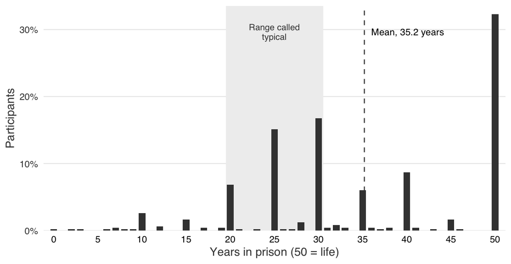

```r
# === FIGURE 1: HOW MANY PARTICIPANTS CHOSE EACH SENTENCE IN STUDY 1 (HISTOGRAM) ===
# WHAT THIS CHUNK DOES: draws the share of Study 1's 496 participants who chose
# each sentence, 0 to 50 years in whole years, built exactly like fig17 (Study
# 2's first sentences): the 20-to-30-year range the instructions called typical
# shaded, a dashed line at the mean, and the three vignettes together (no
# vignette split). It replaces the earlier violins, one per vignette.
# PREREG: descriptive; no test, no punitiveness score.
# CONSUMES: s1 (section 1); s1r, Study 1's row of the sentence summary, which
#           section 6 checked against Study 1's manuscript (t against 25 years,
#           d, the share at 50 years, the share on the six most common values).
yrs1 <- s1$Sentence_1
stopifnot(!anyNA(yrs1), length(yrs1) == 496, all(yrs1 == round(yrs1)),
          all(yrs1 >= 0 & yrs1 <= 50))
# GUARD: the vignette means and sizes against Study 1's exported table, so the
# sentences drawn are the ones Study 1 analysed.
s1_vig <- read.csv(file.path(S1_ROOT, "output", "tables", "sentence_by_vignette.csv"))
stopifnot(all(as.numeric(table(s1$vignette)) == s1_vig$n),
          all(abs(round(tapply(s1$Sentence_1, s1$vignette, mean), 2) - s1_vig$mean) < 1e-9))
hist1 <- data.frame(years = 0:50,
                    pct = vapply(0:50, function(y) 100 * mean(yrs1 == y), numeric(1)))
# GUARDS: the shares sum to 100%; the share at 50 years and the mean are
# section 6's (checked there against the manuscript's 32.3% and its t test).
stopifnot(isTRUE(all.equal(sum(hist1$pct), 100)),
          isTRUE(all.equal(hist1$pct[hist1$years == 50] / 100, s1r$share_at_50)),
          isTRUE(all.equal(mean(yrs1), s1r$mean)))
# The two text labels sit just below the tallest bar (the 50-year bar), level
# with each other, as in fig17.
LAB_Y1 <- 0.92 * max(hist1$pct)
fig1 <- ggplot(hist1, aes(x = years, y = pct)) +
  annotate("rect", xmin = 19.5, xmax = 30.5, ymin = -Inf, ymax = Inf, fill = BAND, colour = NA) +
  geom_col(width = 0.75, fill = S2_FILL) +
  geom_vline(xintercept = s1r$mean, linetype = "dashed", colour = INK2, linewidth = 0.4) +
  annotate("text", x = s1r$mean + 0.8, y = LAB_Y1, hjust = 0, size = 2.7, colour = INK,
           label = sprintf("Mean, %.1f years", s1r$mean)) +
  annotate("text", x = 25, y = LAB_Y1, size = 2.5, colour = INK2, lineheight = 0.9,
           label = "Range called\ntypical") +
  scale_x_continuous(breaks = seq(0, 50, 5), expand = expansion(add = 0.8)) +
  scale_y_continuous(breaks = seq(0, 40, 10), labels = function(x) paste0(x, "%"),
                     expand = expansion(mult = c(0, 0.04))) +
  labs(x = "Years in prison (50 = life)", y = "Participants") +
  theme_vbar()
save_fig(fig1, "fig1_study1_sentences", 3.0)
fig1
```

```r
# === THE CORRELATION-MATRIX FIGURES (fig2 AND fig4): SHARED DRAWING FUNCTION ===
# WHAT THIS CHUNK DOES: defines corr_matrix_fig(), which draws the correlations
# among a set of Study 1 measures as a triangle of gray cells, each with its r
# printed in it.
# DESIGN. Only the cells below the diagonal are drawn: the matrix is symmetric,
# so the upper triangle would repeat them, and the diagonal is 1 by definition.
# Punitiveness is the first measure, so the first column is every measure's
# correlation with punitiveness, the quantity the paper's H1 and H2 are about.
# The shade runs from a very light gray (r = 0, still visible against the white
# page) to near black (r = 1): one ramp, because every correlation here is
# positive (guarded below; a negative r would need a second ramp, and the knit
# stops rather than draw it misleadingly). The number in each cell carries the
# exact value, so the figure has no colour key. Each number is printed in
# white or black, whichever contrasts more with its own cell; the guard below
# confirms every number keeps a contrast of at least 4.5 to 1 (the WCAG level
# for normal text).
# CONSUMES: s1 with punit_six (section 3.0); theme_paper(), INK (figure_style).
MAT_LOW <- "#f0f0f0"; MAT_HIGH <- "#1a1a1a"
# Relative luminance of a gray (WCAG 2 definition), for the text contrast.
gray_lum <- function(hex) {
  v <- grDevices::col2rgb(hex)[1, ] / 255
  ifelse(v <= 0.03928, v / 12.92, ((v + 0.055) / 1.055)^2.4)
}
corr_matrix_fig <- function(vars, labels, text_size, x_angle = 0, wrap = 12) {
  stopifnot(length(vars) == length(labels), all(vars %in% names(s1)), !anyNA(s1[, vars]))
  R <- cor(s1[, vars])
  k <- length(vars)
  cells <- expand.grid(i = seq_len(k), j = seq_len(k))
  cells <- cells[cells$i > cells$j, ]          # below the diagonal: row i, column j
  cells$r <- R[cbind(cells$i, cells$j)]
  # GUARD: every correlation drawn is positive, so the one-ramp shading is
  # honest (see DESIGN above).
  stopifnot(all(cells$r > 0))
  # The gray each cell will be drawn in: the same palette scale_fill_gradient()
  # uses below (interpolated in Lab space between the two ends; with limits 0
  # to 1, r needs no rescaling). The text takes whichever of white and black
  # contrasts more with that gray. GUARD: at least 4.5 to 1 in every cell.
  lum <- gray_lum(scales::seq_gradient_pal(MAT_LOW, MAT_HIGH, "Lab")(cells$r))
  c_white <- 1.05 / (lum + 0.05); c_black <- (lum + 0.05) / 0.05
  cells$white_text <- c_white > c_black
  stopifnot(all(pmax(c_white, c_black) >= 4.5))
  # Rows run top to bottom in the measures' order, columns left to right.
  cells$row <- factor(labels[cells$i], levels = rev(labels))
  cells$col <- factor(labels[cells$j], levels = labels)
  cells$lab <- sub("^0\\.", ".", sprintf("%.2f", cells$r))
  x_lab <- if (x_angle == 0) function(x) vapply(x, function(s)
    paste(strwrap(s, width = wrap), collapse = "\n"), character(1)) else waiver()
  p <- ggplot(cells, aes(x = col, y = row, fill = r)) +
    geom_tile(colour = "white", linewidth = 0.6) +
    geom_text(aes(label = lab, colour = white_text), size = text_size,
              show.legend = FALSE) +
    scale_fill_gradient(low = MAT_LOW, high = MAT_HIGH, limits = c(0, 1), guide = "none") +
    scale_colour_manual(values = c(`TRUE` = "white", `FALSE` = INK), guide = "none") +
    scale_x_discrete(labels = x_lab, drop = TRUE) +
    scale_y_discrete(drop = TRUE) +
    coord_fixed(clip = "off") +
    labs(x = NULL, y = NULL) +
    theme_paper() +
    theme(panel.grid = element_blank(),
          axis.text.y = element_text(colour = INK, hjust = 1),
          axis.text.x = if (x_angle == 0) element_text(colour = INK, lineheight = 0.9) else
            element_text(colour = INK, angle = x_angle, hjust = 1, vjust = 1))
  list(plot = p, R = R)
}
```

## Figure 2: correlations among punitiveness and the clusters in Study 1

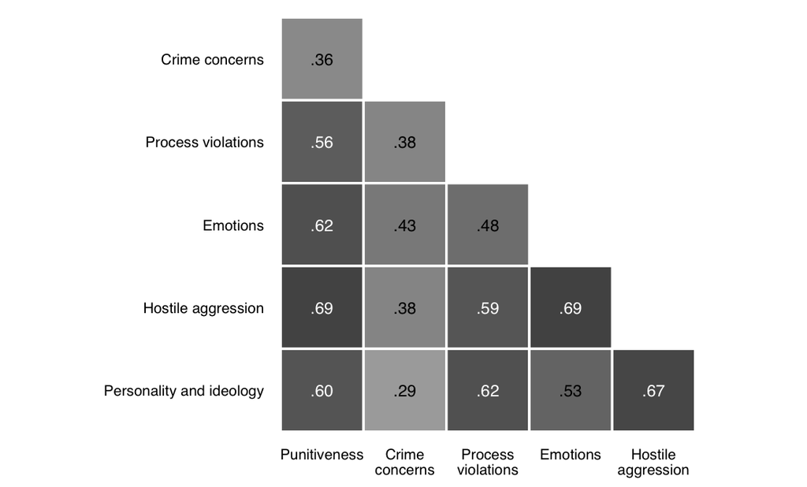

```r
# === FIGURE 2: PUNITIVENESS AND THE FIVE CLUSTERS, STUDY 1 (CORRELATION MATRIX) ===
# WHAT THIS CHUNK DOES: draws the correlations among punitiveness (the six
# components) and Study 1's five clusters, in Study 1's order, with the full
# label "Personality and ideology" and no title inside the image. It replaces
# Study 1's colour heatmap (its 01_main_analysis.Rmd, section 6.1d), which was
# drawn on the published index.
# PREREG: NOT REGISTERED (the paper's scoring; see section 3.0). Only the
#         punitiveness column differs from Study 1's figure; the correlations
#         among the clusters do not involve punitiveness.
# CONSUMES: corr_matrix_fig() (above); t1 (section 3c.1).
F2_VARS <- c(punit_six = "Punitiveness", crime_concerns_agg = "Crime concerns",
             process_agg = "Process violations", emotions_agg = "Emotions",
             hostile_agg = "Hostile aggression", personality_agg = "Personality and ideology")
f2 <- corr_matrix_fig(names(F2_VARS), unname(F2_VARS), text_size = 3.0, wrap = 12)
# GUARD: the punitiveness column is Table 1's cluster column (section 3c.1).
stopifnot(isTRUE(all.equal(unname(f2$R["punit_six", -1]),
                           t1$r[match(names(F2_VARS)[-1], t1$variable)])))
fig2 <- f2$plot
save_fig(fig2, "fig2_study1_cluster_matrix", 3.5)
fig2
```

## Figure 4: correlations among punitiveness and the eighteen correlates in Study 1

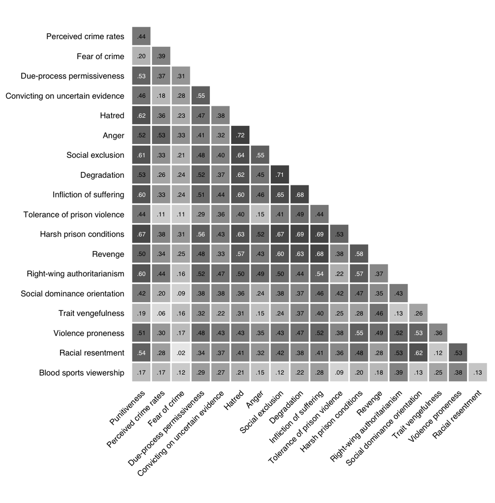

```r
# === FIGURE 4: PUNITIVENESS AND THE EIGHTEEN CORRELATES, STUDY 1 (CORRELATION
# MATRIX) ===
# WHAT THIS CHUNK DOES: draws the correlations among punitiveness (the six
# components) and Study 1's eighteen correlates, in Study 1's order (grouped by
# cluster: crime concerns, process violations, emotions, hostile aggression,
# personality and ideology), with the paper's labels and no title inside the
# image. It replaces Study 1's colour heatmap, drawn on the published index.
# PREREG: NOT REGISTERED (the paper's scoring). Only the punitiveness column
#         differs from Study 1's figure.
# CONSUMES: corr_matrix_fig() (above); S1P_CORRELATES and t1 (section 3c.1).
F4_VARS <- c(punit_six = "Punitiveness", S1P_CORRELATES)
f4 <- corr_matrix_fig(names(F4_VARS), unname(F4_VARS), text_size = 1.85, x_angle = 45)
# GUARD: the punitiveness column is Table 1's last column (section 3c.1).
stopifnot(isTRUE(all.equal(unname(f4$R["punit_six", -1]),
                           t1$r[match(names(S1P_CORRELATES), t1$variable)])))
fig4 <- f4$plot + theme(axis.text = element_text(size = 6.8))
save_fig(fig4, "fig4_study1_construct_matrix", 5.9)
fig4
```

## Figure 3 (output folder only): Study 1’s hostility advantage at three levels of strictness

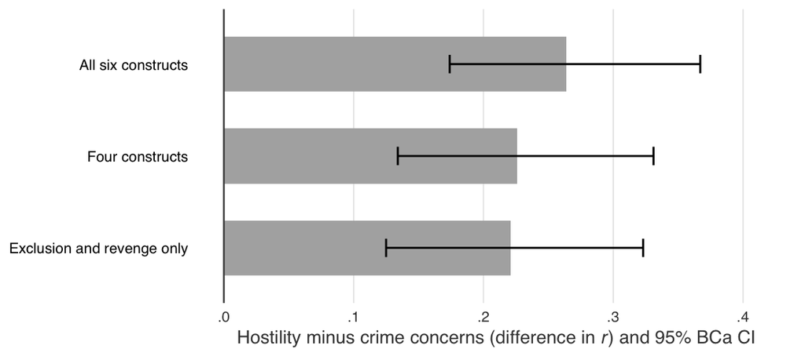

```r
# === FIGURE 3: STUDY 1'S SENSITIVITY ANALYSIS (BAR CHART), NOT A PAPER FIGURE ===
# NO LONGER IN THE PAPER (27 September 2026): it is drawn to this document's
# output folder only (save_fig(paper = FALSE)) and is not copied to the
# manuscript's folders. It shows Study 1's PUBLISHED index, as Study 1's own
# analysis exported it; the six-component values are in S1P_tableS1_strictness
# (section 3c.2).
# The difference between punitiveness's correlation with hostile aggression and
# with crime concerns at each of Study 1's three levels, with the 95% BCa
# bootstrap intervals exactly as Study 1's own analysis exported them
# (tautology_bootstrap_cis.csv; 10,000 resamples). Nothing is re-estimated here.
s1_boot <- read.csv(file.path(S1_ROOT, "output", "tables", "supplementary",
                              "tautology_bootstrap_cis.csv"))
stopifnot(nrow(s1_boot) == 3, grepl("^Original", s1_boot$Level[1]),
          grepl("^Conservative", s1_boot$Level[2]), grepl("^Strictest", s1_boot$Level[3]))
# GUARD: the exported differences must be the ones this document computes from
# Study 1's data on the published index (section 3C), at the three decimals the
# export prints.
stopifnot(all(abs(round(s1_ladder_old$diff, 3) - s1_boot$Observed_Diff) < 1e-9))
f3 <- data.frame(row = factor(LEVELS, levels = rev(LEVELS)),
                 diff = s1_boot$Observed_Diff,
                 lower = s1_boot$BCa_Lower, upper = s1_boot$BCa_Upper)
fig3 <- ggplot(f3, aes(x = diff, y = row)) +
  geom_col(width = 0.6, fill = S1_FILL) +
  geom_errorbar(aes(xmin = lower, xmax = upper), width = 0.2, orientation = "y",
                linewidth = 0.5, colour = INK) +
  geom_vline(xintercept = 0, colour = INK2, linewidth = 0.4) +
  scale_x_continuous(breaks = seq(0, 0.4, 0.1), labels = axis_r) +
  coord_cartesian(xlim = c(0, 0.42)) +
  labs(x = expression(paste("Hostility minus crime concerns (difference in ",
                            italic(r), ") and 95% BCa CI")), y = NULL) +
  theme_hbar()
save_fig(fig3, "fig3_study1_sensitivity", 2.6, paper = FALSE)
fig3
```

## Figure 5: the sentencing decisions in both studies

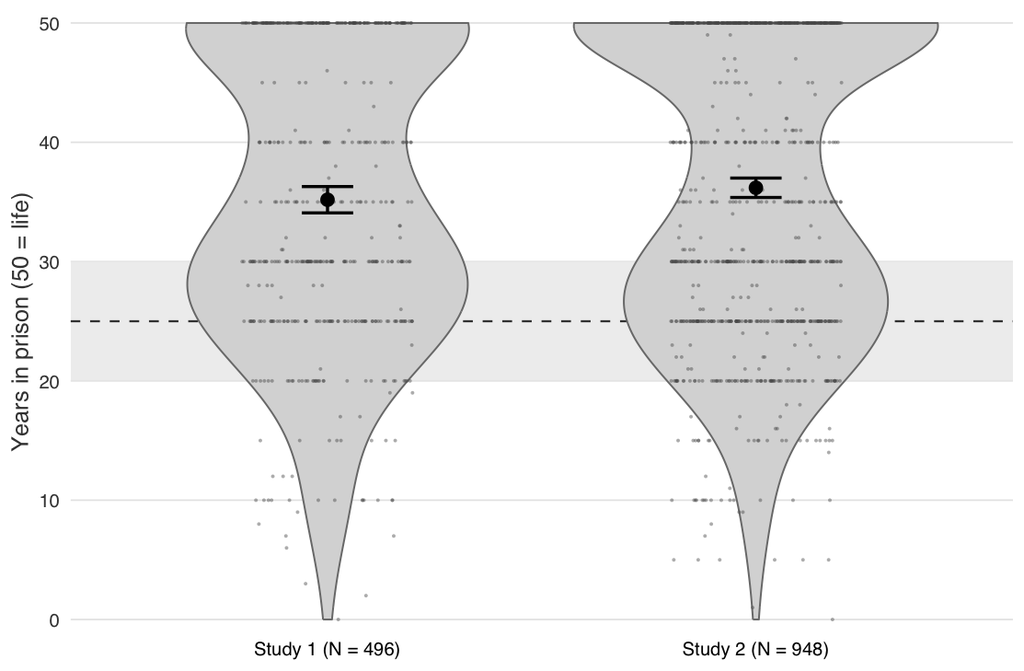

```r
# === FIGURE 5: SENTENCES, BOTH STUDIES (VIOLIN PLOT WITH JITTER) ===
# One violin per study, same scale, same reference band. Every point is one
# participant.
f5_long <- data.frame(group = factor(sent$study, levels = c(S1_NAME, S2_NAME)),
                      years = sent$years)
f5_stats <- do.call(rbind, lapply(c(S1_NAME, S2_NAME), function(g)
  cbind(group = g, mean_ci(f5_long$years[f5_long$group == g]))))
f5_stats$group <- factor(f5_stats$group, levels = c(S1_NAME, S2_NAME))
# GUARD: the means drawn are the means section 6 checked against both records.
stopifnot(isTRUE(all.equal(f5_stats$mean, sent_summary$mean[match(c(S1_NAME, S2_NAME),
                                                                  sent_summary$study)])))
fig5 <- violin_sentences(f5_long, f5_stats)
save_fig(fig5, "fig5_sentences_both_studies", 3.8)
fig5
```

## Figure 6: punitiveness and its correlates in both studies

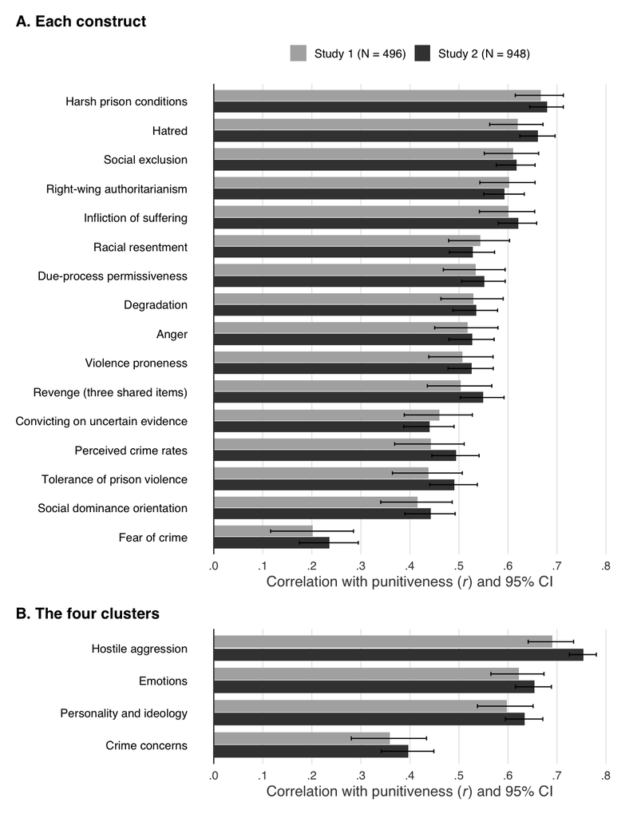

```r
# === FIGURE 6: THE CORRELATES AND THE CLUSTERS, BOTH STUDIES (BAR CHART) ===
# WHAT THIS CHUNK DOES: Panel A: every construct both studies fielded, each
# study's correlation with punitiveness (the six components, in both studies)
# and its 95% interval. Panel B: the four clusters.
# PREREG: NOT REGISTERED (the paper's scoring; cross-study comparisons were
#         never registered).
# CONSUMES: two_con, two_clu (section 5); s1_con, s1_clu (section 3); STUDY_FILL,
#           theme_hbar(), lab_r, axis_r (figure style).
# GUARD: the row order factors cover every row (no construct or cluster lost).
# Rows are ORDERED BY STUDY 1 (its correlations on the six components, largest
# at the top), so a reader can see directly whether Study 2 keeps that order.
# Panel B shows Study 1's thirty-item
# personality cluster; the twenty-one-item version is in two_study_clusters.csv.
# position_dodge() places the FIRST level lowest; ordering the studies Study 2
# then Study 1 puts Study 1's bar on top in every row, as the legend reads.
bar_panel <- function(df, key, title) {
  df$study <- factor(df$study, levels = c(S2_NAME, S1_NAME))
  dodge <- position_dodge(width = 0.8)
  ggplot(df, aes(x = r, y = .data[[key]], fill = study)) +
    geom_col(width = 0.76, position = dodge) +
    geom_errorbar(aes(xmin = ci_lower, xmax = ci_upper), width = 0.25,
                  orientation = "y", linewidth = 0.35, colour = INK, position = dodge) +
    geom_vline(xintercept = 0, colour = INK2, linewidth = 0.4) +
    scale_fill_manual(values = STUDY_FILL, breaks = c(S1_NAME, S2_NAME)) +
    scale_x_continuous(breaks = seq(0, 0.8, 0.1), labels = axis_r) +
    coord_cartesian(xlim = c(0, 0.8)) +
    labs(x = lab_r, y = NULL, title = title) +
    theme_hbar()
}
# Study 1's order is the order of ITS correlations on the six components,
# largest at the top (the published order was on the published index, and a
# few adjacent rows swap places under the six components, e.g. hatred and
# social exclusion). order() puts the smallest first, which ggplot draws at the
# bottom.
two_con$construct <- factor(two_con$construct,
                            levels = s1_con$construct[order(s1_con$r)])
two_clu$cluster <- factor(two_clu$cluster, levels = s1_clu$cluster[order(s1_clu$r)])
stopifnot(!anyNA(two_con$construct), !anyNA(two_clu$cluster))
fig6 <- bar_panel(two_con, "construct", "A. Each construct") /
  (bar_panel(two_clu, "cluster", "B. The four clusters") +
     theme(legend.position = "none")) +
  plot_layout(heights = c(16, 4.6))
save_fig(fig6, "fig6_correlates_both_studies", 7.4)
fig6
```

## Figure 7: the hostility advantage in both studies

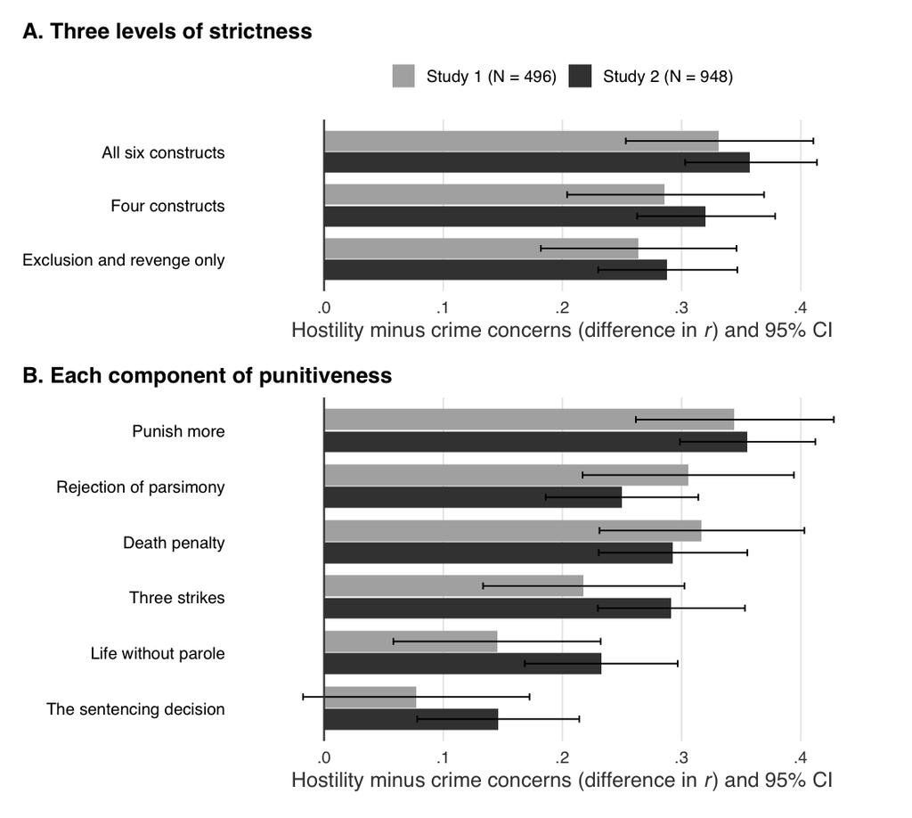

```r
# === FIGURE 7: HOW MUCH MORE CLOSELY PUNITIVENESS TRACKS HOSTILITY (BAR CHART) ===
# PREREG: NOT REGISTERED as scored (see below). CONSUMES: two_adv (section 5),
# LEVELS and PARTS (section 3), whose values sections 3 and 4 guarded.
# WHAT THIS CHUNK DOES: the difference between the two correlations (hostile aggression minus crime
# concerns) with its 95% interval. Panel A: the three levels of the sensitivity
# analysis. Panel B: the all-six-construct comparison on each part of
# punitiveness separately. Panel A's punitiveness is the six components in both
# studies (NOT REGISTERED); Panel B's rows are single parts, so no weighting
# enters. INTERVALS are Zou's (2007), computed identically in both studies.
# Study 1's Table S1 reports BCa bootstrap intervals for the three levels
# (S1P_tableS1_strictness, section 3c.2); those are close to these but are not
# the same interval.
adv_panel <- function(df, title) {
  df$study <- factor(df$study, levels = c(S2_NAME, S1_NAME))
  dodge <- position_dodge(width = 0.8)
  ggplot(df, aes(x = diff, y = row, fill = study)) +
    geom_col(width = 0.76, position = dodge) +
    geom_errorbar(aes(xmin = diff_lower, xmax = diff_upper), width = 0.25,
                  orientation = "y", linewidth = 0.35, colour = INK, position = dodge) +
    geom_vline(xintercept = 0, colour = INK2, linewidth = 0.4) +
    scale_fill_manual(values = STUDY_FILL, breaks = c(S1_NAME, S2_NAME)) +
    scale_x_continuous(breaks = seq(0, 0.4, 0.1), labels = axis_r) +
    coord_cartesian(xlim = c(-0.05, 0.45)) +
    labs(x = lab_dr, y = NULL, title = title) +
    theme_hbar()
}
lev_df  <- two_adv[two_adv$panel == "levels", ]
lev_df$row <- factor(lev_df$row, levels = rev(LEVELS))
part_df <- two_adv[two_adv$panel == "parts", ]
part_df$row <- factor(part_df$row, levels = rev(unname(PARTS)))
fig7 <- adv_panel(lev_df, "A. Three levels of strictness") /
  (adv_panel(part_df, "B. Each component of punitiveness") +
     theme(legend.position = "none")) +
  plot_layout(heights = c(3, 6))
save_fig(fig7, "fig7_hostility_advantage_both_studies", 5.2)
fig7
```

# 8. Study 2’s own figures (Results, Part 2)

These six figures show Study 2 alone, for Part 2 of its Results (“What people mean by retribution”). They use the same grayscale style as the figures above and the same checks: every number that also exists in `01_main_analysis.Rmd`’s exports is compared with it, and the knit stops if any disagrees.

```r
# === SHARED PIECES FOR THE STUDY 2 FIGURES ===
# fmt_r prints a correlation without the leading zero and with a true minus
# sign; a correlation smaller than .01 in size gets three decimals (.007), since
# two would misstate it as .00 or .01.
fmt_r <- function(x) {
  dg <- ifelse(abs(x) < 0.01, 3, 2)
  s <- vapply(seq_along(x), function(i) formatC(x[i], format = "f", digits = dg[i]),
              character(1))
  sub("^-", "−", sub("^(-?)0\\.", "\\1.", s))
}
# A Pearson correlation with its Fisher-z 95% interval, as cor.test() gives it.
cor_ci2 <- function(x, y) {
  tt <- cor.test(x, y)
  data.frame(r = unname(tt$estimate), lower = tt$conf.int[1], upper = tt$conf.int[2])
}
# GUARD: two numbers must agree to within a tolerance, or the knit stops and
# names the check that failed.
same <- function(a, b, what, tol = 1e-8) {
  if (!isTRUE(all.equal(as.numeric(a), as.numeric(b), tolerance = tol)))
    stop("Guard failed: ", what)
  invisible(TRUE)
}
# Four evenly spaced grays for stacked bars, darkest first (validated as an
# ordered ramp: each step visibly darker than the next, the lightest still
# distinct from the white page).
RAMP4 <- c("#1a1a1a", "#4f4f4f", "#808080", "#b0b0b0")
# Horizontal bars with a 95% interval and the value printed past the interval.
# `fill` names the column that sets each bar's gray; dodge > 0 puts two bars in
# each row. position_dodge() places the first factor level lowest, so callers
# order the levels to put the series named first in the legend on top.
bars_r <- function(df, y, fill, fills, xlim, xbreaks, xlab, dodge = 0,
                   legend_breaks = names(fills)) {
  pos <- if (dodge > 0) position_dodge(width = dodge) else position_identity()
  ggplot(df, aes(x = r, y = .data[[y]], fill = .data[[fill]])) +
    geom_col(width = if (dodge > 0) dodge * 0.95 else 0.65, position = pos) +
    geom_errorbar(aes(xmin = lower, xmax = upper), width = 0.25, orientation = "y",
                  linewidth = 0.35, colour = INK, position = pos) +
    geom_text(aes(x = pmax(upper, 0) + 0.012, label = fmt_r(r)), hjust = 0,
              size = 2.6, colour = INK, position = pos, show.legend = FALSE) +
    geom_vline(xintercept = 0, colour = INK2, linewidth = 0.4) +
    scale_fill_manual(values = fills, breaks = legend_breaks) +
    scale_x_continuous(breaks = xbreaks, labels = axis_r) +
    coord_cartesian(xlim = xlim, clip = "off") +
    labs(x = xlab, y = NULL) +
    theme_hbar()
}
# Violins of 1-to-7 scores: the shape of everyone's answers, each participant as
# a point jittered sideways only (so it stays at its score; the seed fixes the
# jitter), and the mean with its 95% interval in black. The dashed line is the
# neutral midpoint.
violins_1to7 <- function(long, stats, levels) {
  long$measure <- factor(long$measure, levels = levels)
  stats$measure <- factor(stats$measure, levels = levels)
  ggplot(long, aes(x = measure, y = score)) +
    geom_hline(yintercept = 4, linetype = "dashed", colour = INK2, linewidth = 0.4) +
    geom_violin(fill = VIOLIN, colour = "#7a7a7a", linewidth = 0.35, width = 0.85,
                scale = "width", adjust = 1.2, trim = TRUE) +
    geom_point(position = position_jitter(width = 0.2, height = 0, seed = 1),
               size = 0.6, alpha = 0.35, colour = POINTS, stroke = 0) +
    geom_errorbar(data = stats, aes(x = measure, ymin = lower, ymax = upper),
                  inherit.aes = FALSE, width = 0.12, linewidth = 0.6, colour = INK) +
    geom_point(data = stats, aes(x = measure, y = mean), inherit.aes = FALSE,
               size = 2.2, colour = INK) +
    scale_y_continuous(breaks = 1:7, limits = c(1, 7),
                       labels = c("1 Strongly\ndisagree", "2", "3", "4 Neutral", "5",
                                  "6", "7 Strongly\nagree")) +
    labs(x = NULL, y = NULL) +
    theme_vbar() + theme(axis.text.y = element_text(size = 7.5, lineheight = 0.9))
}
```

## The paper’s scorings of Study 2

```r
# === THE PAPER'S SCORINGS OF STUDY 2 ===
# WHAT THIS CHUNK DOES: builds s2p, a copy of the scored data with the paper's
# scores added, each built exactly as section 9.19 of 01_main_analysis.Rmd
# builds it and checked against what 9.19 exported. fig10 to fig13, fig15 and
# fig18 read from s2p; every other figure reads s2 and is unchanged.
#
# THE PAPER'S SCORINGS (none registered; the Method lists them, and the
# Supplement lists each as a departure), as settled on 27 September 2026:
#   desert_theory       "desert theory": the mean of Retribution_1 to _5, the
#                       five retribution items (alpha .913, M 5.60). The
#                       registered desert score is items 1 to 4.
#   just_deserts_paper  the paper's "just deserts": the plain mean of desert
#                       theory and the proportionality principle item (both 1
#                       to 7, so the mean stays on the 1-to-7 scale and can be
#                       compared with revenge's mean). The registered
#                       composite, s2$just_deserts, is "just deserts
#                       (registered)" and stays in s2p unchanged.
#   punit_parts6        punitiveness, the six components weighted equally
#                       (s2$punit_six, section 4.0), under the variable name
#                       01's contrast exports use for it.
#   punit_parts5z       punitiveness, the five attitude components each
#                       standardized (s2$punit_five_z), used wherever the
#                       sentence or the sentencing ratio is on the other side.
# Revenge (four items) and the hostile aggression cluster are used as
# registered, so s2p carries them unchanged from s2.
PAPER_NEEDED <- c("PAPER_reliability", "PAPER_H6", "PAPER_H6_cors", "PAPER_H9",
                  "PAPER_H10_cors", "PAPER_goals_by_limits", "PAPER_ratio_cors",
                  "PAPER_ratio_continuous", "PAPER_contrasts_rank",
                  "PAPER_contrasts_vs_deter_incap", "PAPER_H1",
                  "PAPER_H12_shares_vs_deter_incap", "PAPER_person_scores",
                  "PAPER_JD_parts", "PAPER_JD_H9", "PAPER_JD_H10_cors")
PAPER_MISSING <- PAPER_NEEDED[!file.exists(file.path(S2_TABLES,
                                                     paste0(PAPER_NEEDED, ".csv")))]
if (length(PAPER_MISSING)) stop("Knit 01_main_analysis.Rmd first (the PAPER_ files ",
                                "come from its section 9.19). Missing: ",
                                paste(PAPER_MISSING, collapse = ", "))

# Every item was required, so no row is missing an item; checked here because
# a missing item would silently turn a row mean into a mean of fewer items.
RET_ITEMS <- paste0("Retribution_", 1:5)
stopifnot(!anyNA(s2[, RET_ITEMS]), !anyNA(s2$proportionality_principle),
          all(s2$proportionality_principle %in% 1:7))
s2p <- s2
s2p$desert_theory      <- rowMeans(s2[, RET_ITEMS])
s2p$just_deserts_paper <- (s2p$desert_theory + s2$proportionality_principle) / 2
s2p$punit_parts6       <- s2$punit_six
s2p$punit_parts5z      <- s2$punit_five_z

# GUARDS against section 9.19's exports:
#   desert theory's mean and SD (PAPER_reliability's "Desert theory (paper)"
#   row) and its value for every participant (PAPER_person_scores);
#   the paper's just deserts for every participant (PAPER_person_scores) and
#   its mean (PAPER_JD_parts, whole sample: 5.66);
#   the six-component score's mean and SD (PAPER_reliability); and
#   the retributivists' and the other participants' means on the hostile
#   aggression cluster (PAPER_contrasts_rank), which confirm that 9.19 used the
#   registered cluster that s2 carries.
prel <- read_s2("PAPER_reliability")
p_ret <- prel[grepl("^Desert theory \\(paper\\)", prel$score), ]
p_six <- prel[grepl("^Punitiveness \\(six components\\)", prel$score), ]
stopifnot(nrow(p_ret) == 1, nrow(p_six) == 1, p_ret$k == 5, p_six$k == 6)
same(mean(s2p$desert_theory), p_ret$M, "desert theory, mean")
same(sd(s2p$desert_theory), p_ret$SD, "desert theory, SD")
same(s2p$desert_theory, ps2$desert_theory, "desert theory, every participant")
same(s2p$just_deserts_paper, ps2$just_deserts, "just deserts (paper), every participant")
pjd <- read_s2("PAPER_JD_parts")
pjd_all <- pjd[pjd$sample == "Whole sample", ]
stopifnot(nrow(pjd_all) == 1)
same(mean(s2p$just_deserts_paper), pjd_all$M_just_deserts, "just deserts (paper), mean")
same(mean(s2p$punit_parts6), p_six$M, "six components, mean", tol = 1e-6)
same(sd(s2p$punit_parts6), p_six$SD, "six components, SD")
pcr <- read_s2("PAPER_contrasts_rank")
p_hag <- pcr[pcr$outcome == "Hostile-aggression cluster (z)", ]
stopifnot(nrow(p_hag) == 1, p_hag$variable == "hostile_agg")
RET_P <- s2$grp_rank == "Retributivist"
stopifnot(!anyNA(RET_P), sum(RET_P) == 371)
same(mean(s2p$hostile_agg[RET_P]), p_hag$M1, "cluster, retributivists")
same(mean(s2p$hostile_agg[!RET_P]), p_hag$M2, "cluster, the others")
cat(sprintf(paste("Desert theory M = %.2f; just deserts (paper) M = %.2f;",
                  "revenge (four items) M = %.2f.\n"),
            mean(s2p$desert_theory), mean(s2p$just_deserts_paper), mean(s2p$revenge)))
```

```
## Desert theory M = 5.60; just deserts (paper) M = 5.66; revenge (four items) M = 4.14.
```

## Figure 17: the first sentence in Study 2

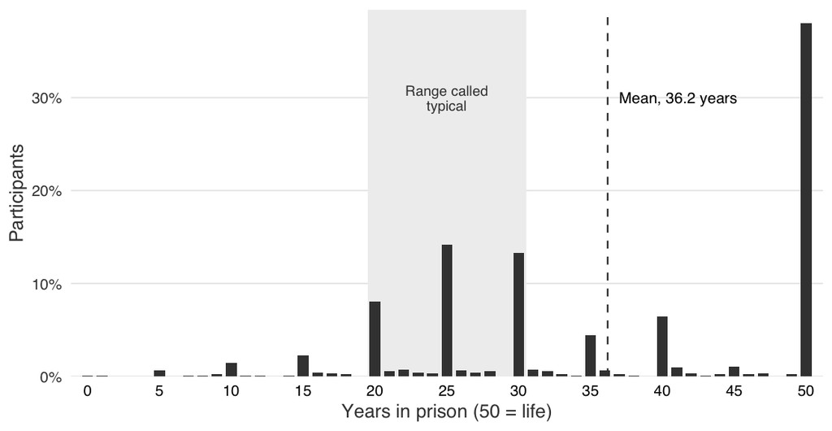

```r
# === FIGURE 17: HOW MANY PARTICIPANTS CHOSE EACH SENTENCE IN STUDY 2 ===
# WHAT THIS CHUNK DOES: draws the share of the 948 participants who chose each
# first sentence, 0 to 50 years in whole years, with the 20-to-30-year range
# the instructions called typical shaded and the mean marked by a dashed line.
# It is the paper version of the talk slide s2_01 (no title inside the image;
# the caption in the manuscript is the title). The mean and the share at 50
# years are checked against the sentence summary of section 6 (s2r), which
# section 6 checked against 01_main_analysis.Rmd's exports.
yrs <- s2$Sentence1
stopifnot(!anyNA(yrs), length(yrs) == 948, all(yrs == round(yrs)), all(yrs >= 0 & yrs <= 50))
hist_df <- data.frame(years = 0:50,
                      pct = vapply(0:50, function(y) 100 * mean(yrs == y), numeric(1)))
same(sum(hist_df$pct), 100, "shares sum to 100%")
same(hist_df$pct[hist_df$years == 50] / 100, s2r$share_at_50, "share at 50 years")
same(mean(yrs), s2r$mean, "mean sentence")
fig17 <- ggplot(hist_df, aes(x = years, y = pct)) +
  annotate("rect", xmin = 19.5, xmax = 30.5, ymin = -Inf, ymax = Inf, fill = BAND, colour = NA) +
  geom_col(width = 0.75, fill = S2_FILL) +
  geom_vline(xintercept = s2r$mean, linetype = "dashed", colour = INK2, linewidth = 0.4) +
  annotate("text", x = s2r$mean + 0.8, y = 30, hjust = 0, size = 2.7, colour = INK,
           label = sprintf("Mean, %.1f years", s2r$mean)) +
  annotate("text", x = 25, y = 30, size = 2.5, colour = INK2, lineheight = 0.9,
           label = "Range called\ntypical") +
  scale_x_continuous(breaks = seq(0, 50, 5), expand = expansion(add = 0.8)) +
  scale_y_continuous(breaks = seq(0, 40, 10), labels = function(x) paste0(x, "%"),
                     expand = expansion(mult = c(0, 0.04))) +
  labs(x = "Years in prison (50 = life)", y = "Participants") +
  theme_vbar()
save_fig(fig17, "fig17_study2_sentences", 3.0)
fig17
```

## Figure 18: the twelve H1 correlations in Study 2

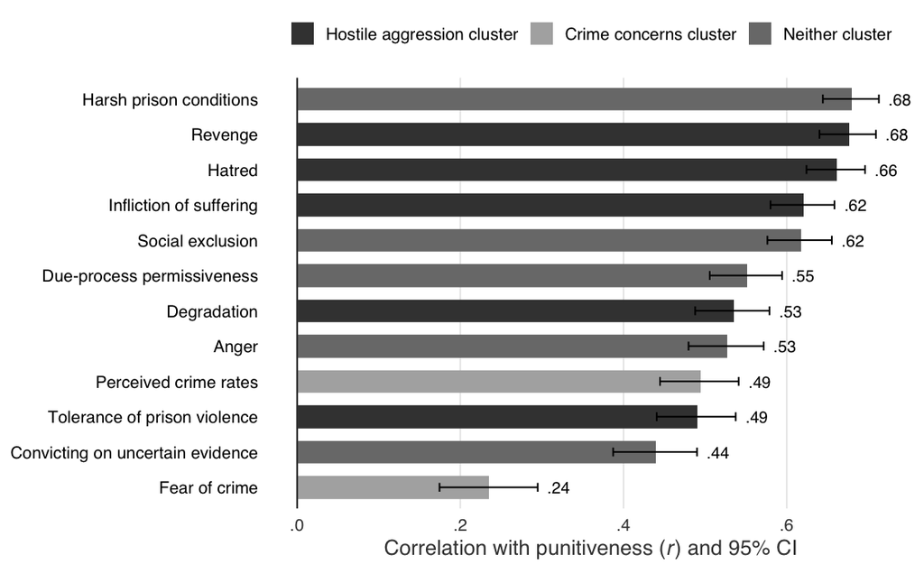

```r
# === FIGURE 18: EACH REGISTERED CORRELATE WITH PUNITIVENESS (H1) ===
# WHAT THIS CHUNK DOES: plots each of the twelve registered correlates'
# correlation with punitiveness, the six components, with its 95% interval, as
# 01_main_analysis.Rmd exported them (PAPER_H1, section 9.19B), shaded by the
# H2 cluster each correlate belongs to. It is the paper version of the talk
# slide s2_02, on the paper's punitiveness measure. Each correlation is
# recomputed from the scored data as a check.
# PREREG: H1 is registered on the eight-item scale (Supplement); this is the
#         same family on the paper's score, NOT REGISTERED.
ph1 <- read_s2("PAPER_H1")
H1_VARS <- c("Harsh prison conditions" = "harsh", "Hatred" = "hatred",
             "Social exclusion" = "exclusion", "Infliction of suffering" = "suffering",
             "Due-process permissiveness" = "dueprocess", "Revenge" = "revenge",
             "Degradation" = "degradation", "Anger" = "anger",
             "Perceived crime rates" = "crimerates",
             "Tolerance of prison violence" = "prisonviol",
             "Convicting on uncertain evidence" = "uncertain", "Fear of crime" = "fear")
stopifnot(setequal(ph1$y, names(H1_VARS)), nrow(ph1) == 12)
# The registered H2 clusters (prereg 2.1): hostile aggression has five members
# and crime concerns two; the other five correlates belong to neither.
H1_HOSTILE <- c("hatred", "revenge", "degradation", "suffering", "prisonviol")
H1_CRIME   <- c("crimerates", "fear")
f18 <- data.frame(measure = ph1$y, r = ph1$r, lower = ph1$ci_lower, upper = ph1$ci_upper,
                  stringsAsFactors = FALSE)
f18$var <- unname(H1_VARS[f18$measure])
for (i in seq_len(nrow(f18)))
  same(cor(s2p$punit_parts6, s2p[[f18$var[i]]]), f18$r[i], paste("r,", f18$measure[i]))
CL18 <- c("Hostile aggression cluster", "Crime concerns cluster", "Neither cluster")
f18$cluster <- ifelse(f18$var %in% H1_HOSTILE, CL18[1], ifelse(f18$var %in% H1_CRIME, CL18[2], CL18[3]))
f18$measure <- factor(f18$measure, levels = f18$measure[order(f18$r)])
fig18 <- bars_r(f18, "measure", "cluster",
                fills = setNames(c(S2_FILL, S1_FILL, "#7a7a7a"), CL18),
                xlim = c(0, 0.72), xbreaks = seq(0, 0.6, 0.2), xlab = lab_r,
                legend_breaks = CL18)
save_fig(fig18, "fig18_study2_correlates", 3.6)
fig18
```

## Figure 8: ranking the goals of punishment

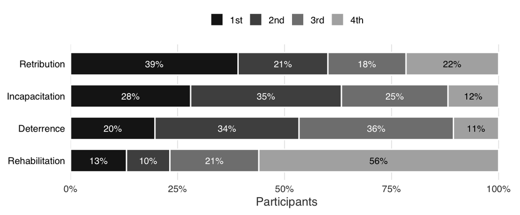

```r
# === FIGURE 8: RANKING THE FOUR GOALS ===
# WHAT THIS CHUNK DOES: draws the share of participants placing each goal 1st
# to 4th, from the exported rank matrix (goal_rank_matrix, registered). Since
# 27 September 2026 the figure is this ranking alone: the panel of the goal
# ratings (violins of each goal scale) was dropped, and the ratings are
# reported in the text and the Supplement. With one panel, the figure carries
# no panel letter or title inside the image.
# PREREG: the ranking is registered (prereg 5.5); descriptive, no test.
# CONSUMES: read_s2() (section 1); RAMP4, theme_hbar() (figure style).
rk <- read_s2("goal_rank_matrix")
rk$goal <- ifelse(grepl("retribution", rk$goal), "Retribution",
           ifelse(grepl("incapacitation", rk$goal), "Incapacitation",
           ifelse(grepl("deterrence", rk$goal), "Deterrence", "Rehabilitation")))
GOALS <- c("Retribution", "Incapacitation", "Deterrence", "Rehabilitation")
stopifnot(setequal(rk$goal, GOALS),
          all(rowSums(rk[, c("first", "second", "third", "fourth")]) == 948))
PLACES <- c(first = "1st", second = "2nd", third = "3rd", fourth = "4th")
rank_long <- do.call(rbind, lapply(names(PLACES), function(p)
  data.frame(goal = rk$goal, place = PLACES[[p]], pct = 100 * rk[[p]] / 948)))
rank_long$place <- factor(rank_long$place, levels = unname(PLACES))
rank_long$goal <- factor(rank_long$goal, levels = rev(GOALS))
f8a <- ggplot(rank_long, aes(x = pct, y = goal, fill = place)) +
  # reverse = TRUE puts 1st place at the left of each bar; group = place keeps
  # the labels in the same stacking order as the bars.
  geom_col(width = 0.7, colour = "white", linewidth = 0.5,
           position = position_stack(reverse = TRUE)) +
  geom_text(aes(label = sprintf("%.0f%%", pct), group = place,
                colour = place %in% c("1st", "2nd", "3rd")),
            position = position_stack(vjust = 0.5, reverse = TRUE), size = 2.6,
            show.legend = FALSE) +
  scale_colour_manual(values = c(`TRUE` = "white", `FALSE` = INK), guide = "none") +
  scale_fill_manual(values = setNames(RAMP4, unname(PLACES))) +
  scale_x_continuous(labels = function(x) paste0(x, "%"),
                     expand = expansion(mult = c(0, 0.01))) +
  labs(x = "Participants", y = NULL) +
  theme_hbar() +
  # A right margin wide enough for the "100%" tick label, which would otherwise
  # be cut at the image's edge.
  theme(plot.margin = margin(5.5, 14, 5.5, 5.5))
fig8 <- f8a
save_fig(fig8, "fig8_study2_goals", 2.4)
fig8
```

## Figure 9: proportionality and its departures

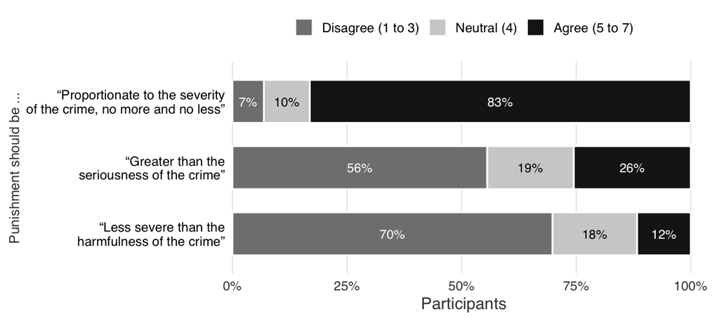

```r
# === FIGURE 9: DISAGREE / NEUTRAL / AGREE ON THE THREE ITEMS (H4, H5) ===
ITEMS <- c(proportionality = "“Proportionate to the severity\nof the crime, no more and no less”",
           severity_1 = "“Greater than the\nseriousness of the crime”",
           severity_2 = "“Less severe than the\nharmfulness of the crime”")
for (v in names(ITEMS)) stopifnot(!anyNA(s2[[v]]), all(s2[[v]] %in% 1:7))
h4 <- read_s2("H4_midpoint_tests"); h4s <- read_s2("H4_shares"); h5 <- read_s2("H5_paired")
same(mean(s2$proportionality), h4$mean[h4$variable == "proportionality"], "proportionality mean")
same(mean(s2$severity_1), h5$M1, "severity_1 mean"); same(mean(s2$severity_2), h5$M2, "severity_2 mean")
same(sum(s2$proportionality <= 4), h4s$k[3], "proportionality at or below 4")
same(sum(s2$severity_1 > 4), h4s$k[1], "severity_1 above 4")
ANS <- c("Disagree (1 to 3)", "Neutral (4)", "Agree (5 to 7)")
prop_long <- do.call(rbind, lapply(names(ITEMS), function(v) data.frame(
  item = ITEMS[[v]], answer = ANS,
  pct = 100 * c(mean(s2[[v]] < 4), mean(s2[[v]] == 4), mean(s2[[v]] > 4)))))
prop_long$item <- factor(prop_long$item, levels = rev(unname(ITEMS)))
prop_long$answer <- factor(prop_long$answer, levels = ANS)
fig9 <- ggplot(prop_long, aes(x = pct, y = item, fill = answer)) +
  geom_col(width = 0.65, colour = "white", linewidth = 0.5,
           position = position_stack(reverse = TRUE)) +
  geom_text(data = prop_long[prop_long$pct >= 5, ],
            aes(label = sprintf("%.0f%%", pct), group = answer,
                colour = answer != ANS[2]),
            position = position_stack(vjust = 0.5, reverse = TRUE), size = 2.6,
            show.legend = FALSE) +
  scale_colour_manual(values = c(`TRUE` = "white", `FALSE` = INK), guide = "none") +
  scale_fill_manual(values = setNames(c("#808080", "#d0d0d0", "#1a1a1a"), ANS)) +
  scale_x_continuous(labels = function(x) paste0(x, "%"),
                     expand = expansion(mult = c(0, 0.01))) +
  coord_cartesian(clip = "off") +
  labs(x = "Participants", y = "Punishment should be ...") +
  theme_hbar() + theme(axis.title.y = element_text(size = 8),
                       plot.margin = margin(5.5, 14, 5.5, 5.5))
save_fig(fig9, "fig9_study2_proportionality", 2.6)
fig9
```

## Figure 10: what desert theory goes with

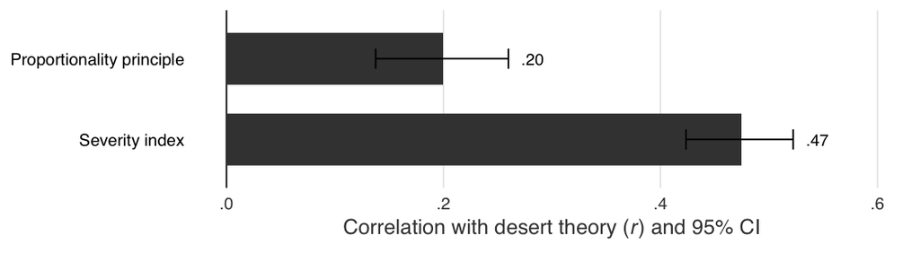

```r
# === FIGURE 10: DESERT THEORY WITH THE PROPORTIONALITY PRINCIPLE AND WITH THE
# SEVERITY INDEX (H6, ON THE PAPER'S SCORING) ===
# WHAT THIS CHUNK DOES: draws desert theory's correlation with the
# proportionality principle (.199) and with the severity index (.474), each
# with its 95% interval, as 01 exported them (PAPER_H6_cors, rows 1 and 2), and
# recomputes both from the scored data as a check. Since 27 September 2026 the
# figure shows these two bars only: the rows for the two single severity items
# and every punitiveness bar were dropped (punitiveness's correlations with the
# principle and the severity index, now on the six components, .038 and .588,
# are reported in the text from PAPER_H6).
# PREREG: H6 is registered on the registered desert score; this is the paper's
#         desert theory (Retribution_1 to _5), NOT REGISTERED as scored.
# CONSUMES: s2p (study2_paper_scorings); read_s2(), bars_r(), same().
h6c <- read_s2("PAPER_H6_cors"); h6s <- read_s2("PAPER_H6")
MEAS <- c("Proportionality principle", "Severity index")
MEAS_VAR <- c("proportionality_principle", "severity_index")
stopifnot(h6c$x[1] == "Desert theory", h6c$x[2] == "Desert theory",
          grepl("^Proportionality principle", h6c$y[1]), grepl("^Severity index", h6c$y[2]))
f10 <- data.frame(series = "Desert theory", measure = MEAS, r = h6c$r[1:2],
                  lower = h6c$ci_lower[1:2], upper = h6c$ci_upper[1:2])
same(f10$r, vapply(MEAS_VAR, function(v) cor(s2p$desert_theory, s2[[v]]), numeric(1)),
     "desert theory rows")
# GUARD: the two bars are the two correlations H6's test compares (PAPER_H6,
# desert theory row: r_jk with the severity index, r_jh with the principle).
p_dt <- h6s[h6s$pair == "Desert theory", ]
stopifnot(nrow(p_dt) == 1)
same(f10$r, c(p_dt$r_jh, p_dt$r_jk), "the two correlations H6 compares")
f10$measure <- factor(f10$measure, levels = rev(MEAS))
fig10 <- bars_r(f10, "measure", "series", fills = c(`Desert theory` = S2_FILL),
                xlim = c(0, 0.6), xbreaks = seq(0, 0.6, 0.2),
                xlab = expression(paste("Correlation with desert theory (", italic(r),
                                        ") and 95% CI"))) +
  theme(legend.position = "none")
save_fig(fig10, "fig10_study2_desert_direction", 1.6)
fig10
```

## Figure 11: each goal against each limit

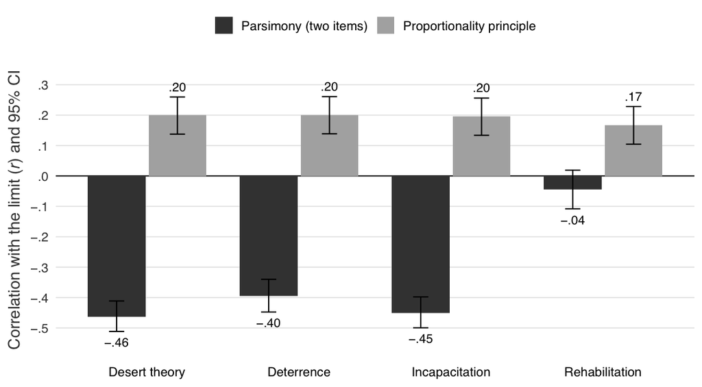

```r
# === FIGURE 11: GOALS AGAINST PARSIMONY AND AGAINST THE PROPORTIONALITY
# PRINCIPLE (PAPER_goals_by_limits, section 9.19) ===
# WHAT THIS CHUNK DOES: each goal's correlation with the two limits, with 95%
# intervals, read from 01's export; desert theory's correlation with the
# principle is recomputed from the scored data as a check (GUARD, below).
# CONSUMES: s2p (study2_paper_scorings); read_s2(), same(), fmt_r().
# Retribution is desert theory (the five retribution items; its label in the
# figure is "Desert theory"); the limit of proportionality is the principle
# item, the paper's measure of it. Parsimony is its two items, scored so that
# agreement means accepting the limit. NOT REGISTERED (the paper's scoring).
gl <- read_s2("PAPER_goals_by_limits")
stopifnot(nrow(gl) == 12, setequal(gl$x, c("Desert theory", "Deterrence",
                                           "Incapacitation", "Rehabilitation")))
LIM <- c("Parsimony (2 items)" = "Parsimony (two items)",
         "Proportionality principle item alone" = "Proportionality principle")
gl$goal <- gl$x
same(gl$r[gl$goal == "Desert theory" & gl$y == "Proportionality principle item alone"],
     cor(s2p$desert_theory, s2$proportionality_principle),
     "desert theory x proportionality principle (H6)")
g11 <- gl[gl$y %in% names(LIM), ]
g11$limit <- factor(LIM[g11$y], levels = unname(LIM))
g11$goal <- factor(g11$goal, levels = c("Desert theory", "Deterrence", "Incapacitation",
                                        "Rehabilitation"))
stopifnot(nrow(g11) == 8, !anyNA(g11$limit), !anyNA(g11$goal))
DG <- position_dodge(width = 0.8)
fig11 <- ggplot(g11, aes(x = goal, y = r, fill = limit)) +
  geom_hline(yintercept = 0, colour = INK2, linewidth = 0.4) +
  geom_col(width = 0.76, position = DG) +
  geom_errorbar(aes(ymin = ci_lower, ymax = ci_upper), width = 0.2, linewidth = 0.35,
                colour = INK, position = DG) +
  geom_text(aes(y = ifelse(r >= 0, ci_upper + 0.02, ci_lower - 0.02),
                vjust = ifelse(r >= 0, 0, 1), label = fmt_r(r)),
            position = DG, size = 2.6, colour = INK) +
  scale_fill_manual(values = setNames(c(S2_FILL, S1_FILL), unname(LIM))) +
  scale_y_continuous(breaks = seq(-0.5, 0.3, 0.1), labels = axis_r) +
  coord_cartesian(ylim = c(-0.56, 0.34), clip = "off") +
  labs(x = NULL, y = expression(paste("Correlation with the limit (", italic(r), ") and 95% CI"))) +
  theme_vbar()
save_fig(fig11, "fig11_study2_goals_limits", 3.2)
fig11
```

## Figure 12: desert theory, just deserts and revenge

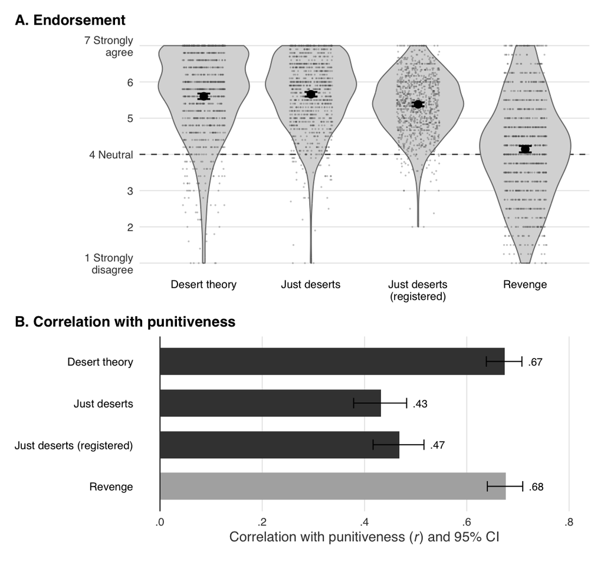

```r
# === FIGURE 12: ENDORSEMENT (A) AND CORRELATION WITH PUNITIVENESS (B) ===
# WHAT THIS CHUNK DOES: each panel shows four scores side by side, so the
# Supplement can set the registered H9 and H10 beside the paper's versions:
#   Desert theory              the five retribution items (paper);
#   Just deserts               the paper's just deserts: the mean of desert
#                              theory and the proportionality principle;
#   Just deserts (registered)  the registered composite (desert, items 1 to 4,
#                              with the registered proportionality component);
#   Revenge                    its four registered items.
# Panel A: each score's distribution, mean and 95% interval (1 to 7). Panel B:
# each score's correlation with punitiveness, the six components, for every
# row; the registered H10 test used the eight-item scale (H10_steiger), and the
# Supplement's text reports it there.
# PREREG: H9 and H10 are registered on the registered just-deserts score; the
#         desert-theory and paper just-deserts rows are NOT REGISTERED.
# CONSUMES: s2p (study2_paper_scorings); read_s2(), mean_ci(), cor_ci2(),
#           violins_1to7(), bars_r(), same().
ENDORSE <- c("Desert theory", "Just deserts", "Just deserts (registered)", "Revenge")
END_COL <- list(s2p$desert_theory, s2p$just_deserts_paper, s2$just_deserts, s2$revenge)
h9p <- read_s2("PAPER_H9"); h9 <- read_s2("H9_paired"); h9j <- read_s2("PAPER_JD_H9")
stopifnot(h9$var1[1] == "just_deserts", h9$var2[1] == "revenge", h9p$var2 == "revenge",
          h9j$comparison[1] == "Just deserts vs revenge", h9j$var2[1] == "revenge")
endorse <- do.call(rbind, lapply(seq_along(ENDORSE), function(i)
  cbind(measure = ENDORSE[i], mean_ci(END_COL[[i]]))))
# GUARDS: each mean is the one its H9 test compared. Desert theory and revenge
# against PAPER_H9; the paper's just deserts against PAPER_JD_H9 (5.66 against
# revenge's 4.14); the registered just deserts and revenge against the
# registered H9_paired.
same(endorse$mean[1], h9p$M1, "desert theory mean"); same(endorse$mean[4], h9p$M2, "revenge mean")
same(endorse$mean[2], h9j$M1[1], "just deserts (paper) mean")
same(endorse$mean[4], h9j$M2[1], "revenge mean, paper's just-deserts H9")
same(endorse$mean[3], h9$M1[1], "just deserts (registered) mean")
same(endorse$mean[4], h9$M2[1], "revenge mean, registered H9")
endorse_long <- do.call(rbind, lapply(seq_along(ENDORSE), function(i)
  data.frame(measure = ENDORSE[i], score = END_COL[[i]])))
# The registered score's label breaks onto two lines so the four labels fit
# under their violins.
END_LAB <- c("Desert theory", "Just deserts", "Just deserts\n(registered)", "Revenge")
endorse_long$measure <- END_LAB[match(endorse_long$measure, ENDORSE)]
endorse_plot <- endorse; endorse_plot$measure <- END_LAB[match(endorse$measure, ENDORSE)]
f12a <- violins_1to7(endorse_long, endorse_plot, END_LAB) +
  labs(title = "A. Endorsement")
assoc <- do.call(rbind, lapply(seq_along(ENDORSE), function(i)
  cbind(measure = ENDORSE[i], cor_ci2(s2p$punit_parts6, END_COL[[i]]))))
# GUARDS: each correlation against 01's export for it, on the six components:
# desert theory and revenge (PAPER_H10_cors, .674 and .676), the paper's just
# deserts (PAPER_JD_H10_cors, .432), and the registered just deserts
# (DS_revenge_darkside's reference row, .468).
h10c <- read_s2("PAPER_H10_cors")
h10f <- h10c[h10c$x == "Punitiveness (six components)" & h10c$sample == "Whole sample", ]
h10j <- read_s2("PAPER_JD_H10_cors")
h10j <- h10j[h10j$x == "Punitiveness (six components)" & h10j$sample == "Whole sample", ]
jd_reg <- rev3[rev3$x == FULL & grepl("^Just deserts \\(registered\\)", rev3$y), ]
stopifnot(sum(h10f$y == "Desert theory") == 1, sum(h10f$y == "Revenge") == 1,
          sum(h10j$y == "Just deserts") == 1, nrow(jd_reg) == 1)
same(assoc$r[1], h10f$r[h10f$y == "Desert theory"], "desert theory x punitiveness")
same(assoc$r[2], h10j$r[h10j$y == "Just deserts"], "just deserts (paper) x punitiveness")
same(assoc$r[3], jd_reg$r, "just deserts (registered) x punitiveness")
same(assoc$r[4], h10f$r[h10f$y == "Revenge"], "revenge x punitiveness")
assoc$family <- ifelse(assoc$measure == "Revenge", "Revenge", "Retribution")
assoc$measure <- factor(assoc$measure, levels = rev(ENDORSE))
f12b <- bars_r(assoc, "measure", "family", fills = c(Retribution = S2_FILL, Revenge = S1_FILL),
               xlim = c(0, 0.8), xbreaks = seq(0, 0.8, 0.2),
               xlab = expression(paste("Correlation with punitiveness (", italic(r), ") and 95% CI"))) +
  theme(legend.position = "none") + labs(title = "B. Correlation with punitiveness")
fig12 <- f12a / f12b + plot_layout(heights = c(1.3, 0.95))
save_fig(fig12, "fig12_study2_desert_revenge", 5.4)
fig12
```

## Figure 13: the second sentence

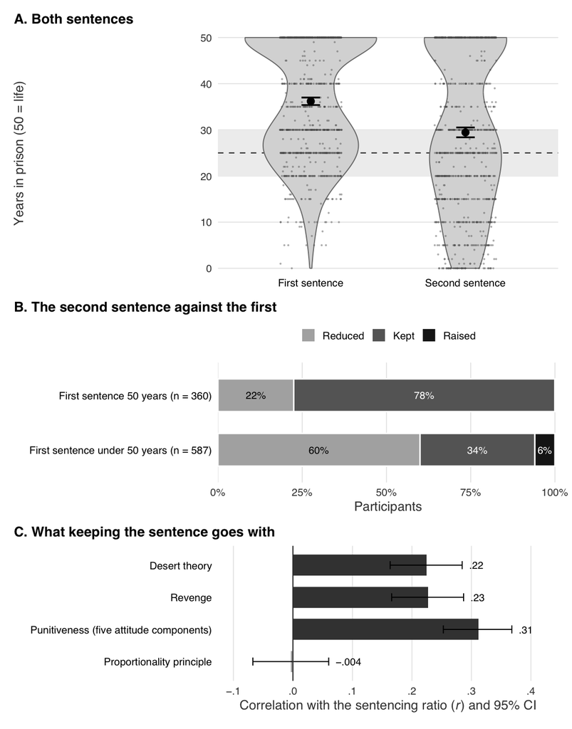

```r
# === FIGURE 13: BOTH SENTENCES (A), WHAT PARTICIPANTS DID (B), AND WHAT
# KEEPING THE SENTENCE GOES WITH (C) ===
# WHAT THIS CHUNK DOES: A, the two sentences as violins; B, the share who
# reduced, kept or raised the sentence, by whether the first was 50 years; C,
# the sentencing ratio's correlation with desert theory, revenge, punitiveness
# (the five attitude components) and the principle. Every plotted number is
# checked against 01's exports (GUARDS below).
# PREREG: A and B are descriptive; C's rows are NOT REGISTERED as scored.
# CONSUMES: s2, s2p (sections 4.0 and 8); read_s2(), same(), mean_ci(),
#           cor_ci2(), violin_sentences(), bars_r().
sc <- read_s2("P2_sentence_change")
same(mean(s2$Sentence2), sc$M1, "mean second sentence"); same(mean(s2$Sentence1), sc$M2, "mean first sentence")
SENT <- c("First sentence", "Second sentence")
f13a_long <- rbind(data.frame(group = SENT[1], years = s2$Sentence1),
                   data.frame(group = SENT[2], years = s2$Sentence2))
f13a_long$group <- factor(f13a_long$group, levels = SENT)
f13a_stats <- rbind(cbind(group = SENT[1], mean_ci(s2$Sentence1)),
                    cbind(group = SENT[2], mean_ci(s2$Sentence2)))
f13a_stats$group <- factor(f13a_stats$group, levels = SENT)
f13a <- violin_sentences(f13a_long, f13a_stats) + labs(title = "A. Both sentences")
# B: reduced / kept / raised, by whether the first sentence was the maximum.
ok <- s2$Sentence1 > 0
dirn <- ifelse(s2$Sentence2 < s2$Sentence1, "Reduced",
        ifelse(s2$Sentence2 == s2$Sentence1, "Kept", "Raised"))[ok]
GRP <- c("First sentence 50 years (n = 360)", "First sentence under 50 years (n = 587)")
grp <- ifelse(s2$Sentence1[ok] == 50, GRP[1], GRP[2])
tab <- table(factor(grp, levels = GRP), factor(dirn, levels = c("Reduced", "Kept", "Raised")))
cells <- read_s2("sentencing_ratio_direction_cells"); ce <- read_s2("P2_sentence_ceiling")
same(colSums(tab), cells$n, "reduced / kept / raised counts")
same(tab[1, "Kept"], ce$k[1], "kept at 50"); same(tab[2, ], ce$k[2:4], "below 50")
stopifnot(rowSums(tab)[1] == 360, rowSums(tab)[2] == 587)
b_long <- as.data.frame(tab); names(b_long) <- c("group", "choice", "n")
b_long$pct <- 100 * b_long$n / ave(b_long$n, b_long$group, FUN = sum)
b_long$group <- factor(b_long$group, levels = rev(GRP))
f13b <- ggplot(b_long, aes(x = pct, y = group, fill = choice)) +
  geom_col(width = 0.6, colour = "white", linewidth = 0.5,
           position = position_stack(reverse = TRUE)) +
  geom_text(data = b_long[b_long$pct >= 4, ],
            aes(label = sprintf("%.0f%%", pct), group = choice, colour = choice != "Reduced"),
            position = position_stack(vjust = 0.5, reverse = TRUE), size = 2.6,
            show.legend = FALSE) +
  scale_colour_manual(values = c(`TRUE` = "white", `FALSE` = INK), guide = "none") +
  scale_fill_manual(values = c(Reduced = "#b0b0b0", Kept = "#666666", Raised = "#1a1a1a")) +
  scale_x_continuous(labels = function(x) paste0(x, "%"), expand = expansion(mult = c(0, 0.01))) +
  labs(x = "Participants", y = NULL, title = "B. The second sentence against the first") +
  theme_hbar()
# C: the sentencing ratio with desert theory, revenge (four items, as
# registered), punitiveness and the principle, from s2p. Punitiveness here is
# the five attitude components, each standardized (punit_parts5z), because the
# ratio is built from the sentences and the six-component score contains the
# first sentence. Each r and its interval are checked against PAPER_ratio_cors,
# and revenge and punitiveness also against the paper's continuous analysis of
# the ratio (PAPER_ratio_continuous; its revenge row is 9.10's registered one),
# whose standardized slope equals r. NOT REGISTERED as scored (desert theory,
# the five components).
MEAS13 <- c(desert_theory = "Desert theory", revenge = "Revenge",
            punit_parts5z = "Punitiveness (five attitude components)",
            proportionality_principle = "Proportionality principle")
MEAS13_EXPORT <- c(desert_theory = "Desert theory", revenge = "Revenge",
                   punit_parts5z = "Punitiveness (five attitude components)",
                   proportionality_principle = "Proportionality principle")
rat <- do.call(rbind, lapply(names(MEAS13), function(v)
  cbind(measure = MEAS13[[v]], cor_ci2(s2p$sentence_ratio, s2p[[v]]))))
prc <- read_s2("PAPER_ratio_cors"); pcc <- read_s2("PAPER_ratio_continuous")
for (i in seq_along(MEAS13)) {
  e <- prc[prc$y == MEAS13_EXPORT[[i]], ]
  stopifnot(nrow(e) == 1)
  same(c(rat$r[i], rat$lower[i], rat$upper[i]), c(e$r, e$ci_lower, e$ci_upper),
       paste("ratio x", MEAS13[[i]]))
}
# GUARD: the continuous analysis has exactly one punitiveness row, the five
# components (01 guards that no six-component row reads the ratio).
stopifnot(sum(pcc$outcome == "Revenge") == 1, sum(grepl("^Punitiveness", pcc$outcome)) == 1,
          pcc$outcome[grepl("^Punitiveness", pcc$outcome)] == MEAS13_EXPORT[["punit_parts5z"]])
same(rat$r[2], pcc$beta[pcc$outcome == "Revenge"], "ratio x revenge (slope)", tol = 1e-6)
same(rat$r[3], pcc$beta[grepl("^Punitiveness", pcc$outcome)], "ratio x punitiveness (slope)", tol = 1e-6)
rat$measure <- factor(rat$measure, levels = rev(unname(MEAS13)))
rat$shade <- ifelse(rat$measure == "Proportionality principle", "light", "dark")
f13c <- bars_r(rat, "measure", "shade", fills = c(dark = S2_FILL, light = S1_FILL),
               xlim = c(-0.1, 0.42), xbreaks = seq(-0.1, 0.4, 0.1),
               xlab = expression(paste("Correlation with the sentencing ratio (", italic(r), ") and 95% CI"))) +
  theme(legend.position = "none") + labs(title = "C. What keeping the sentence goes with")
fig13 <- f13a / f13b / f13c + plot_layout(heights = c(1.6, 0.8, 0.9))
save_fig(fig13, "fig13_study2_second_sentence", 7.4)
fig13
```

# 9. Study 2’s own figures (Results, Part 3)

These three figures show Study 2 alone, for Part 3 of its Results (“The people who rank retribution first”). They use the grayscale style of the figures above and the same kind of checks. Where a plotted number is rebuilt from the scored data, it is compared with the value `01_main_analysis.Rmd` exported, and the knit stops if any disagrees. Figure 14B’s intervals for the two means have no exported counterpart and are computed here, and Figure 15’s intervals and its second comparison group’s means are read from the exports.

```r
# === INPUTS FOR THE PART 3 FIGURES ===
# WHAT THIS CHUNK DOES: confirms that the exports these figures read exist, and
# fixes the primary grouping from the scored data.
#
# The P3_ files are written by section 9.17 of 01_main_analysis.Rmd. If any is
# missing, 01 has not been knitted since that section was added; knit it first.
P3_NEEDED <- c("P3_grouping_agreement", "P3_sentence_direction_by_ranking",
               "P3_H12_everyone_else", "H12_retributivist_endorsement",
               "retributivist_measure_contrasts", "contrasts_ranking",
               "contrasts_vs_deter_incap")
P3_MISSING <- P3_NEEDED[!file.exists(file.path(S2_TABLES, paste0(P3_NEEDED, ".csv")))]
if (length(P3_MISSING)) stop("Knit 01_main_analysis.Rmd first (the P3_ files come from ",
                             "section 9.17, the others from 5.5, 9.2, 9.3 and 9.12b). ",
                             "Missing: ", paste(P3_MISSING, collapse = ", "))
# The primary grouping exactly as 01 froze it in the scored data: the 371
# participants who ranked "Criminals deserve to be punished" first, against the
# other 577.
RET <- s2$grp_rank == "Retributivist"
stopifnot(!anyNA(RET), sum(RET) == 371, sum(!RET) == 577)
RANK_LAB <- c("Ranked retribution first\n(n = 371)", "Ranked another goal first\n(n = 577)")
```

## Figure 14: how far the groupings agree

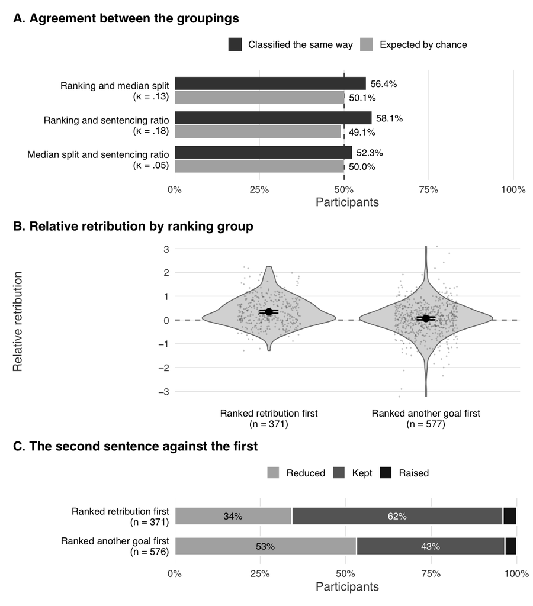

```r
# === FIGURE 14: AGREEMENT BETWEEN THE GROUPINGS (A), RELATIVE RETRIBUTION BY
# RANKING GROUP (B), AND WHAT EACH RANKING GROUP DID WITH THE SENTENCE (C) ===
# A: for each pair of the three groupings that classify (nearly) the whole
# sample (the ratio has no value for one participant), the
# share of participants the two place on the same side, beside the share
# expected by chance given how many each places on its retributive side. Both
# are rebuilt from the grouping factors 01 froze in the scored data and checked
# against P3_grouping_agreement, together with kappa, which the panel prints
# under each pair's name. (The thirds are left out of the panel: they classify
# only two thirds of the sample. Table 14 gives their agreement.)
side <- data.frame(ranking = as.integer(s2$grp_rank == "Retributivist"),
                   median  = as.integer(s2$grp_med == "High rel. retribution"),
                   ratio   = as.integer(s2$grp_ratio == "High sentencing ratio"))
agr <- read_s2("P3_grouping_agreement")
# The export's first three rows are these three pairs, in this order.
stopifnot(grepl("^Ranking", agr$first[1]), grepl("^Median", agr$second[1]),
          grepl("^Ranking", agr$first[2]), grepl("^Sentencing", agr$second[2]),
          grepl("^Median", agr$first[3]), grepl("^Sentencing", agr$second[3]))
PAIRS <- list(c("ranking", "median", "Ranking and median split"),
              c("ranking", "ratio",  "Ranking and sentencing ratio"),
              c("median",  "ratio",  "Median split and sentencing ratio"))
f14a_df <- do.call(rbind, lapply(seq_along(PAIRS), function(i) {
  pr <- PAIRS[[i]]
  ok <- !is.na(side[[pr[1]]]) & !is.na(side[[pr[2]]])
  x <- side[[pr[1]]][ok]; y <- side[[pr[2]]][ok]
  po <- mean(x == y)
  pe <- mean(x) * mean(y) + (1 - mean(x)) * (1 - mean(y))
  kap <- (po - pe) / (1 - pe)
  same(po, agr$agreement[i], paste("agreement,", pr[3]))
  same(pe, agr$chance_agreement[i], paste("chance agreement,", pr[3]))
  same(kap, agr$kappa[i], paste("kappa,", pr[3]))
  data.frame(pair = sprintf("%s\n(κ = %s)", pr[3], fmt_r(kap)),
             kind = c("Classified the same way", "Expected by chance"),
             pct = 100 * c(po, pe))
}))
f14a_df$pair <- factor(f14a_df$pair, levels = rev(unique(f14a_df$pair)))
# position_dodge() puts the first level lowest in each row, so the levels are
# reversed to put the observed bar on top.
f14a_df$kind <- factor(f14a_df$kind, levels = c("Expected by chance", "Classified the same way"))
# The 50% line is drawn first, under the bars and labels, and each label sits
# on a white ground (group = kind keeps each label with its own bar).
f14a <- ggplot(f14a_df, aes(x = pct, y = pair, fill = kind)) +
  geom_vline(xintercept = 50, linetype = "dashed", colour = INK2, linewidth = 0.4) +
  geom_col(width = 0.75, position = position_dodge(width = 0.8)) +
  # pmax() starts every label past the 50% line, so none touches it.
  geom_label(aes(x = pmax(pct, 50) + 1.2, label = sprintf("%.1f%%", pct), group = kind),
             hjust = 0, size = 2.6, colour = INK, fill = "white", linewidth = 0,
             label.padding = unit(0.06, "lines"), position = position_dodge(width = 0.8)) +
  scale_fill_manual(values = c(`Classified the same way` = S2_FILL,
                               `Expected by chance` = S1_FILL),
                    breaks = c("Classified the same way", "Expected by chance")) +
  scale_x_continuous(limits = c(0, 100), breaks = seq(0, 100, 25),
                     labels = function(x) paste0(x, "%"), expand = expansion(mult = c(0, 0.02))) +
  labs(x = "Participants", y = NULL, title = "A. Agreement between the groupings") +
  theme_hbar()

# B: relative retribution by ranking group. Relative retribution is the
# retribution mean minus the mean of the other three goals, so 0 (the dashed
# line) means retribution rated level with the average of the others. The two
# means are checked against retributivist_measure_contrasts; the 95% intervals
# are t intervals computed here (that export has no interval for a mean).
mc <- read_s2("retributivist_measure_contrasts")
mc_rel <- mc[mc$outcome == "Relative retribution", ]
same(mean(s2$retribution_rel[RET]), mc_rel$M1, "relative retribution, retributivists")
same(mean(s2$retribution_rel[!RET]), mc_rel$M2, "relative retribution, others")
f14b_long <- data.frame(group = ifelse(RET, RANK_LAB[1], RANK_LAB[2]),
                        score = s2$retribution_rel)
f14b_long$group <- factor(f14b_long$group, levels = RANK_LAB)
f14b_stats <- rbind(cbind(group = RANK_LAB[1], mean_ci(s2$retribution_rel[RET])),
                    cbind(group = RANK_LAB[2], mean_ci(s2$retribution_rel[!RET])))
f14b_stats$group <- factor(f14b_stats$group, levels = RANK_LAB)
f14b <- ggplot(f14b_long, aes(x = group, y = score)) +
  geom_hline(yintercept = 0, linetype = "dashed", colour = INK2, linewidth = 0.4) +
  geom_violin(fill = VIOLIN, colour = "#7a7a7a", linewidth = 0.35, width = 0.85,
              adjust = 1.2, trim = TRUE) +
  geom_point(position = position_jitter(width = 0.2, height = 0, seed = 1),
             size = 0.6, alpha = 0.35, colour = POINTS, stroke = 0) +
  geom_errorbar(data = f14b_stats, aes(x = group, ymin = lower, ymax = upper),
                inherit.aes = FALSE, width = 0.12, linewidth = 0.6, colour = INK) +
  geom_point(data = f14b_stats, aes(x = group, y = mean), inherit.aes = FALSE,
             size = 2.2, colour = INK) +
  scale_y_continuous(breaks = -3:3, labels = function(x) sub("^-", "−", x)) +
  labs(x = NULL, y = "Relative retribution",
       title = "B. Relative retribution by ranking group") +
  theme_vbar()

# C: reduced, kept, or raised the second sentence, by ranking group, for the 947
# participants with a sentencing ratio. Counts are checked against
# P3_sentence_direction_by_ranking.
okr <- !is.na(s2$sentence_ratio)
dir14 <- ifelse(s2$sentence_ratio < 1, "Reduced",
                ifelse(s2$sentence_ratio == 1, "Kept", "Raised"))[okr]
grp14 <- ifelse(RET[okr], RANK_LAB[1], RANK_LAB[2])
tab14 <- table(factor(grp14, levels = RANK_LAB),
               factor(dir14, levels = c("Reduced", "Kept", "Raised")))
pd <- read_s2("P3_sentence_direction_by_ranking")
stopifnot(pd$group[1] == "Retributivist", pd$group[2] == "Other")
same(tab14[1, ], unlist(pd[1, c("reduced", "kept", "raised")]), "directions, retributivists")
same(tab14[2, ], unlist(pd[2, c("reduced", "kept", "raised")]), "directions, others")
# Panel C rests on the 947 participants with a ratio, so its row labels carry
# the group sizes of that subset (371 and 576), not of the whole sample.
C_LAB <- sprintf(c("Ranked retribution first\n(n = %d)", "Ranked another goal first\n(n = %d)"),
                 as.integer(rowSums(tab14)))
c_long <- as.data.frame(tab14); names(c_long) <- c("group", "choice", "n")
c_long$pct <- 100 * c_long$n / ave(c_long$n, c_long$group, FUN = sum)
c_long$group <- factor(C_LAB[match(as.character(c_long$group), RANK_LAB)], levels = rev(C_LAB))
f14c <- ggplot(c_long, aes(x = pct, y = group, fill = choice)) +
  geom_col(width = 0.6, colour = "white", linewidth = 0.5,
           position = position_stack(reverse = TRUE)) +
  # Segments narrower than 6% are left unlabelled; the label would not fit.
  geom_text(data = c_long[c_long$pct >= 6, ],
            aes(label = sprintf("%.0f%%", pct), group = choice,
                colour = choice != "Reduced"),
            position = position_stack(vjust = 0.5, reverse = TRUE), size = 2.6,
            show.legend = FALSE) +
  scale_colour_manual(values = c(`TRUE` = "white", `FALSE` = INK), guide = "none") +
  scale_fill_manual(values = c(Reduced = "#b0b0b0", Kept = "#666666", Raised = "#1a1a1a")) +
  scale_x_continuous(labels = function(x) paste0(x, "%"), expand = expansion(mult = c(0, 0.01))) +
  labs(x = "Participants", y = NULL, title = "C. The second sentence against the first") +
  theme_hbar()
fig14 <- f14a / f14b / f14c + plot_layout(heights = c(1, 1.5, 0.6))
save_fig(fig14, "fig14_study2_groupings", 6.6)
fig14
```

## Figure 15: retributivists against the participants who ranked deterrence or incapacitation first

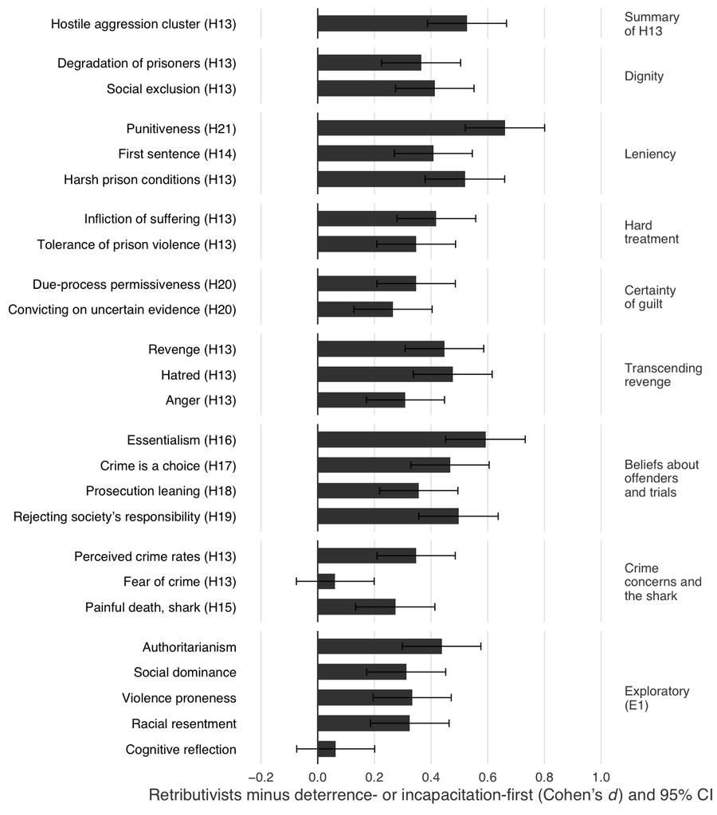

```r
# === FIGURE 15: COHEN'S d FOR EVERY CONTRAST, RETRIBUTIVISTS AGAINST THE
# PARTICIPANTS WHO RANKED DETERRENCE OR INCAPACITATION FIRST (NOT REGISTERED),
# GROUPED AS IN TABLE S19 ===
# CONSUMES: s2p with punit_parts6 (study2_paper_scorings); RET (Part 3 inputs);
#           read_s2(), same().
# The paper's main text reports this comparison, which leaves out the 124 who
# ranked rehabilitation first; the registered comparison with all 577 other
# participants is in Table S19. The d values and intervals are read from 9.19's
# export (PAPER_contrasts_vs_deter_incap, identical to 9.12b's run). Two checks
# tie them to the data: each retributivist mean is rebuilt from the scored
# data, and each d is rebuilt from its own means and SDs (the difference in
# means divided by the square root of the mean of the two variances), the
# standardizer 01 uses. The comparison group's means cannot be rebuilt here,
# because the scored data do not carry the goal each participant ranked first.
# Punitiveness is the six components (H21, once; NOT REGISTERED as scored),
# cognitive reflection the two-item score, and revenge and the cluster are as
# registered; the five-component punitiveness row, the three-item reflection
# score and the shark decision are not plotted, and Table S19 reports them.
# s2p carries the six-component score under the variable name the export uses
# (punit_parts6), so the retributivist-mean check below reads it directly.
cq15 <- read_s2("PAPER_contrasts_vs_deter_incap")
stopifnot(all(cq15$n1 %in% c(369, 371)), all(cq15$n2 %in% c(452, 453)))
ROWS15 <- data.frame(
  outcome = c("Hostile-aggression cluster (z)",
              "Degradation", "Social exclusion",
              "Punitiveness (six components)",
              "Sentence 1 (z within vignette)", "Harsh prison conditions",
              "Infliction of suffering", "Tolerance of prison violence",
              "Due-process permissiveness", "Convicting on uncertain evidence",
              "Revenge", "Hatred", "Anger",
              "Essentialism about criminals", "Crime is a choice",
              "Leaning toward the prosecution", "Rejecting society's responsibility",
              "Perceived crime rates", "Fear of crime", "Shark: how painful the death should be",
              "Right-Wing Authoritarianism", "Social Dominance Orientation",
              "Violence proneness", "Racial resentment",
              "Cognitive reflection (0-2, lily pad dropped)"),
  label = c("Hostile aggression cluster (H13)",
            "Degradation of prisoners (H13)", "Social exclusion (H13)",
            "Punitiveness (H21)",
            "First sentence (H14)", "Harsh prison conditions (H13)",
            "Infliction of suffering (H13)", "Tolerance of prison violence (H13)",
            "Due-process permissiveness (H20)", "Convicting on uncertain evidence (H20)",
            "Revenge (H13)", "Hatred (H13)", "Anger (H13)",
            "Essentialism (H16)", "Crime is a choice (H17)",
            "Prosecution leaning (H18)", "Rejecting society’s responsibility (H19)",
            "Perceived crime rates (H13)", "Fear of crime (H13)", "Painful death, shark (H15)",
            "Authoritarianism", "Social dominance",
            "Violence proneness", "Racial resentment", "Cognitive reflection"),
  # The same blocks, in the same order, as Table 15's subheadings, less its
  # shark-decision block (an odds ratio, not a d).
  block = rep(c("Summary\nof H13", "Dignity", "Leniency", "Hard\ntreatment", "Certainty\nof guilt",
                "Transcending\nrevenge", "Beliefs about\noffenders\nand trials",
                "Crime\nconcerns and\nthe shark", "Exploratory\n(E1)"),
              times = c(1, 2, 3, 2, 2, 3, 4, 3, 5)),
  stringsAsFactors = FALSE)
stopifnot(all(ROWS15$outcome %in% cq15$outcome), nrow(ROWS15) == 25)
d_from <- function(r) (r$M1 - r$M2) / sqrt((r$SD1^2 + r$SD2^2) / 2)
for (o in ROWS15$outcome) {
  b <- cq15[cq15$outcome == o, ]
  y <- s2p[[b$variable]]
  same(mean(y[RET], na.rm = TRUE), b$M1, paste("retributivist mean,", o))
  same(d_from(b), b$d, paste("d against deterrence or incapacitation first,", o), tol = 1e-6)
}
f15_df <- do.call(rbind, lapply(seq_len(nrow(ROWS15)), function(i) {
  b <- cq15[cq15$outcome == ROWS15$outcome[i], ]
  data.frame(label = ROWS15$label[i], block = ROWS15$block[i],
             d = b$d, lower = b$d_lower, upper = b$d_upper)
}))
f15_df$label <- factor(f15_df$label, levels = rev(ROWS15$label))
f15_df$block <- factor(f15_df$block, levels = unique(ROWS15$block))
fig15 <- ggplot(f15_df, aes(x = d, y = label)) +
  geom_col(width = 0.62, fill = S2_FILL) +
  geom_errorbar(aes(xmin = lower, xmax = upper), width = 0.3, orientation = "y",
                linewidth = 0.3, colour = INK) +
  geom_vline(xintercept = 0, colour = INK2, linewidth = 0.4) +
  facet_grid(block ~ ., scales = "free_y", space = "free_y") +
  scale_x_continuous(breaks = seq(-0.2, 1, 0.2),
                     labels = function(x) sub("^-", "−", sprintf("%.1f", x))) +
  coord_cartesian(xlim = c(-0.2, 1.0)) +
  labs(x = expression(paste("Retributivists minus deterrence- or incapacitation-first (Cohen’s ",
                            italic(d), ") and 95% CI")), y = NULL) +
  theme_hbar() +
  theme(strip.text.y = element_text(angle = 0, hjust = 0, size = 7.5, colour = INK2),
        panel.spacing.y = unit(0.35, "lines"))
save_fig(fig15, "fig15_study2_retributivist_contrasts", 6.6)
fig15
```

## Figure 16: endorsement of the hostile attitudes

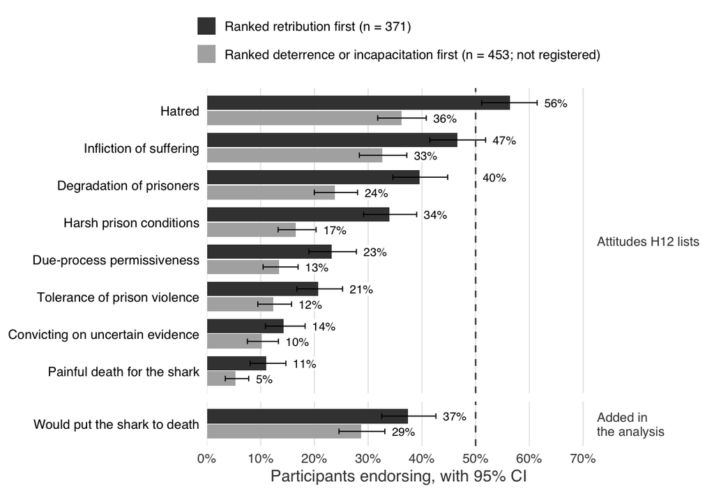

```r
# === FIGURE 16: SHARE ENDORSING EACH HOSTILE ATTITUDE, RETRIBUTIVISTS (H12)
# AND THE PARTICIPANTS WHO RANKED DETERRENCE OR INCAPACITATION FIRST (NOT
# REGISTERED) ===
# Endorsing means a mean above 4, the scale midpoint; the shark decision is the
# share answering yes. The comparison group is the paper's: the 453 who ranked
# deterrence or incapacitation first, leaving out those who ranked
# rehabilitation first. The retributivists' shares and exact (Clopper-Pearson)
# 95% intervals are rebuilt from the scored data and checked against the H12
# export. The comparison group's are read from 01's export
# (PAPER_H12_shares_vs_deter_incap, section 9.19D), because the scored data do
# not record which goal each participant ranked first.
h12x <- read_s2("H12_retributivist_endorsement"); dix <- read_s2("PAPER_H12_shares_vs_deter_incap")
VAR12 <- data.frame(
  var = c("hatred", "suffering", "degradation", "harsh", "dueprocess", "prisonviol",
          "uncertain", "Shark_3", "shark_kill"),
  export = c("Hatred toward offenders", "Infliction of suffering", "Degradation of prisoners",
             "Harsh prison conditions", "Restricting due-process rights",
             "Tolerance of prison violence", "Convicting on substandard evidence",
             "A painful death for the shark", "Putting the shark to death (yes)"),
  label = c("Hatred", "Infliction of suffering", "Degradation of prisoners",
            "Harsh prison conditions", "Due-process permissiveness",
            "Tolerance of prison violence", "Convicting on uncertain evidence",
            "Painful death for the shark", "Would put the shark to death"),
  block = c(rep("Attitudes H12 lists", 8), "Added in\nthe analysis"),
  stringsAsFactors = FALSE)
share_ci <- function(x) {
  k <- sum(x); n <- length(x); bt <- binom.test(k, n)
  data.frame(pct = 100 * k / n, lower = 100 * bt$conf.int[1], upper = 100 * bt$conf.int[2])
}
GRP16 <- c("Ranked retribution first (n = 371)",
           "Ranked deterrence or incapacitation first (n = 453; not registered)")
f16_df <- do.call(rbind, lapply(seq_len(nrow(VAR12)), function(i) {
  v <- VAR12$var[i]
  endorse <- if (v == "shark_kill") s2[[v]] == 1 else s2[[v]] > 4
  stopifnot(!anyNA(endorse))
  a <- share_ci(endorse[RET])
  ea <- h12x[h12x$attitude == VAR12$export[i], ]; eb <- dix[dix$attitude == VAR12$export[i], ]
  stopifnot(nrow(ea) == 1, nrow(eb) == 1, eb$n == 453)
  same(a$pct / 100, ea$share, paste("retributivist share,", v))
  same(a$lower / 100, ea$share_ci_lower, paste("retributivist lower limit,", v))
  same(a$upper / 100, ea$share_ci_upper, paste("retributivist upper limit,", v))
  b <- data.frame(pct = 100 * eb$share, lower = 100 * eb$share_ci_lower,
                  upper = 100 * eb$share_ci_upper)
  same(eb$share, eb$k_endorsing / eb$n, paste("comparison share is k / n,", v))
  cbind(label = VAR12$label[i], block = VAR12$block[i], group = GRP16, rbind(a, b))
}))
f16_df$label <- factor(f16_df$label, levels = rev(VAR12$label))
f16_df$block <- factor(f16_df$block, levels = unique(VAR12$block))
f16_df$group <- factor(f16_df$group, levels = rev(GRP16))
fig16 <- ggplot(f16_df, aes(x = pct, y = label, fill = group)) +
  geom_col(width = 0.78, position = position_dodge(width = 0.82)) +
  geom_errorbar(aes(xmin = lower, xmax = upper), width = 0.3, orientation = "y",
                linewidth = 0.3, colour = INK, position = position_dodge(width = 0.82)) +
  # The 50% line is drawn before the labels, and each label sits on a white
  # ground.
  geom_vline(xintercept = 50, linetype = "dashed", colour = INK2, linewidth = 0.4) +
  # group = group keeps each label with its own bar: the fixed white fill
  # replaces the fill mapping, which would otherwise carry the grouping.
  # A label that would start just short of the 50% line is moved past it, so no
  # label sits on the line.
  geom_label(aes(x = ifelse(upper + 1.2 > 45 & upper + 1.2 < 50.5, 51.2, upper + 1.2),
                 label = sprintf("%.0f%%", pct), group = group), hjust = 0, size = 2.4,
             colour = INK, fill = "white", linewidth = 0,
             label.padding = unit(0.06, "lines"), position = position_dodge(width = 0.82)) +
  facet_grid(block ~ ., scales = "free_y", space = "free_y") +
  scale_fill_manual(values = setNames(c(S2_FILL, S1_FILL), GRP16), breaks = GRP16) +
  scale_x_continuous(limits = c(0, 70), breaks = seq(0, 70, 10),
                     labels = function(x) paste0(x, "%"), expand = expansion(mult = c(0, 0.02))) +
  guides(fill = guide_legend(ncol = 1)) +
  labs(x = "Participants endorsing, with 95% CI", y = NULL) +
  theme_hbar() +
  theme(strip.text.y = element_text(angle = 0, hjust = 0, size = 7.5, colour = INK2))
save_fig(fig16, "fig16_study2_endorsement", 4.0)
fig16
```

# 10. What was written

```r
# === 10. WHAT THIS KNIT WROTE ===
# WHAT THIS CHUNK DOES: lists the outputs, so the knitted report records what
# it produced.
# GUARD: the paper figures this knit wrote are exactly the seventeen the paper
# uses (fig1, fig2, fig4 to fig18; fig3 is no longer a paper figure), each once,
# and each is now in the manuscript's and the Overleaf figure folders.
PAPER_FIGS_EXPECTED <- c("fig1_study1_sentences", "fig2_study1_cluster_matrix",
                         "fig4_study1_construct_matrix", "fig5_sentences_both_studies",
                         "fig6_correlates_both_studies",
                         "fig7_hostility_advantage_both_studies", "fig17_study2_sentences",
                         "fig18_study2_correlates", "fig8_study2_goals",
                         "fig9_study2_proportionality", "fig10_study2_desert_direction",
                         "fig11_study2_goals_limits", "fig12_study2_desert_revenge",
                         "fig13_study2_second_sentence", "fig14_study2_groupings",
                         "fig15_study2_retributivist_contrasts", "fig16_study2_endorsement")
stopifnot(setequal(PAPER_FIGS, PAPER_FIGS_EXPECTED), !anyDuplicated(PAPER_FIGS),
          all(file.exists(file.path(DOCS_PAPER, paste0(PAPER_FIGS, ".png")))),
          all(file.exists(file.path(OVERLEAF_FIG, paste0(PAPER_FIGS, ".pdf")))))
cat("Paper figures written this knit (PNG to figures/paper, PDF to Overleaf):\n")
```

```
## Paper figures written this knit (PNG to figures/paper, PDF to Overleaf):
```

```r
print(PAPER_FIGS)
```

```
##  [1] "fig1_study1_sentences"
##  [2] "fig2_study1_cluster_matrix"
##  [3] "fig4_study1_construct_matrix"
##  [4] "fig5_sentences_both_studies"
##  [5] "fig6_correlates_both_studies"
##  [6] "fig7_hostility_advantage_both_studies"
##  [7] "fig17_study2_sentences"
##  [8] "fig18_study2_correlates"
##  [9] "fig8_study2_goals"
## [10] "fig9_study2_proportionality"
## [11] "fig10_study2_desert_direction"
## [12] "fig11_study2_goals_limits"
## [13] "fig12_study2_desert_revenge"
## [14] "fig13_study2_second_sentence"
## [15] "fig14_study2_groupings"
## [16] "fig15_study2_retributivist_contrasts"
## [17] "fig16_study2_endorsement"
```

```r
# A copy of fig3 left in the manuscript's folders by an earlier knit is not
# this knit's output; it is named here so it is not mistaken for a current one.
stale <- c(file.path(DOCS_PAPER, "fig3_study1_sensitivity.png"),
           file.path(OVERLEAF_FIG, "fig3_study1_sensitivity.pdf"))
if (any(file.exists(stale)))
  cat("Left from an earlier knit, NOT a current paper figure:",
      paste(basename(stale[file.exists(stale)]), collapse = ", "), "\n")
```

```
## Left from an earlier knit, NOT a current paper figure: fig3_study1_sensitivity.png, fig3_study1_sensitivity.pdf
```

```r
print(list.files(OUT_FIGURES))
```

```
##  [1] "fig1_study1_sentences.pdf"
##  [2] "fig1_study1_sentences.png"
##  [3] "fig10_study2_desert_direction.pdf"
##  [4] "fig10_study2_desert_direction.png"
##  [5] "fig11_study2_goals_limits.pdf"
##  [6] "fig11_study2_goals_limits.png"
##  [7] "fig12_study2_desert_revenge.pdf"
##  [8] "fig12_study2_desert_revenge.png"
##  [9] "fig13_study2_second_sentence.pdf"
## [10] "fig13_study2_second_sentence.png"
## [11] "fig14_study2_groupings.pdf"
## [12] "fig14_study2_groupings.png"
## [13] "fig15_study2_retributivist_contrasts.pdf"
## [14] "fig15_study2_retributivist_contrasts.png"
## [15] "fig16_study2_endorsement.pdf"
```

[output cut: 21 more lines]

```r
print(list.files(DOCS_PAPER))
```

```
##  [1] "fig1_study1_sentences.png"
##  [2] "fig10_study2_desert_direction.png"
##  [3] "fig11_study2_goals_limits.png"
##  [4] "fig12_study2_desert_revenge.png"
##  [5] "fig13_study2_second_sentence.png"
##  [6] "fig14_study2_groupings.png"
##  [7] "fig15_study2_retributivist_contrasts.png"
##  [8] "fig16_study2_endorsement.png"
##  [9] "fig17_study2_sentences.png"
## [10] "fig18_study2_correlates.png"
## [11] "fig2_study1_cluster_matrix.png"
## [12] "fig3_study1_sensitivity.png"
## [13] "fig4_study1_construct_matrix.png"
## [14] "fig5_sentences_both_studies.png"
## [15] "fig6_correlates_both_studies.png"
## [16] "fig7_hostility_advantage_both_studies.png"
## [17] "fig8_study2_goals.png"
## [18] "fig9_study2_proportionality.png"
```

```r
print(list.files(OVERLEAF_FIG))
```

```
##  [1] "fig1_study1_sentences.pdf"
##  [2] "fig10_study2_desert_direction.pdf"
##  [3] "fig11_study2_goals_limits.pdf"
##  [4] "fig12_study2_desert_revenge.pdf"
##  [5] "fig13_study2_second_sentence.pdf"
##  [6] "fig14_study2_groupings.pdf"
##  [7] "fig15_study2_retributivist_contrasts.pdf"
##  [8] "fig16_study2_endorsement.pdf"
##  [9] "fig17_study2_sentences.pdf"
## [10] "fig18_study2_correlates.pdf"
## [11] "fig2_study1_cluster_matrix.jpg"
## [12] "fig2_study1_cluster_matrix.pdf"
## [13] "fig3_study1_sensitivity.pdf"
## [14] "fig4_study1_construct_matrix.jpg"
## [15] "fig4_study1_construct_matrix.pdf"
## [16] "fig5_sentences_both_studies.pdf"
## [17] "fig6_correlates_both_studies.pdf"
## [18] "fig7_hostility_advantage_both_studies.pdf"
## [19] "fig8_study2_goals.pdf"
## [20] "fig9_study2_proportionality.pdf"
```

```r
print(list.files(OUT_TABLES, pattern = "^two_study_"))
```

```
## [1] "two_study_agreement.csv"           "two_study_cluster_tests.csv"
## [3] "two_study_clusters.csv"            "two_study_constructs.csv"
## [5] "two_study_hostility_advantage.csv" "two_study_s1_descriptives.csv"
## [7] "two_study_sentences.csv"
```

```r
print(list.files(OUT_TABLES, pattern = "^S1P_"))
```

```
##  [1] "S1P_H2_steiger.csv"          "S1P_levels.csv"
##  [3] "S1P_parsimony_check.csv"     "S1P_punitiveness_scores.csv"
##  [5] "S1P_table1_correlations.csv" "S1P_tableS1_strictness.csv"
##  [7] "S1P_tableS2_moderation.csv"  "S1P_tableS3_moderation.csv"
##  [9] "S1P_vignette_stability.csv"  "S1P_vignette_summary.csv"
```